# Joint Coho Technical Committee Periodic Report

Author

PSC Joint Coho Technical Committee

Published

February 11, 2025

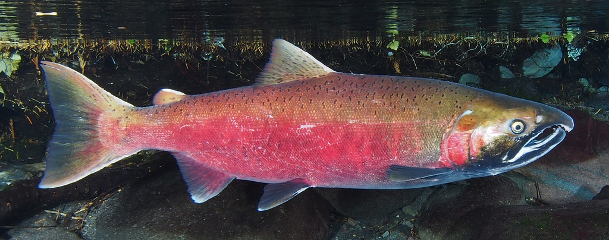

# 1 Introduction

In response to a decline in natural Coho Salmon (*Onchorynchus kisutch*) abundance, the Pacific Salmon Commission (PSC) established a Southern Coho abundance-based management regime (CoABM) in 1999 (Pacific Salmon Commission 1999). This Southern Coho Management Plan (SCMP, also referred to as ABM, or ‘abundance based management’) aimed to conserve Coho Salmon Management Units (MUs) of naturally-spawning Coho Salmon in southern British Columbia and Washington/Oregon based on abundance status and escapement goals. The set out to constrain exploitation rates (; defined as total fishing mortality divided by total fishing mortality plus escapement) below maximum levels (caps) on selected in order to achieve long-term Maximum Sustainable Harvests (MSHs). These constraints are implemented by specifying caps for the individual dependent on annual abundance status. During their respective preseason planning processes, the Parties use management reference points to classify the status of each as low, moderate, or abundant. The parties then exchange these status determinations as a key input in the development of pre-season plans.

When a new Coho Management Plan was agreed upon in 2008 (implemented 2009 through 2018; (Pacific Salmon Commission 2009)) and the latest agreement finalized (applies to the period from catch years 2019 through 2028; (Pacific Salmon Commission 2022)), modifications were made to the list of specified and to the manner in which caps are established. This periodic report presents information for the identified in the most current Pacific Salmon Treaty’s (PST) (Chapter 5 of Annex IV in the current ). In the 2008 abundance-based management regimes were established to constrain () on 13 of naturally-spawning Coho Salmon originating in rivers along the Washington/British Columbia (BC) border. Beggining in 2019, the most recent Management Plan (Pacific Salmon Commission 2022) combined two of the Canadian , the Georgia Strait Vancouver Island and the Georgia Strait Mainland into the Strait of Georgia . The 12 in the current are listed below (Table 1.1).

Table 1.1: Management Units within the current Pacific Salmon Treaty Southern Coho Management Plan.

| Southern BC | US Inside | US Outside |
| --- | --- | --- |
| Interior Fraser | Skagit | Quillayute |
| Lower Fraser | Stillaguamish | Hoh |
| Strait of Georgia | Snohomish | Queets |
|  | Hood Canal | Grays Harbor |
|  | US Strait JDF |  |

The objective of the , as described in the Treaty, is to manage salmon directed fisheries impact on Southern Coho stocks by limiting the total fishery exploitation and allow the different to produce long-term , while maintaining the genetic and ecological diversity of the individual populations. In addition, the plan is designed to improve the prospect of sustaining healthy fisheries for both parties over the long-term. The plan is intended to be cost-effective and flexible to available technical capacity and information, while providing a predictable framework for planning fisheries impacts and allowing for objective monitoring, evaluation and modification.

Under the Agreement, the United States and Canada (the “Parties”) are required to establish escapement goals or that achieve , determine for each , and establish for each and status category (low, moderate, and abundant). Until such time as the Parties provide -specific targets, the identified default ceilings for each status category (Table 1.2).

Table 1.2: Range of agreed to total exploitation rates for MU abundance status categories in order to achieve maximum sustainable harvest.

| Status | Total Exploitation Rate |
| --- | --- |
| Low | Up to 20% |
| Moderate | 21% - 40% |
| Abundant | 41% - 65% |

Annual caps are established for each of the based on the level of abundance and health of the natural stocks. These caps are then apportioned between the Parties. Constraints for Canadian fisheries on US are determined by formulas that specify sharing of allowable as well as a composite rule, which together adjust caps according to the number of US MUs that fall within a given category. The composite rule adjusts constraints for Canadian fishery based on the number of US which fall in a given category. For example, if only one Washington coastal or Puget Sound Coho is in low status, Canadian fisheries are constrained to a total on that unit of 12%; if two or more Washington coastal are in low status, the constraint becomes 10%. The most restrictive limit for Canadian fishery impacts on US Coho is 10%.

At this time, constraints for US fisheries on Canadian depend on the status of the Interior Fraser until the biological statuses of the other Canadian have been determined. Under Annex IV Chapter 5 Section 8.c(i), until Canada establishes status determination methods for Canadian MUs other than the Interior Fraser , the Parties shall implement this Chapter to comply with status and associated caps that relate to the Interior Fraser and US only.

## 1.1 Management Unit Overview

The Canadian are comprised of geographical aggregates of naturally spawning Coho conservation units (CUs) within the Interior Fraser River, Lower Fraser River, and Strait of Georgia (Table 1.1). A consists of one or more spawning populations which are genetically distinct from other conspecific spawning populations. The 2019 renewal of the combined the Georgia Basin – East and Georgia Basin – West into a single Strait of Georgia , reducing the number of Canadian in the bilateral management regime to three. Beginning with catch year 2019, the CoTC chose to combine model outputs for these in carrying out its pre-season and post-season evaluations, rather than reconfigure the FRAM framework.

The US Inside consist of naturally spawning populations originating in the Skagit, Stillaguamish, Snohomish, Hood Canal, and the Strait of Juan de Fuca. Coho populations in the US Inside belong to the larger Puget Sound/Strait of Georgia Coho Salmon evolutionarily significant unit (ESU; (Weitkamp et al. 1995)). Only the eastern portion of the Strait of Juan de Fuca is in this ESU. An ESU is a Pacific salmon population or group of populations that is substantially reproductively isolated from other conspecific populations and represents an important component of the evolutionary legacy of the species. The ESU policy (56 FR 58612) for Pacific salmon defines the criteria for identifying a Pacific salmon population as a distinct population segment, which can be listed under the US Endangered Species Act of 1973.

The US Outside consist of naturally-spawning populations from the Quillayute, Hoh, Queets, and Grays Harbor basins. All US Outside , except the Grays Harbor , are part of the Olympic Peninsula ESU. Populations from the western portion of the Strait of Juan de Fuca are also in this ESU. The Grays Harbor is part of the Southwest Washington ESU.

## 1.2 Fishery Overview

Under the CoABM regime, each Party is required to regulate its fisheries so as not to exceed constraints on . Fishery Management Areas for British Columbia (Figure 1.1), Washington (Figure 1.2), and Oregon (Figure 1.3) are shown below.

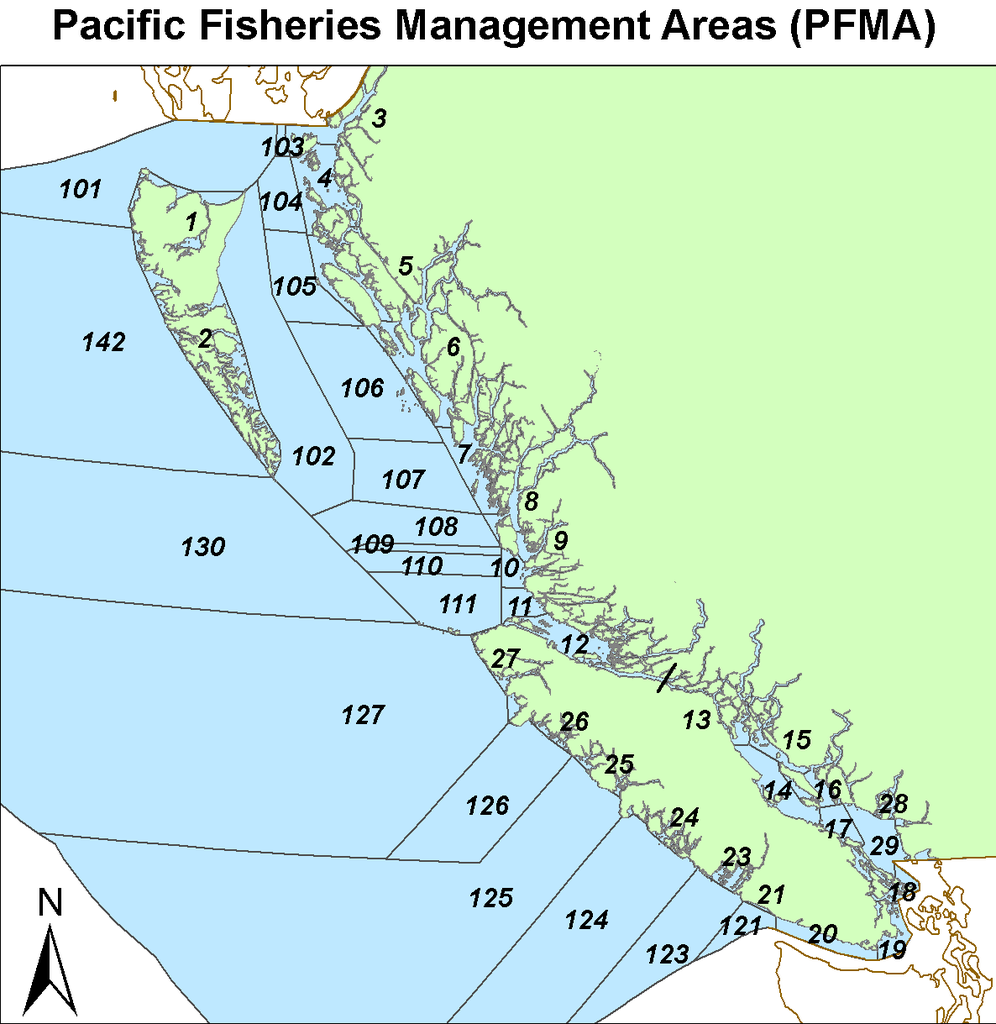

Figure 1.1: Canadian DFO Southern BC Pacific Fisheries Management Areas.

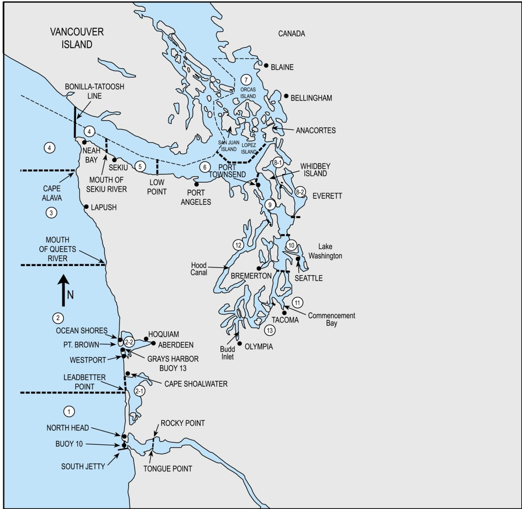

Figure 1.2: Washington Coast and Puget Sound Marine Fishery Areas.

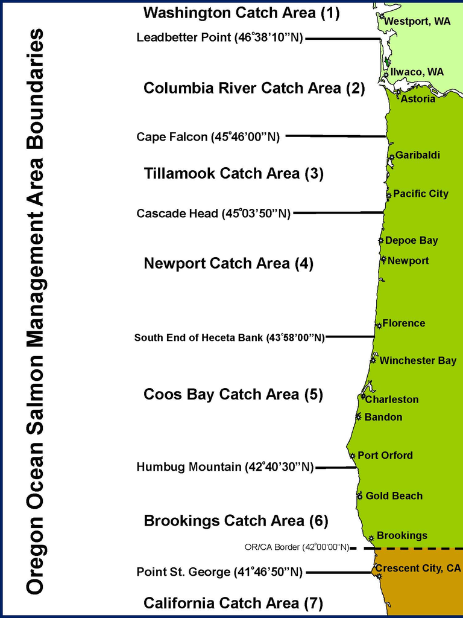

Figure 1.3: Oregon Ocean Salmon Management Areas and Major Port Locations.

### 1.2.1 Canadian Fisheries

**Request for input**

Southern BC Coho Salmon are caught in First Nations, recreational, and commercial troll and net fisheries. Since Coho Salmon rear in areas near the coast they are readily caught in directed fisheries and as bycatch in fisheries targeting other species. As a result, Coho Salmon are harvested in mixed-stock fisheries, creating many challenges for the assessment and management of the species.

Coho Salmon catches on the south coast of BC have declined since the mid-1980s, initially due to declining abundance and more recently because of severe conservation measures in response to the declining abundance. Total fishery in Canada were reduced from a range of 75 to 80% in the mid-1980s to 60% in 1995, 37% in 1997, 5% in 1998, and are currently estimated by Backwards Coho Fisheries Regulation Assessment Model (FRAM) during catch years 2011 through 2021 at less than 10%.

Historically 89% of the commercial Coho Salmon catch on the south coast of BC was taken by the troll sector with the remainder harvested by commercial net fisheries. The West Coast of Vancouver Island (WCVI) troll fishery was the single largest commercial harvester, taking an average of 1.5 million Coho Salmon in the 10-year period before 1997, when major fishing restrictions were imposed. This fishery intercepted stocks from the US, Strait of Georgia, and WCVI. Since 2001, average catch retained in the WCVI troll fishery has been 725 Coho, due primarily to the timing and non-retention restrictions in place for this fishery. Historically, catch in the Strait of Georgia troll fishery, comprised predominantly of Strait of Georgia stocks, was much smaller than the WCVI troll fishery (1986–1995 averaged 150,000 Coho Salmon, annually). The Strait of Georgia troll fishery has not been permitted to retain Coho Salmon since 1995.

Net fisheries in Johnstone Strait, Strait of Juan de Fuca and the Strait of Georgia harvest Coho Salmon incidentally during directed fisheries on Sockeye (*O. nerka*), Pink (*O. gorbuscha*), and Chum (*O. keta*) Salmon. Net fisheries have been curtailed in recent years due to low returns of the target species and concerns for Chinook (*O. tshawytscha*) and Coho Salmon bycatch.

While the First Nations’ harvest of Coho Salmon is small compared with other salmon species, several First Nations harvest Coho Salmon for food, social, and ceremonial purposes. They are caught in hook and line, net, and spear fisheries in or near their local streams. They are also caught incidentally in other First Nations’ salmon fisheries directed on other species, such as Sockeye and Chum Salmon.

Recreational fishing for Coho Salmon in BC tidal waters continues to be important to residents and visitors. Until the recent decline in Coho Salmon abundance and subsequent severe fishing restrictions, 70% of tidal recreational fishing took place within the Strait of Georgia. Since 1995, most Coho Salmon recreational fishery effort and catch has shifted from the Strait of Georgia to the WCVI, in part due to low abundance of Coho Salmon inside Vancouver Island. Overall, the proportion of Coho Salmon harvested by the recreational fishery has increased as commercial harvest has been significantly reduced as a result of the timing and non-retention harvest restrictions, as well as domestic allocation considerations in Canada that were implemented in response to the low abundance of Coho Salmon.

Due to conservation concerns, most notably for the Interior Fraser , Canadian Coho Salmon fisheries have seen unprecedented restrictions since 1997. In 1998 and 1999, no directed fisheries on naturally-spawning stocks of Coho Salmon were permitted; mandatory non-retention and non-possession of incidentally caught Coho Salmon was implemented in all areas, with the exception of some terminal hatchery locations. In the Pacific Region, (i.e., all marine waters of BC), barbless hooks became required for all salmon-directed commercial and recreational hook and line gear in 1998, a regulation that remains in effect. Pacific Region waters were classified as red or yellow zones. In red zones, areas where Thompson River Coho Salmon from the Interior Fraser River were known to be prevalent, fishing was restricted to very limited experimental selective fisheries, as well as some limited First Nations’ fisheries to meet food, social, and ceremonial requirements. Red zones included inshore waters of Victoria to Barkley Sound and offshore waters of Barkley Sound to Quatsino Sound, from June to September. Special management zones (SMZs), areas of mandatory Coho Salmon non-retention with special restrictions, were identified with the intent to avoid Coho Salmon encounters. Fisheries were only permitted in locations and times when Thompson River Coho Salmon could be avoided or released unharmed. These areas were subject to in-season adjustments, including time and area closures for all sectors. Fisheries conducted in these SMZs were monitored to ensure Coho Salmon encounter rates did not become too high, and tissue samples were taken for stock identification. In yellow zones, where endangered stocks were not prevalent, a selective fishing strategy was implemented for all commercial and recreational fisheries [**Jeromy comment: Does this mean in red zones, endangered stocks (under SARA?) are prevalent? This context is not provided.**]. These fisheries were required to release any live Coho Salmon Salmon that were caught during operations. Mandatory logbooks and an onboard observer program were initiated in commercial fisheries. Limited Coho Salmon retention was allowed only for First Nations and recreational fisheries.

Since 2000, fisheries impacting naturally-spawning Coho Salmon from southern BC, Washington State, and Oregon have been managed under the ABM regime. The ABM plan constrains total fishery exploitation on key stock in BC For each , annual limits of fishing mortality are established based on the categorical level of abundance and the health of the naturally-spawning stocks. In Canada, low status of Interior Fraser Coho Salmon has constrained southern BC fisheries for the last decade. The Southern US has been limited to 10% on Coho Salmon originating from the Interior Fraser . Southern BC fisheries, in waters south of Cape Caution where Interior Fraser Coho Salmon are prevalent, have been managed to a maximum 3% total fishing mortality rate on the Interior Fraser Coho Salmon . Non-retention of naturally-spawning Coho Salmon is generally in effect except for First Nations opportunities in specific terminal systems where abundance permits and where retention of by-catch during fisheries for other species is permitted. Release of unmarked Coho Salmon during periods when Interior Fraser Coho Salmon may be caught is required in all Canadian commercial and recreational fisheries.

### 1.2.2 US Fisheries

Current US fisheries are constrained by domestic and conservation objectives. For the Puget Sound , the current of CoABM uses the thresholds and stepped harvest rate goals from the Comprehensive Coho Agreement (Comprehensive Coho Workgroup 1998), developed by Washington State and the Puget Sound tribes, and adopted by the as Fishery Management Plan conservation objectives in November 2009. Actual constraints for Canadian fisheries on US Coho Salmon are determined by formulas that specify sharing of allowable total and a “composite rule”. The composite rule adjusts constraints for Canadian fishery based on the number of US that fall in a given category. For example, if only one Washington coastal Coho Salmon is in low status, Canadian fisheries are constrained to a total on that unit of 12%; if two or more Washington coastal are in low status, the constraint becomes 10%. The most restrictive limit for Canadian fishery impacts on US Coho Salmon is 10%.

Fisheries between Cape Falcon, Oregon and the US/Canada Border are constrained by four factors: (1) management objectives and treaty Indian obligations for individual stock US MUs; (2) treaty Indian/non-Indian and ocean/in-river sharing agreements; (3) stocks listed under the ESA; and (4) requirements of the . The starting point for implementing these constraints is the forecasted January age-3 (JA3) abundance and the modeled ocean distribution of each Coho Salmon stock.

Most Coho-directed recreational fisheries [**Jeromy comment: Freshwater and marine? I think so, for WA, and Columbia River but would be good to add this qualifier in if true. More recently the OR coast freshwater fisheries are all non-selective, hence why I am asking for a bit of a qualifier here if possible.**] have been mark-selective since 1999. Non-Indian commercial troll fisheries have been mostly restricted to mark-selective Coho Salmon retention since 2000. Treaty Indian fisheries are not restricted to mark-selective retention of Coho Salmon.

## 1.3 Bilateral Assessment Tool (FRAM) Overview

Coho Salmon fisheries are evaluated with the Coho Fisheries Regulation Assessment Model [(Coho FRAM)](https://framverse.github.io/fram_doc/calcs_data_coho.html), a bilaterally developed tool that is employed for both pre-season fishery planning and post-season estimation of escapements and [(see: pre- and post-season applications)](https://framverse.github.io/fram_doc/apps_coho.html).

Coho FRAM is an annual mixed-stock accounting model that evaluates a set of stock units within a set of fisheries over time periods within a single fishing year (the calendar year for Coho Salmon) (documentation on FRAM can be found here: https://framverse.github.io/fram_doc/). It can be used to estimate catch and escapement based on forecast abundance and planned fisheries (‘forward’), or it can be used to reconstruct ocean abundance from observed escapements and fisheries (‘backward’).

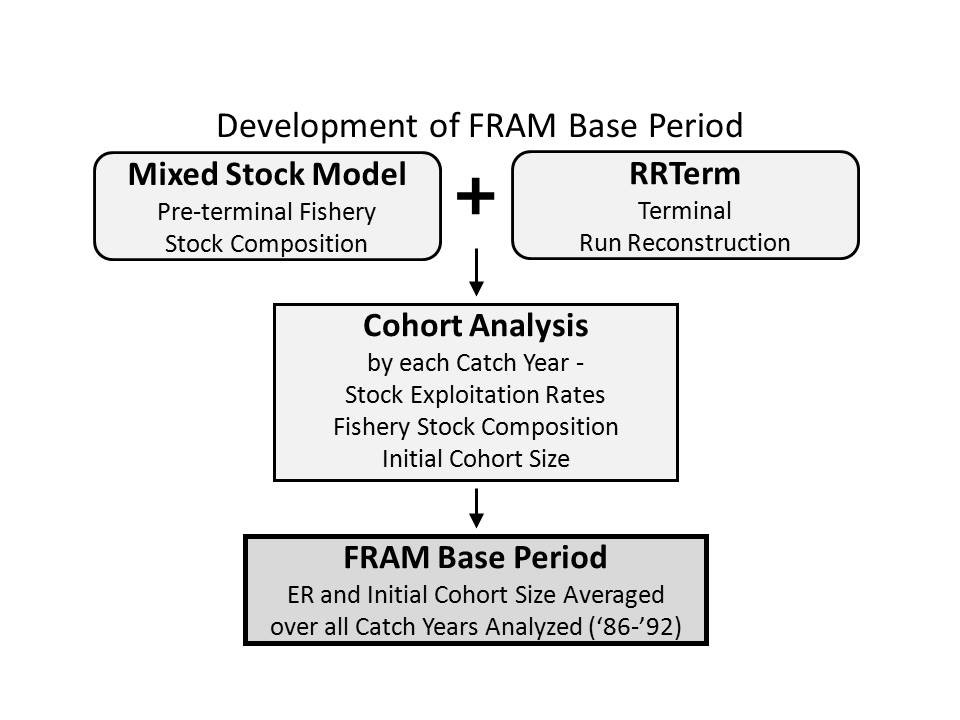

Figure 1.4: General procedure used to generate base period data for Coho FRAM.

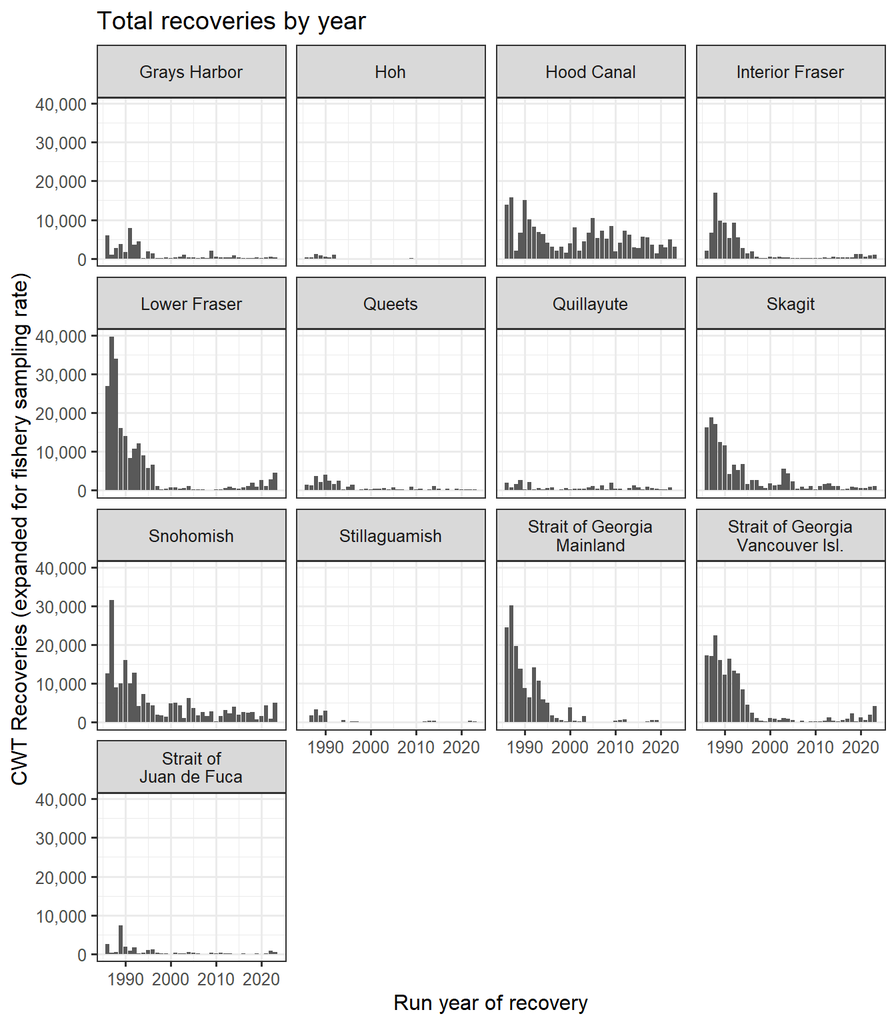

Figure 1.5: Total estimated pre-terminal coded-wire-tag recoveries for all Coho Salmon ages 3 and 4 (regardless of clip status).

### 1.3.1 Key Uncertainties with Coho FRAM analysis

FRAM is a deterministic model that reports point estimates of cohort abundances and without explicit measures of uncertainty associated with them. Managers should consider the following data limitations and model assumptions when interpreting FRAM results:

- Cohort abundances and are sensitive to the quality of escapement estimates, with estimation practices varying substantially among stocks. For example, Puget Sound net pen programs often lack escapement estimates. For these programs, pre-season abundances are used or are scaled to a nearby hatchery program using a pre-post ratio.
- Marine survival indices are used to estimate Canadian abundances, except for Interior Fraser, in both pre- and post-season FRAM runs because abundance forecasts and escapement estimates are highly uncertain or unavailable for the remaining two Canadian MUs.
- It is unknown if average ocean distribution during the FRAM base period (derived using catch years 1986 to 1992 data) reflect the true annual ocean distribution of Coho Salmon stocks in contemporary years. A change in ocean distribution would lead to increased uncertainty in fishery-specific stock impacts.
- Complex regulations, such as fine-scale spatial/temporal and mixed retention limits for natural and hatchery Coho Salmon within a fishery, are difficult to represent and assess within FRAM and as a result, FRAM may not accurately represent stock-specific impacts within fisheries with these regulations.
- Spatial and temporal gaps in catch monitoring of some Canadian fisheries result in underestimation of catch.
- Uncertainty in mortality estimates arises from several sources, including creel census and catch estimation.
- Between time steps in FRAM, natural mortality is a constant rate; additionally, natural mortality does not reflect inter-annual variability in survival during adult ocean residence (January Age-3 through FRAM’s final time step).

For more details, see the [FRAM documentation](https://framverse.github.io/fram_doc/).

## 1.4 Environmental Trends Contextualizing Management

The productivity of Pacific salmon populations is influenced by numerous factors, including human activities (e.g., fishing mortality, habitat restoration and degradation, hatchery production) and environmental conditions in both fresh and marine habitats. Because of this, changes in the productivity for most populations partially reflects variation in environmental conditions. Due to large-scale environmental variation captured by metrics such as the El Niño–Southern Oscillation (ENSO) and Pacific Decadal Oscillation (PDO), population productivity undergoes periods of high and low productivity. Relatively productive conditions resulted in high freshwater and marine survival rates and subsequent high adult returns for many salmon stocks throughout the Pacific Northwest at various times, especially in the late 2000s and early 2010s. However, changes in ocean and freshwater conditions beginning in early 2014 due to exceptionally warm ocean waters and associated terrestrial impacts, plus an extremely strong El Niño event, led to subsequent declines in abundance in many populations. Here, we briefly summarize marine and terrestrial conditions over the past 15–20 years to provide environmental context when examining trends in southern Coho Salmon under the .

### 1.4.1 Terrestrial Conditions

Annual average temperatures and precipitation by water year (Oct–Sep) provide a broad-brush view of terrestrial conditions across the Pacific Northwest. A strong and persistent warming trend and large year-to-year variations in precipitation are among the most notable features in recent decades (Figure 1.6). Within snow-dominated watersheds, warmer winters and springs experienced in recent years reduce snow accumulation and hasten snowmelt. Reduced snowpack causes an earlier and smaller freshet in spring and can result in lower minimum flows and higher stream temperatures in summer.

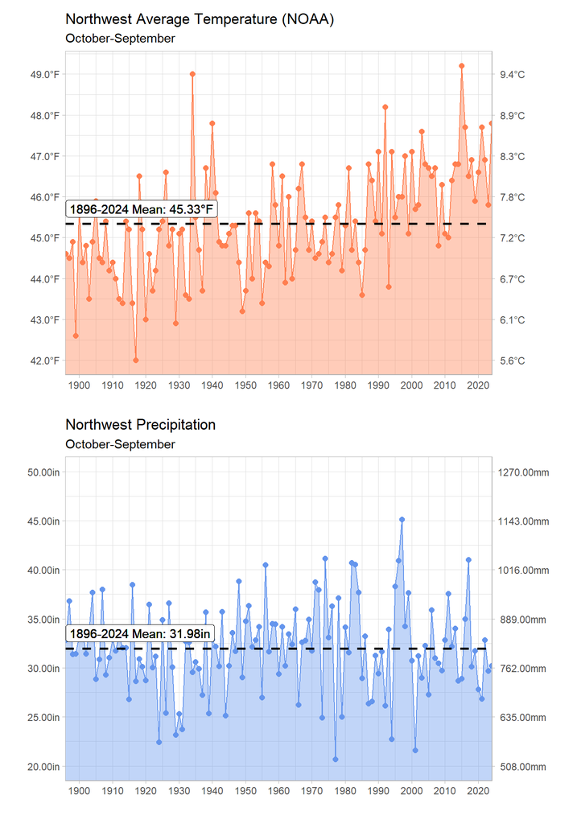

Figure 1.6: Water year (Oct–Sep) surface air temperature (top) and precipitation (bottom) for the Pacific Northwest (OR, WA, and ID combined). The historical average is shown with a black horizontal line. Data from NOAA: https://www.ncdc.noaa.gov/cag/regional/time-series.

For the Pacific Northwest, water year 2015 stands out as the warmest year on record (Figure 1.6). The combination of below-average precipitation and record-high surface air temperature in 2015 brought record-low springtime snowpack to much of the west. Diminished snowpack and high surface temperatures combined with low springtime precipitation yielded especially low runoff to western watersheds in spring and early summer 2015. Unusually low flows and warm stream temperatures in spring/summer 2015 caused widespread problems for salmon throughout the western United States, including large mortality events for returning Sockeye Salmon to the Fraser and Columbia Rivers.

In June 2021, record-breaking terrestrial temperatures were recorded across western North America due to a ‘heat dome’ (White et al. 2023). It resulted in some of the highest temperatures ever recorded across large parts of British Columbia, Oregon, and Washington (11–19°C, 20–35°F above normal temperatures), including the highest temperature ever recorded in Canada (49.5°C, 121.3°F). This 1,000-year event was due to an exceptionally strong ridge centered over the area (the “heat dome”), whose strength was greatly increased by climate change. The heat wave sparked numerous extensive wildfires, extensive damage to forest vegetation and crops, and was responsible for the deaths of nearly 1,400 people across the region.

Coho Salmon inhabiting streams, rivers, and marine environments were likely affected by the heat dome, although many of these impacts are not well documented. Streams temperatures across the region increased dramatically in response to the heat dome, which also decreases oxygen saturation, potentially causing to physiological stress to stream-dwelling fish. In intertidal environments in the Salish Sea, an estimated 1 billion animals (primarily shellfish) died as a result of the heat wave coinciding with extreme low tides, which then impacted water quality (Raymond et al. 2022). The true impacts of the 2021 heat dome on Coho Salmon populations managed under will likely never be known, but may include generally decreased productivity and survival for the 2020 year class (which will return as adults in 2023), because it was residing in freshwater during the extraordinary event.

### 1.4.2 Marine Conditions

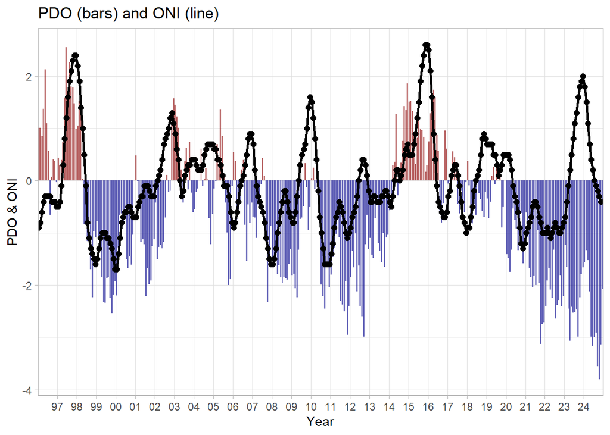

Figure 1.7: Time series of shifts in sign of the Pacific Decadal Oscillation (PDO; bars) and the Ocean Niño Index (ONI; line) from 1996 to the present. Red bars indicate positive (warm) years; blue bars are negative (cool) year. Data from NOAA: https://www.ncei.noaa.gov/pub/data/cmb/ersst/v5/index/ersst.v5.pdo.dat, https://origin.cpc.ncep.noaa.gov/products/analysis_monitoring/ensostuff/ONI_v5.php.

Since the original “blob” in 2014–16 (Bond et al. 2015), a series of marine heat waves have spread across large parts of the North Pacific Ocean in 2019, 2020, 2022, and 2023. These heat waves not only cause elevated water temperatures, but are also associated with extremely low nutrient levels. These heat waves vary greatly in their location across the North Pacific Ocean and although largely offshore, they occasionally spread to coastal waters such as in 2015.

#### 1.4.2.1 Biological impacts of marine conditions

The biological impacts of these temperature swings and marine heat waves are documented in a number of annual reports and descriptive papers (e.g., Morgan et al. 2019) for areas of the northeastern Pacific Ocean that Coho Salmon occupy during their marine residence period. In all cases, the reports show a dramatic biological response at all trophic levels—from primary producers to marine mammals and seabirds—to the marine heatwaves that have spread across the northeastern Pacific Ocean since 2014 and continued into 2023. These ecosystem changes have had large effects (both positive and negative) on Pacific salmon returns around the Pacific Rim, not just southern Coho Salmon.

Overall, the marine heat wave in 2014–2016 had the most drastic impact on marine ecosystems in 2015, with lingering effects into 2016 and 2017. Conditions had somewhat returned to “normal” in 2018 and again in 2021, but marine heat waves in coastal waters in 2019 and 2022 set off a series of marine ecosystem changes across the North Pacific. Here we provide a brief summary of some of the largest biological impacts recent ocean conditions that were observed.

**Primary Producers**. One of the most dramatic impacts to coastal waters was the largest bloom of the diatom Pseudo-nitzschia ever recorded in 2015 (Bates et al. 2018). It stretched from Southern California to the Aleutian Islands in Alaska. Pseudo-nitzschia produces domoic acid, a neurotoxin that causes amnesic shellfish poisoning, which is potentially fatal in mammals (including humans) and seabirds, but apparently does not affect fish. The 2015 bloom caused high domoic acid levels, resulting in fishery closures for razor clams and Dungeness crab and the death of hundreds of seabirds and marine mammals. Continuing (but much smaller) Pseudo-nitzschia blooms have continued across to flare up along the coasts from California to British Columbia ever since.

**Lower Trophic Levels**. Marine heatwaves also dramatically altered the lower trophic levels, resulting in decreases in high quality prey such as lipid-rich copepods and krill, and increases in gelatinous organisms (jellyfish, pelagic tunicates), which have low nutritional value. This shift to poor prey quality was expected to cause poor survival for juvenile fish and seabirds which rely on these prey types. The year 2017 also saw an explosion of *Pyrosoma atlanticum*, from California to SE Alaska. These normally tropical species are rare north of Southern California but spread north starting in 2013, peaking in 2017, and largely absent north of California by 2019. Pyrosomes are a low-quality, high-fiber prey, but were observed in the stomachs of dozens of species, including juvenile and adult Pacific salmon. Lower trophic levels rebounded in 2021, but less so in 2022 due to inconsistent upwelling.

**Nekton**. Larger fish and invertebrates, which serve as forage fish, showed both increases and decreases in abundance and ranges. For example, California market squid has been expanding as far north as SE Alaska, and caught in commercial quantities in Washington and Oregon waters since 2016. Other species that proliferated in the warm water of the California Current include Pacific Pompano, Northern Anchovy, and both Jack and Pacific Mackerel. Species with marked declines include Pacific Hake, juvenile sardine and anchovy, and Pacific Herring. Juvenile rockfish were extremely abundant in the northern California Current and as far north as British Columbia in 2016–18. Exotic American shad, has also exhibited remarkable increases in abundance in the Columbia River, with counts over Bonneville Dam reaching 7.4 million fish in 2019 and exceeding 5 million fish since 2018.

Farther north, Northern Anchovy have been extremely abundant in the Salish Sea since 2016. Juvenile salmon of all species except chum have also been below average off the west coast of Vancouver Island, while Chum Salmon have been abundant. The catch of juvenile salmon in 2017 in both Icy Straits, Alaska (mainly Pink, Chum, and Sockeye Salmon), and off the Washington/Oregon coasts (spring Chinook and Coho Salmon), were both extremely low, consistent with low adult returns (e.g., Columbia River spring Chinook Salmon in 2019). Forage fish in Alaskan waters show mixed trends with decreases in Capelin and Sand Lance and increases in Pacific Herring.

**Apex fishes**. Reports from northern waters suggest increases in several apex fishes, including Spiny Dogfish, Arrowtooth Flounder and sablefish. By contrast, Pacific Cod crashed in 2017, resulting in closures for Alaskan cod fisheries in 2018. Elevated sea surface temperatures in 2015 (and to less extent in 2019) also resulted dramatic range extensions for warm water fishes including billfish, tunas, and sharks.

**Seabirds**. Particularly notable impacts to seabirds were large die-offs of Cassin’s Auklet in winter 2014–15, and Common Murres between summer 2015 and spring 2016 from California to Alaska and again along the Washington–Oregon coasts in fall 2019.

**Marine mammals**. Recent extreme ocean conditions have resulted in several large mortality events for marine mammals. In the California Current, record numbers of California sea lion pups were found starving in early 2015, while there was elevated sea lion mortality during 2013–16. Because of poor conditions along the entire coast, the number of California and Stellar sea lions in the Columbia River estuary peaked in 2015, where they consumed large quantities of adult (and presumably juvenile) salmon. There have also been two large whale unusual mortality events recently: in the western Gulf of Alaska and British Columbia in 2015–16 (52 whales of many species), and a gray whale mortality event in 2019 (over 250 dead whales reported from Mexico to Alaska).

**Pacific salmon**. The abundance of Pacific salmon populations around the Pacific Rim have also shown dramatic changes since 2015. While some populations (especially in northern areas) have returned at record high abundances, others have dropped to new lows. These trends demonstrates that unusually high or low returns are not restricted to any one region, species, or production type (hatchery or natural), but were ocean-wide. For example, recent low steelhead (*O. mykiss*) returns to the Columbia River basin parallel extremely low steelhead returns to the Fraser River basin, and while Russian Pink and Bristol Bay Sockeye Salmon reached record highs, Fraser Sockeye and Japanese Chum Salmon fell to record lows.

Coho Salmon populations from the Oregon coast to the Salish Sea had unexpectedly low returns in 2015, including some of the lowest returns on record. Although returns were predicted to be above average, the small body size and low abundance of these adults suggested poor feeding conditions during the last summer in marine waters. Steelhead returns were extremely low in 2017 and 2018 in the same areas, to the point that Thompson and Chilcotin River (Fraser River, British Columbia) steelhead were petitioned for emergency protection under the Canadian Species At Risk Act (Neilson and Taylor 2018). One species in the region that increased in abundance was Chum Salmon starting in 2016, perhaps in part due to their reliance on gelatinous prey, which were abundant.

Both Fraser and Columbia River Sockeye Salmon, which re-enter freshwater in mid-summer, incurred huge in-river mortalities in 2015 due to elevated river temperatures. The following year (2016), Fraser River Sockeye Salmon had the smallest return on record (total run of <1 million fish), but was even lower in 2019 (500,000 fish), as progeny of the 2015 year class returned as adults. The 2020 Fraser River Sockeye Salmon return was still lower (<300,000 fish). By contrast, Columbia River Sockeye Salmon returns were relatively high in 2016 (326,000), and reached an all-time high of 341,000 counted over Bonneville Dam in 2020.

In Alaska, there was a strong east–west gradient in run size, with western Alaska generally having exceptionally high salmon returns, while central and southeastern Alaska saw declines. Perhaps most impressive has been the annual catch of Bristol Bay Sockeye Salmon, which broke a new abundance record in 2022 with 79 million adults (the 20 year [2002–2021] average run was 43.6 million). Similarly, 2017 was the highest statewide catch of Chum Salmon on record, due in part to record Prince William Sound catches. In contrast, the abundance of Yukon River Chinook and Chum Salmon have greatly declined for reasons that aren’t entirely clear, leading to conservation concerns for both the salmon and the many subsistence fishers who rely on these runs for nutrition.

# 2 Determination of Status Benchmarks and ER Caps

## 2.1 Canadian Management Units

Procedures for determining the pre-season status of Canadian are being developed concurrently with determination of Conservation Unit (CU) status benchmarks required with implementation of the Canada Department of Fisheries and Oceans’ (CDFO) Wild Salmon Policy. Methods have been approved through the ’s internal peer review process, Center for Scientific Advice - Pacific (CSAP) (Holt et al. (2009)). Work in 2018 identified a framework to develop potential Management Reference Points for Canadian (DFO 2018, Korman et al. 2019; https://www.pac.dfo-mpo.gc.ca/consultation/smon/pst-coho-tsp/index-eng.html) included spawner abundance targets but also smolt-to-adult (or “marine”) survival index targets. It was deemed that targets must contain spawner abundance targets, which limited creation of management reference points to the Interior Fraser River because it was the only unit with an aggregate abundance timeseries.

Since 2002, in the absence of benchmarks, the Stock Assessment staff has provided a categorical outlook for the next year’s salmon status. The [outlook](http://www.pac.dfo-mpo.gc.ca/fm-gp/species-especes/salmon-saumon/index-eng.htm) is intended to provide an objective and consistent context within which to initiate fisheries planning.The category reflects the current interpretation of existing quantitative and qualitative information, including pre-season forecasts if available, and the opinion of Area stock assessment staff. Where management targets for stocks have not been formally described, interim targets were either based on historical return levels or, if necessary, opinion of local staff.

Canadian Coho Salmon abundance has declined, particularly in southern BC. Interior Fraser River Coho Salmon was assessed as endangered by the Committee on the Status of Endangered Wildlife in Canada (COSEWIC) in2002 and then reassessed as threatened in 2016. Interior Fraser River Coho Salmon have not been listed on Schedule 1 of the Species at Risk Act, which would afford additional protections to the stock. However, the Canadian Minister of Fisheries and Oceans has established a domestic cap of 3-5% for Canadian fishery impacts on Interior Fraser Coho Salmon. The Interior Fraser is comprised of five (North Thompson, South Thompson, Lower Thompson, Fraser Canyon, and Upper Fraser). The Interior Fraser River Coho Salmon recovery planning process has determined the critical benchmark needed to maintain population viability. Even with the reduction in fisheries exploitation, all Southern BC have followed a similar dramatic declining trend in both marine survival and total abundance from the high levels observed in the 1980s and early 1990s. Spawning escapements have responded to the decreased exploitation and are within the range observed during the 1970s and 1980s. However, the sustained low marine survival has resulted in a decreased total abundance.

Because of the absence of programs to estimate total abundance and escapement for the Strait of Georgia and Lower Fraser River Canadian , the bilaterally-developed tool, Backwards Coho FRAM, is relied upon to generate estimates of ocean age-3 cohort abundance and using post-season data scalars. Cohort abundances (catch and escapement) of Canadian , estimated by Backwards Coho FRAM based on modeled scalars, are depicted in Figure Figure 4.1. Reduced abundances apparent since 1996 were a major consideration that led to the development of ABM regimes for management of southern Coho Salmon.

## 2.2 US Inside Management Units

The status for US Inside is assigned based on ocean abundance (forecasted or re-constructed). Pre-season estimates of ocean abundance are typically forecasted from measured or modeled smolt production for each and multiplied by a marine survival rate predicted for each . Marine survival is predicted with a variety of methods including average return rates, correlations between jack and adult return rates, and correlations between environmental variables and historical return rates. Post-season estimates of ocean abundance are estimated using escapement and catch data and the Backwards Coho FRAM (Figure 4.2). The status of each is defined by a series of ocean abundance breakpoints. Domestic management of Puget Sound naturally-spawning Coho Salmon stocks also uses abundance-based, tiered objectives defined in the Comprehensive Coho Plan (Comprehensive Coho Workgroup 1998), that are similar to but not exactly consistent with the guidelines. The identified break points between Low, Moderate, and Abundant status are based on population-specific productivity analyses conducted by the state and tribal co-managers in each river basin.

## 2.3 US Outside Management Units

The status for US Outside is assigned based on the ceiling identified annually, ocean abundance, and existing escapement goals (Pacific Salmon Commission 2022). Management objectives are expressed as a range of spawning escapements expected to produce MSY (Pacific Fishery Management Council 2023a). Allowable are calculated from the forecast abundance and the lower end of the existing escapement goal range and used to classify the categorical status of the . This rate is the maximum allowed under the when the is in the moderate or abundant status, but up to 20% are allowed if the is in the low abundance status.

## 2.4 US Management Units Federal Status

Coho Salmon were the first Pacific salmon species for which coast-wide evolutionarily significant units (ESUs) were delineated (Ford 2011). Based on genetic and life history information, the US subject to the belong to three different Coho Salmon ESUs, the Puget Sound/Strait of Georgia, the Olympic Peninsula, and the Southwest Washington ESUs. The Puget Sound/Strait of Georgia Coho Salmon ESU is currently a species of concern under the US Endangered Species Act (ESA; Ford (2011); Species of Concern 4/15/04, 69FR19975). The Olympic Peninsula ESU was evaluated for listing under the ESA and was determined to be not warranted (60 FR 38011; July 25). The Southwest Washington ESU is currently categorized as “undetermined”. Puget Sound/Strait of Georgia Coho Salmon are not currently candidates for listing in Washington as State Endangered, Threatened, or Sensitive (Washington Department of Fish and Wildlife 2020).

At the federal level, species of concern do not have formal protection under the ESA. The primary purpose of identifying species of concern is to prevent the need to list them as threatened or endangered under the ESA. This purpose can be achieved by the following actions: (1) identifying species potentially at risk; (2) increasing public awareness about those species; (3) identifying data deficiencies and uncertainties in species’ status and threats; (4) stimulating cooperative research efforts to obtain the information necessary to evaluate species’ status and threats; and, (5) fostering voluntary efforts to conserve the species before listing becomes warranted.

Additionally, at the federal level, Coho Salmon caught in coastal waters of the U.S. (e.g., greater than 3 but within 200 nautical miles offshore) are managed under the Magnuson-Stevens Fishery Conservation and Management Act (MSA), which is the legislation providing for the management of marine fisheries in U.S. waters. In 2018, the National Marine Fisheries Service (NMFS) notified the that the Strait of Juan de Fuca, Queets, and Snohomish natural Coho Salmon stocks managed under the ’s Pacific Coast Salmon Fishery Management Plan (FMP) met the overfished criteria of the FMP and the MSA. NMFS determined that these stocks were overfished under the MSA, due to spawning escapement falling below the required level for the 3-year period 2014-2016. The MSA requires overfished stocks to be rebuilt in as short a time as possible, not to exceed 10 years. The overfished determinations were announced in the Federal Register on August 6, 2018 (83 FR 38292). In response to the overfished determination, the developed rebuilding plans for these stocks and provided them to NMFS in 2019. In 2021, NMFS issued a final rule under the authority of the MSA to approve and implement rebuilding plans recommended by the for the three stocks ([86 FR 9301](https://www.federalregister.gov/documents/2021/02/12/2021-02834/fisheries-off-west-coast-states-west-coast-salmon-fisheries-rebuilding-Coho-salmon-stocks)). This final rule adopts the existing harvest control rules, which use an annual abundance-based stepped harvest rate control rule with stock-specific abundance levels governing the total applied to forecast stock abundance levels. For Snohomish natural Coho Salmon, this final rule amends the existing harvest control rule by adding a 10% buffer to the existing escapement goal and adjusting the abundance steps during the rebuilding period. For all three Coho Salmon stocks, the ’s Salmon Technical Team’s analysis determined that freshwater and marine habitat conditions were the primary cause of these stocks meeting the FMP’s criteria for being overfished rather than fishing. Recently, it was determined that the Queets and Strait of Juan de Fuca have met the criteria for rebuilt status based on the most recent three-year geometric mean of escapement estimates (2020-2022) (Pacific Fishery Management Council 2024a).

# 3 Annual Implementation of the Southern Coho Management Plan

The Coho FRAM (Coho FRAM, Model Evaluation Workgroup (MEW). 2008) has been the tool used to plan US preseason fisheries, and also to evaluate postseason by the fisheries of both Parties on the naturally spawning Coho Salmon specified by the CoABM. Canada has not been using Coho FRAM preseason, instead using a combination of a ‘domestic model’ for planning marine fisheries and a ‘decay model’ for planning Fraser River fisheries. (**Jeromy’s comment - Can we describe what get’s exchanged during the preseason process to reconcile this difference here in one or two sentences?**)

Each country manages the Coho Salmon harvest within its cap through its own domestic fisheries management processes and annual fisheries plans. For Canada, the annual domestic planning process is documented in the salmon Integrated Fisheries Management Plan (IFMP) at the culmination of the process each June (*is June correct?*). For the US, the North of Cape Falcon ocean salmon fishing plans are reported in Preseason Report III (PFMC documents) at the culmination of the process each April. For US Inside , the 2019 uses the thresholds and stepped harvest rate goals from the Comprehensive Coho Agreement and adopted as (Fishery Management Plan) FMP conservation objectives in 2009. For US Outside , constraints represent the Maximum Fishing Mortality Threshold (MFMT). For US domestic purposes, the status categories are “critical”, “low”, and “normal”, which correspond to the categories of “low”, “moderate” and “abundant”, respectively (Pacific Fishery Management Council 2024b).

The US FMP includes status determination criteria (SDC) for overfishing, approaching an overfished condition, overfished, not overfished/rebuilding, and rebuilt (Pacific Fishery Management Council 2023b). These criteria are:

- Overfishing occurs when a single year exceeds the maximum fishing mortality threshold (MFMT), which is based on the maximum sustainable yield (FMSY);
- Approaching an overfished condition occurs when the geometric mean of the two most recent postseason estimates of spawning escapement, and the current preseason forecast of spawning escapement, is less than the minimum stock size threshold (MSST);
- Overfished status occurs when the most recent 3-year geometric mean spawning escapement is less than the MSST;
- Not overfished/rebuilding status occurs when a stock has been classified as overfished and has not yet been rebuilt, and the most recent 3-year geometric mean spawning escapement is greater than the MSST but less than Sustainable Maximum Yield (SMSY; the number of spawners need to maintain the highest possible annual catch of a population, a biological benchmark that represents a healthy population);
- A stock is rebuilt when the most recent 3-year geometric mean spawning escapement exceeds SMSY.

**should we delete this? Include it under the MUs? or, leave here and update the status?**

## 3.1 Annual Determinations of Allowable Exploitation Rates for Management Units

## 3.2 United States fishery Planning Process

The US annual salmon fishery planning process starts in January with a Stock and Fishery Evaluation (SAFE) report on fisheries and escapements from previous years and concludes in early April when preseason fishing plans for US fisheries are developed. Outlined below are the Coho FRAM inputs used within the US domestic process to plan annual Coho Salmon fisheries, and postseason data needed to evaluate the preseason plan.

*Preseason FRAM inputs:*

- Stocks’ abundance forecasts
- Fishery inputs by Coho FRAM time period (e.g., season structure, gear and retention restrictions, quota levels, fishery harvest rate scalars)

*Inseason:*

- FRAM fishery adjustments

*Postseason FRAM inputs:*

- Stocks’ observed escapement
- Fisheries’ observed catch and non-retention mortality by FRAM time period

Because the domestic planning processes of the Parties are not synchronous, a single pre-season command file containing expectations for both Canada and the US is not available prior to the conclusion of the process (US pre-season fishery planning) in April. Therefor, in any given year the pre-season command file used by the incorporates cohort abundance for both Canadian and US , but planned fishery regulations for US fisheries only. Unless other information is available, Canadian regulations are assumed to be similar to those implemented in the previous year. Subsequent to this process, additional command files are generated to represent the actual Canadian fishing plans. Command files used in pre-season planning from 2004 to 2023 are detailed in Table 10.1. These files contain specific information used at the time to model fisheries along with the pre-season forecasts of stock abundances.

### 3.2.1 US Preseason Abundance Forecasts

US forecast development commences in January of every year. US Forecasts for both Coho and Chinook Salmon stocks are finalized in late February and published in the annual ’s Pre I Report (https://www.pcouncil.org/salmon-management-documents/#access-salmon-safe-and-management-documents-toc-7e081b15-e1b0-409d-a12e-1a77c0b34e2b). In mid-March, the Parties share general expectations for stock abundance and fisheries though a manager-to-manager information exchange (see Development of Canadian Preseason Coho FRAM Inputs). These forecasts are then used throughout the /NOF (North of Falcon) salmon fishery planning meetings which conclude at the April meeting.

The forecast methodologies for many US stocks’ are generally based upon the products of two estimates specific to each production source: 1) number of smolts leaving freshwaters; and, 2) expected regional marine survival rates. Numbers of naturally produced smolts are estimated in a variety of ways but are based upon a large and widely distributed system of smolt traps. The number of smolts released from hatcheries are known. Marine survival is defined as, and calculated from, catch plus escapement from data. Sibling relationships, between jack returns and subsequent return to the mature cohort, have also been used as an index to predict marine survival. Environmental conditions have been increasingly relied upon as predictors of anticipated survival from smolt to adults entering the fisheries.

In recent years, a variety of preseason abundance estimators have been employed for Puget Sound and Washington coastal Coho Salmon stocks, primarily based on smolt production and survival (Pacific Fishery Management Council 2023b). These estimators are used to forecast preseason abundance of adult Ocean Age 3 recruits. Forecasts for natural Puget Sound Coho Salmon stocks were generally derived by measured or predicted smolt production from each major watershed or region, multiplied by stock-specific marine survival rate predictions based on a jack return model from the WDFW Big Beef Creek Research Station in Hood Canal, natural Coho Salmon tagging programs at Baker Lake (Skagit River basin) and South Fork Skykomish River, adult recruits/smolt data generated from the WDFW Deschutes River Research Station, or other information.

### 3.2.2 Development of US Preseason FRAM Inputs

US fishery planning relies upon both the Coho and Chinook FRAM models. The process starts at the early March meeting, proceeds through March at a variety of regional meetings (including the NOF meetings), and concludes in early/mid April at the next meeting.

**US Coho FRAM Stock Abundance Inputs:** Abundance forecasts are incorporated into two models, Coho FRAM and Chinook FRAM, both of which rely on similar algorithms and common computer code. Mass marked and unmarked naturally and hatchery produced stocks (components of ) are represented in US Coho FRAM (e.g., Queets naturally produced unmarked, Queets naturally produced marked, Queets hatchery unmarked, Queets hatchery marked). For the specified by the CoABM, appropriate unmarked naturally produced stocks are combined. Numeric forecasts for southern US Coho Salmon stocks are provided from regional managers which utilize a variety of methodologies. The annual forecasts of Coho FRAM stocks are entered as Abundance Scalars, applied within the model to Base Period Stock Abundance.

Prior to the March meeting, an initial Coho FRAM model run with last year’s planned fisheries and the current year’s US forecasts serves to inform, in a general sense, how the fishery plan from the previous year needs to change to accommodate the current year’s stocks’ abundances. The results from this model run are included in the ’s Pre I Report (for these reports see: https://www.pcouncil.org/salmon-management-documents/#access-salmon-safe-and-management-documents-toc-7e081b15-e1b0-409d-a12e-1a77c0b34e2b).

Starting with this initial model run, the US domestic salmon planning process is affected by the timing and quality of forecasts for Canadian Coho Salmon stocks. Coho FRAM performs best when data for all stocks are incorporated. The US domestic process is, in theory, at the half way point before Canadian forecasts are provided and combined with US forecasts for FRAM modeling at the NOF 2 meeting in late March. Thus, at the March meeting and the NOF 1 meeting there is hesitation to fully use the FRAM results for planning domestic fisheries as those results will likely change when Canadian forecasts are incorporated.

**US FRAM Fishery Inputs:** Expected fishery catch and/or mortality is the other major category of preseason inputs to Coho FRAM. At the March meeting three options (e.g., catch levels, retention restrictions, harvest rate scalars, seasons) are developed (low, moderate, high) for the US ocean fisheries (California, Oregon, and Washington coasts). The FRAM results for both Coho and Chinook Salmon from these March options are published in the annual PFMC Pre II Report.

During the course of March and early April US meetings, the NOF domestic planning refines fishery inputs to insure compliance with various agreements. These include the Salmon FMP, domestic and international treaties; and the US ESA which collectively establish constraints on fishery impacts upon US Coho and Chinook Salmon stocks.

For the ocean fisheries the model inputs are Catch Quotas and regulations such as mark-selective fisheries, with the expectation that subsequent inseason monitoring will close fisheries without exceeding quotas. The model inputs for most sport and commercial US Puget Sound marine and terminal area fisheries are expected catch or expected harvest rates, generally based upon recent year averages and anticipated fisheries for Fraser Sockeye, Pink and Chum Salmon, and regulations such as mark selective fishing. In some cases the Catch Quota management approach is also used within Puget Sound with planned fishery closure as inseason observations indicate FRAM total fishery mortality estimates are being approached. The mortality associated with Coho Salmon non-retention is another class of fishery inputs.

Throughout this process, the January post season, Pre I-III reports are provided to Canada as information. The Final April Coho FRAM run is also provided to Canada. It is the April model run that until recently has provided the information for post season assessment of (see Canadian section of “Timing of Domestic Planning” for potential exception).

### 3.2.3 US Inseason Management

This information is from the ’s 2024 Preseason Report III (Pacific Fishery Management Council 2024a).

Inseason changes to planned U.S fisheries are limited, but have been implemented under some specific conditions. When ocean area/fishery specific quotas are not being caught in an ocean area then part of the quota may be transferred to another ocean area/fishery, based upon FRAM estimates of neutral impacts to the limiting stock(s); this may include adjustments to bag limits, seasons, and/or MSF regulations. The preseason planned prosecution of some fisheries is dependent upon the results of test fisheries, i.e., the Fraser Panel Sockeye directed commercial fisheries. Emergency closures due to attaining or exceeding planned catch quotas or in response to indications of reduced abundance.

### 3.2.4 US Management Units 2024 Exploitation Rate Constraints

For 2024, Puget Sound and Washington coast Coho Salmon preliminary constraints are as follows (Pacific Fishery Management Council 2024a):

Table 3.1: PST Southern Coho Management Plan

| **PST MU** | **Total Exploitation Rate Constraint** | **Categorical Status** |
| --- | --- | --- |
| Skagit | 60% | Abundant |
| Stillaguamish | 50% | Abundant |
| Snohomish | 40% | Moderate |
| Hood Canal | 45% | Moderate |
| Strait of Juan de Fuca | 40% | Moderate |
| Quillayute Fall | 39% | Moderate |
| Hoh | 59% | Abundant |
| Queets | 55% | Abundant |
| Grays Harbor | 57% | Abundant |

(Table 3.1) constraint is Preliminary. For Puget Sound and Washington Coast management units, the constraints reflect application of the 2019 . Under the , categories (Abundant, Moderate, Low) correspond to the general ranges depicted in paragraph 8(b)(iii) of the 2019 . For Washington Coast stocks, categorical status is determined by the associated with meeting the escapement goal (or the lower end of the escapement goal range). As Washington Coast stocks are managed to achieve agreed escapement goals, this also becomes an approximation of the maximum allowable rate unless the stock is in the “Low” status. In that case, an of up to 20% is allowed.

Grays Harbor constraints are based on projected natural area spawners (wild plus hatchery strays) and MSP escapement goal of 35,400. Exploitation rate constraint subject to change should comanagers agree to a modified escapement goal under US v. Washington and Hoh v. Baldrige case law.

## 3.3 Canadian Fishery Planning Process

Annual Canadian fisheries are planned using a combination of two domestic models (marine fisheries and freshwater decay models) and tools focused upon Interior Fraser River (IFR) Coho Salmon The planning process starts early in the year. A draft IFMP is available for stakeholder comment in April, but the IFMP is not finalized until formally approved by the Fisheries Minister in June.

In the domestic process, initial planning scenarios are developed based on discussions with Fishery Managers, preliminary salmon outlook for stock status (prepared in November of previous year), effort expectation (targeted or incidental impact on IFR Coho Salmon) given constraints, and domestic allocation policy. Once stock abundance forecasts are available in March and timing and diversion forecasts for Fraser Sockeye are available in June, the final Salmon IFMP is submitted to the Minister for approval. The Canadian domestic model does not use Coho Salmon abundance forecasts directly, relying instead upon past relationships between fisheries’ effort and IFR , to estimate preseason projected for IFR. Depending on what species or fishery specific objectives are in place for the upcoming season, the domestic model is populated with anticipated effort based on trends in recent years and scaled to base period (1986–1997) effort. Multiple scenarios are run based on adjusting preliminary fishing plans (species, effort, month, gear, regulations) and results are reviewed by Fisheries Managers and evaluated for multiple objectives, in particular, meeting the preseason objectives for IFR CCoho Salmonoho.

Key considerations for Canadian fishery management for Coho Salmon in 2024 are expected to include: (1) meeting domestic conservation obligations for Interior Fraser (including Thompson River) Coho Salmon; (2) Coho Salmon harvests by First Nations fisheries; (3) incidental impacts during commercial and First Nations fisheries directed at Chinook, Chum, and especially Fraser Sockeye Salmon which will see a dominant late run return in 2024. The Canadian fishery regimes affecting Coho Salmon are expected to be driven by Canadian domestic allowable impacts on the Thompson River component of the IFR management unit, Fraser Chinook concerns and Fraser Sockeye stocks of concern co-migrating with the late run.

In years prior to 2014, Canadian fisheries were managed so as not to exceed a 3% maximum . In May 2014, Canada decided to permit up to a 16% on upper Fraser Coho Salmon in Canadian fisheries to allow for impacts in fisheries directed at a record Fraser Sockeye forecast. Since 2015, upper Fraser Coho Salmon in Canadian fisheries have been managed per low status limitations. The projected status of Canadian coho in 2024 indicates continuing concerns for the condition of Interior Fraser Coho Salmon. The Interior Fraser Coho Salmon is anticipated to remain in low abundance status, resulting in a requirement to constrain the total mortality fishery for 2024 Southern U.S. fisheries to a maximum of 10.0%.

### 3.3.1 Development of Canadian Preseason Coho FRAM Inputs

The US preseason Coho FRAM modeling requires Canadian inputs to complete the model for the US domestic planning and this also enables the pre to post season Coho FRAM evaluation of both Parties’ fisheries. The Canadian data used to inform Coho FRAM for annual US preseason planning and joint postseason evaluation are outlined below:

*Preseason:*

- Stocks’ abundance forecasts, or;
- Regional expected marine survival rates, based on indicator stocks;
- FRAM fishery scalars by Coho FRAM time period from postseason analysis of a fishery plan similar to anticipated fishing patterns

*Inseason:*

- FRAM fishery adjustments or significant deviations in expected abundance / catch

*Postseason:*

- Stocks’ observed escapement, or;
- Regional observed marine survival rates;
- Fisheries’ observed catch by FRAM time period

**Canadian FRAM Stock Abundance Inputs:** US FRAM preseason modeling requires forecasts of Canadian stocks. Forecast development commences every year in early March, and is provided to US FRAM modelers in mid to late March for use at the second NOF meeting, prior to the April PFMC meeting.

To obtain these values Canadian forecast methodology uses the following information:

1. Annual hatchery production
2. Base Period FRAM natural production
3. Base Period hatchery production
4. Predicted marine survival
5. Base Period marine survival
6. Base Period FRAM stock abundance values

Estimates of freshwater production (smolt out-migrants) for hatchery produced Coho Salmon, by FRAM production region, are scaled to Base Period production. Next the annual expected regional marine survival (MS) is scaled to Base Period marine survival. Both ratios are applied to a stock’s Base Period Abundance to produce the annual adult abundance forecasts. To illustrate (*by stock*):

$$\text{Adult H Abundance} = \text{(Base Adult Abundance)}\frac{\text{(Annual H Smolts)}}{\text{(Base H Smolts)}} \frac{\text{(Expected MS)}}{\text{(Base MS)}}$$

Hatchery smolt data are obtained from the Canadian Salmon Enhancement Program. Where naturally produced smolt out-migrant estimates exists (2 of 14 Canadian production regions), the values are used. For the production regions where naturally produced smolt data are not available (the remaining 12 of 14 Canadian production regions), the default production starting values has been the same as the annual hatchery output for the same FRAM production region, which assumes similar smolt abundance trends between naturally produced and hatchery smolts occurs across time. (**Jeromy comment - “Correct? If so, can we say in a sentence or two how reliable, or potentially unreliable this practice is going forward?”**) As hatchery production has been reduced over time it has become necessary to find other means to obtain the surrogates for naturally produced smolt production.

Marine survival expectations have been based upon hatchery and wild indicator returns. As the number of Coho Salmon indicators has been reduced over time it has become necessary to use adjacent indicators to estimate marine survival for some and use hatchery indicators to estimate survival of naturally spawning Coho Salmon.

For IFR, where naturally produced smolt output is not available, the forecasted adult returns are used as inputs to Coho FRAM. This forecast is based on a naive model, usually an average of the previous three years estimated ocean adult abundance. However, the forecast may be “as observed last year” when it appears a longer term average is not appropriate; this was the case for the 2016 fishing year forecast. Several US 2016 forecasts also used the “as observed last year” approach due to the extremely poor returns in 2015 and the observations that those same poor environmental conditions existed for the smolts entering the ocean in 2015 (i.e., the 2016 adults).

**Canadian FRAM Fishery Inputs:**

Preseason FRAM’s anticipated fishery related mortality for Canadian Coho Salmon retention fisheries is modeled using Fishery Scalars (these Scalars essentially function as a harvest rate within the FRAM) taken from postseason Coho FRAM model runs with similar fishery plans and effort. For example, impacts of the Fraser River Sockeye directed fisheries may be estimated from 4 years previous. The Fraser River pink directed fishery impacts are estimated from the fisheries 2 year previous. The impacts from the Chinook troll fishery are based on a year with a similar Chinook harvest guidelines. The mortality associated with Coho Salmon non-retention regulation is another class of fishery inputs, also taken from previous postseason FRAM model runs under the assumption of similar fishery plans and effort, and similar Coho Salmon abundance levels.

### 3.3.2 Canadian Inseason Management

Canadian fishery planning process generally concludes in June, with the fisheries directed upon Fraser River salmon (Pinks, Sockeye, and Chum) driven by test fisheries. This later planning process can produce anticipated fishery impacts that diverge from the postseason Canadian fishery scalars used for the US domestic modeling the previous April. In such cases the April PFMC FRAM model run can be “updated” to evaluate both Parties compliance with the Coho Agreement.

## 3.4 Joint Canadian and US Postseason Evaluations

Backwards Coho FRAM requires estimated mortalities by fishery strata (uses the Base Period stock-fishery-time steps; terminal IFR fisheries have been incorporated recently) and available estimates of escapements to reconstruct annual cohort abundances and generate post-season estimates of . The escapement estimates for Coho FRAM stocks and catch information (catch, type of fishery –Mark Selective, Non-retention, Quota) for FRAM fisheries are compiled from various government agencies (USA: Federal, State and Tribal; Canada: Federal, and First Nations) and reviewed by the CoTC.

The Backwards Coho FRAM derives total cohort abundance of Coho FRAM stocks through an iterative process of estimating the set of stock abundance scalars that best explain observed escapements and reported catches. FRAM calculation of stock abundance scalars is the preferred method and occurs when escapement data are available (almost all US stocks). When escapement estimates are not available (almost all Canadian stocks), the stock abundance scalars are calculated externally and entered into FRAM; an estimate of “observed” marine survival has been used as a surrogate to recalculate Canadian stock abundances per the preseason method previously described. Consequently, FRAM’s iterative process of estimating a full set of stock abundance scalars is not possible and this has implications for backwards FRAM estimates of abundance for all stocks. Ideally total cohort abundance for each is derived by summing model estimated stock specific: pre-terminal catch, terminal catch, and escapement.

The Backwards Coho FRAM provides two estimates of cohort abundance, termed “Ocean age-3” (OA3) and “January age-3” (JA3). Ocean age-3 abundance includes escapement and fishery impacts. includes escapement, fishery impacts, and natural mortality. is the basis for stock status and is therefore the measure provided in the tables and figures in this report, and in the annual postseason evaluations.

These estimates of cohort abundance, catches and escapements are used to generate estimates of and determine status for post season reporting to the Southern Panel.

## 3.5 Overview of Coded Wire Tag Use

The use of the term indicator stock within this report does not imply a set list of agreed to indicator stocks. Instead, the CoTC assesses all available data for inclusion in the Mixed-Stock Model (MSM), cohort reconstructions, and other processes. With the base period spanning many years, it is beneficial if a stock is well tagged and well sampled over a long period of time. The coded-wire tag indicator stocks provide the primary data for predicting, monitoring, and modeling harvest impacts on individual Coho Salmon populations. The Joint Coho Technical Committee (CoTC) uses recoveries from the indicator stocks to reconstruct cohorts coastwide. While a few indicator tag groups are naturally-spawning fish, the vast majority consist of hatchery fish intended to represent each . Hatchery indicator stocks are selected on the basis of brood stock, rearing, and release strategies and are assumed to be surrogates for the naturally-spawning fish. The indicator program assumes that tagged and untagged fish experience similar trends in marine survival and similar exploitation patterns. Coastwide, approximately eight million juvenile Coho Salmon are coded-wire tagged annually (Nandor et al. 2010).

Some major changes in the indicator stock program have occurred since the was signed in 1985. One of the most notable changes is the mass marking of hatchery fish in the Pacific Northwest. For many years, an adipose fin clip was used as an external mark to identify fish (natural spawning or hatchery) with a . However, since brood year 1995 in the US and 1996 in Canada, the adipose fin clip has been used as a mass mark to identify hatchery-origin fish and no longer uniquely indicates a coded-wire-tagged fish. With the advent of mark-selective fishing, marked (adipose fin-clipped) and unmarked fish do not have the same patterns of exploitation, violating the fundamental assumption of the indicator tag program. These changes in marking and fishing have resulted in the development and use of double index tag (DIT) releases in the indicator tag programs. The group consists of two groups of hatchery fish, each 100% tagged with its own unique . The two groups are presumed to be identical, except that one tagged group is unmarked and the other group is marked with an adipose fin clip. In a MSF, catches of marked fish will be retained whereas catches of unmarked fish will be released. The difference in return rates to the hatchery reflects the difference in ocean ERs in selective fisheries. A group is recommended when the stock of interest is expected to be exploited by a mark-selective fishery (MSF). Unpaired (non-DIT) tag groups are either marked or unmarked and are considered single index tag (SIT) groups in this document.

To obtain unbiased estimates of fishery-specific impacts on individual stocks, a known proportion of both the catch and escapement must be sampled for throughout the migratory range of the stock and the proportion sampled must be adequate to produce a statistically reliable expansion of sampled Coho Salmon Mass marking creates the following two additional complexities for sampling of : (1) stocks are unmarked but contain ; and (2) marked fish do not necessarily contain . Therefore, all fish, not just marked fish (with an adipose fin-clip), must be sampled for . Detection of in unmarked fish requires electronic sampling using wands or tubes. Detection of in marked fish requires either field-based electronic sampling or collection of snouts for processing in the laboratory. For complete accounting, fish must be sampled throughout their range, in catch and escapement. Electronic sampling of both unmarked and marked Coho Salmon places an additional burden of time and expense on agencies

### 3.5.1 Wild Stock Tagging programs

When developing the FRAM base period, the CoTC used wild indicator stocks to represent a when the data was available. The figures below summarize data currently reported in on coded-wire-tagged wild Coho Salmon smolts released within the . Most of the reported wild stock tagging has occurred in the Grays Harbor, and Queets ; followed by Strait of Georgia, Hood Canal, Skagit, and Lower Fraser . However, no wild stock tagging has been reported in the Lower Fraser since brood year 2007. Very little wild stock tagging has taken place in the remaining . Not all of the data depicted was used in the MSM and subsequent cohort reconstructions.

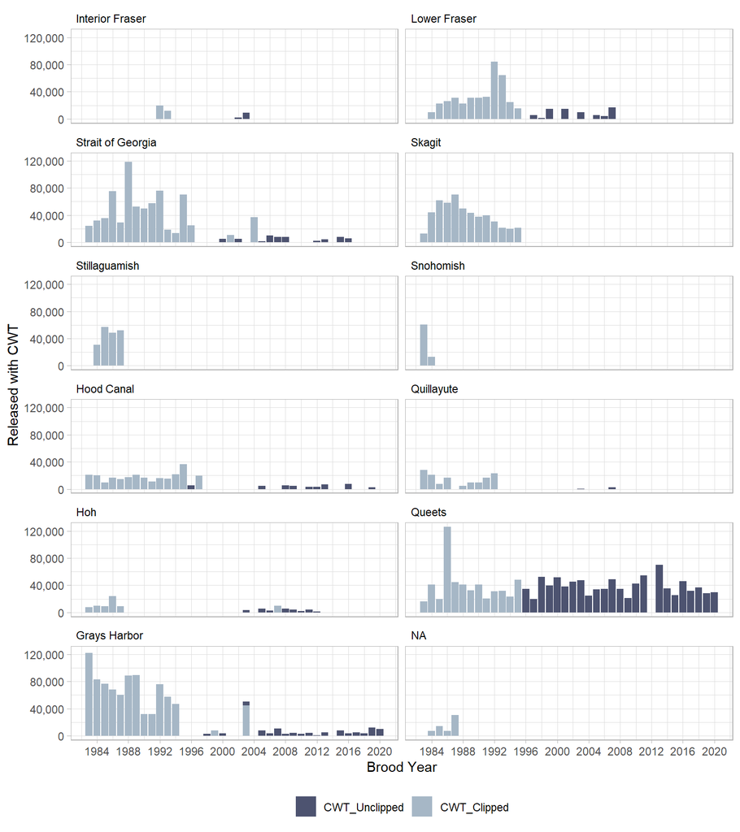

Figure 3.1: Total number of wild Coho Salmon smolts caught, tagged, and released by clip status for each Management Unit over brood years 1983 through 2020 (data downloaded from RMIS 9-6-2023).

### 3.5.2 Hatchery Tagging Programs

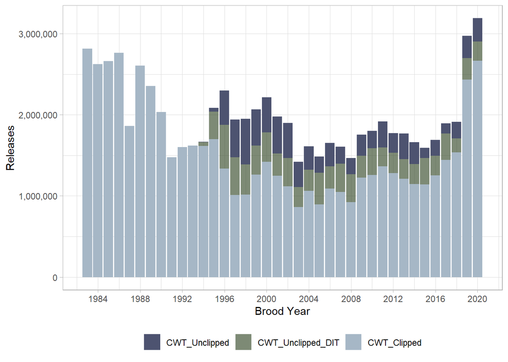

Figure 3.2: Total number of hatchery Coho Salmon smolts released by clip status for all Management Units combined over brood years 1983 through 2020 (data downloaded from RMIS 9-6-2023). “CWT_Unclipped_DIT” refer to tagged fish that are released with an intact adipose fin and are associated with a clipped release group. “CWT_Unclipped” are tagged fish that are unclipped but not associated with another tagged release group. These fish are often associated with new hatchery programs.

Hatchery stock tagging has consistently occurred in every , with the exception of the Stillaguamish and the Hoh where very few hatchery fish are released. Double-index-tagging programs were implemented in all but the Stillaguamish and the Hoh ; however, programs currently exist only in the US .

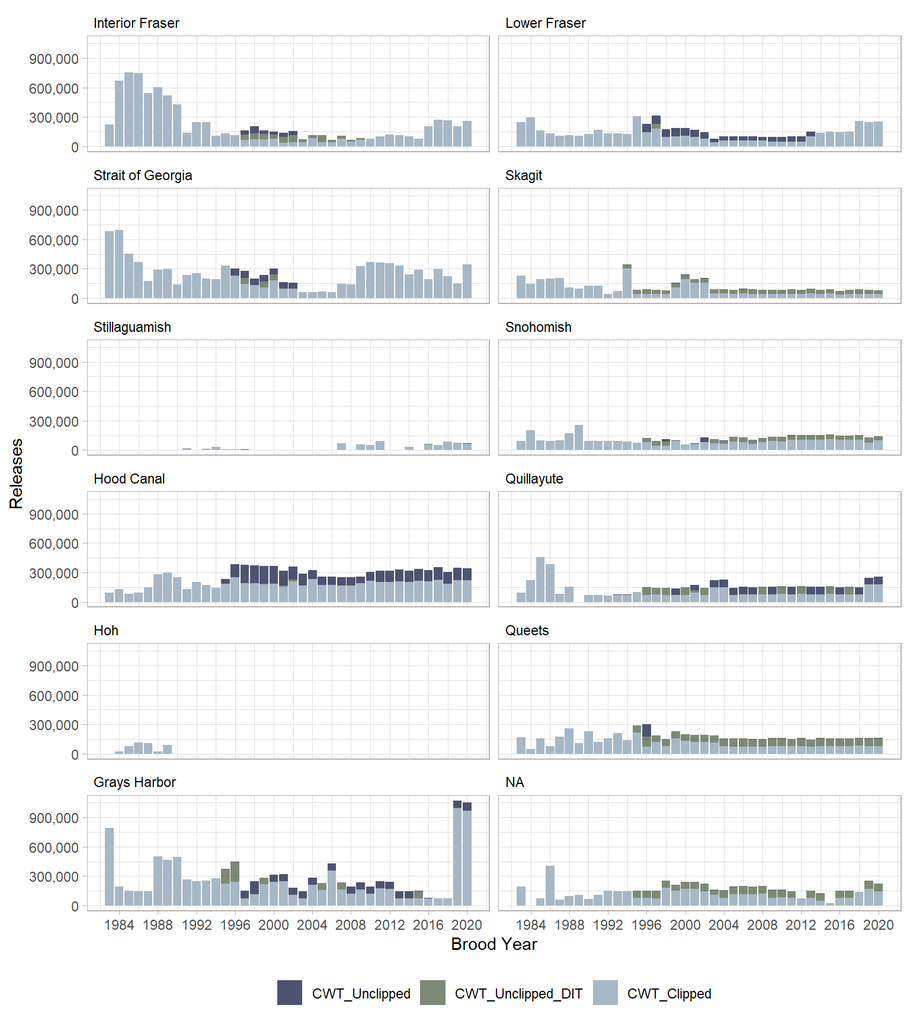

Figure 3.3: Total number of tagged hatchery Coho Salmon smolts released by clip status for each over brood years 1983 through 2020 (data downloaded from RMIS 9-6-2023). “CWT_Unclipped_DIT” refer to tagged fish that are released with an intact adipose fin and are associated with a clipped release group. “CWT_Unclipped” are tagged fish that are unclipped but not associated with another tagged release group. These fish are often associated with new hatchery programs.

### 3.5.3 Total Hatchery Production

Reported hatchery production across the varies widely, from approximately 33,000 on average annually in the Stillaguamish MU , to an average of 5.4 million smolts released into the Strait of Georgia annually (data summarized over brood years 1983-2020). Prior to the advent of mass marking, some hatchery fish were released coded-wire-tagged with their adipose-fin clipped to identify it as a tagged fish, while the remaining fish were released unclipped and untagged. Beginning in 1995, programs began and their associated releases were mass-marked. Now, almost all of the hatchery production released into the in the US are mass-marked.

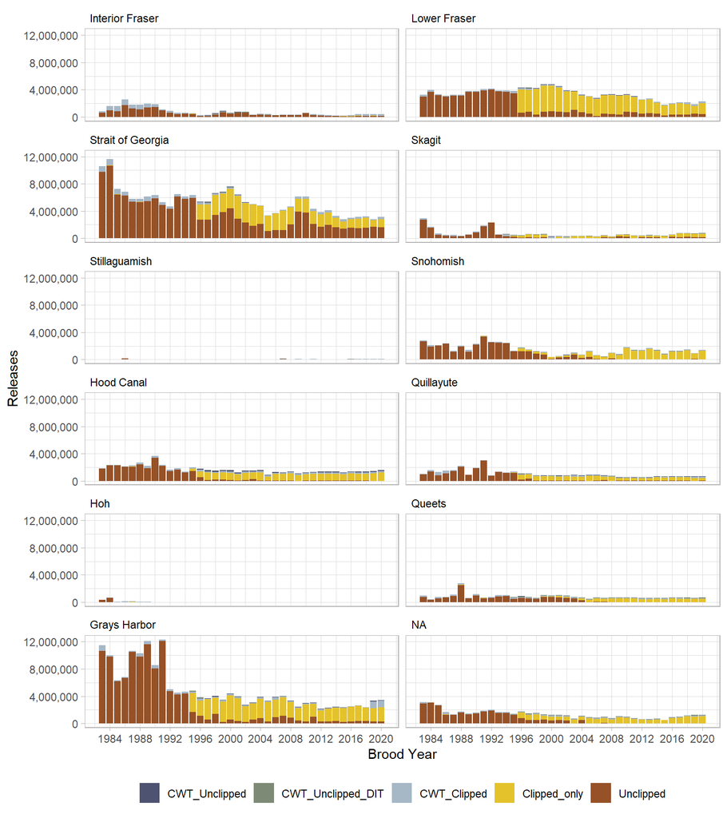

Figure 3.4: Total number of hatchery Coho Salmon smolts released by tag and clip status for each over brood years 1983 through 2020 (data downloaded from RMIS 9-6-2023). “CWT_Unclipped_DIT” refer to tagged fish that are released with an intact adipose fin and are associated with a clipped release group. “CWT_Unclipped” are tagged fish that are unclipped but not associated with another tagged release group. These fish are often associated with new hatchery programs.

# 4 Performance of Abundance Based Management Regime

In an attempt to evaluate the implementation of Abundance Based Management of Coho Salmon stocks of concern under the , summaries on abundance categories, exploitation, and forecast performance are provided below. Catch years summarized include 2004 through 2021 and abundance category and forecast performance summaries are limited to US and Interior Fraser River . A single year of post-season estimates of abundances, fishery exploitation, and escapement is first completed two years following each catch year. For example, an assessment of catch year 2022 will be completed in February of 2024. This report has been referred to as the Annual ER Report. This assessment is presented to the Southern Panel at the ’s Annual Meeting and the reports are posted on the CoTC’s and Southern Panel’s Sharepoint sites. These annual reports can also be found *here*. The best available data and the most current FRAM base period and Terminal Area Management Modules (TAMMs) are used to evaluate the catch year; however, data and the FRAM base period is updated or corrected on occasion. These corrections and additions are carried forward and are included in the post-season evaluations of below, sometimes resulting in changes from the annual reports in estimates of , escapement numbers, and Ocean Age-3 abundances.

## 4.1 Management Unit Post-season Abundances and Categories

Currently all of the except the Lower Fraser River and Georgia Strait have abundance break point criteria and associated for each abundance category. During catch years 2004 through 2021, were considered Abundant 43% of the time, Moderate 24% of the time, and the remaining 32% were in Low status. Interior Fraser was assigned Low status throughout the entire period assessed. US Inside were assigned an Abundant status less often (39% of the time) than US Outside (60%), while they were both assigned Low status nearly at equal rates (26 vs 24%). Over this 18 year period, it appears that Low status was more often assigned post-season beginning with catch year 2015, when 80% were in Low status. During catch years 2015 to present, 50% of the assignments were Low status. The US Strait of Juan de Fuca, Queets, and Grays Harbor were assigned Low status in three or more consecutive catch years beginning with catch year 2015. A summary of abundances and associated categories are provided in the following table and figure.

Table 4.1: Post-season estimates of Ocean Age-3 total abundances and their associated status categories [A = abundant, M = moderate, L= low] by for catch years 2004 through 2021. Management Units in the Abundant category have green highlighted cells, Moderate ones are not highlighted, and those in Low status are highlighted orange.

| PSC_StockName | 2004 | 2005 | 2006 | 2007 | 2008 | 2009 | 2010 | 2011 | 2012 | 2013 | 2014 | 2015 | 2016 | 2017 | 2018 | 2019 | 2020 | 2021 | 2022 |
| --- | --- | --- | --- | --- | --- | --- | --- | --- | --- | --- | --- | --- | --- | --- | --- | --- | --- | --- | --- |
| Canada |  |  |  |  |  |  |  |  |  |  |  |  |  |  |  |  |  |  |  |
| Lower Fraser | 67,385 | 16,843 | 17,386 | 74,841 | 3,471 | 21,561 | 26,647 | 16,809 | 16,819 | 16,872 | 4,107 | 16,863 | 48,764 | 16,802 | 48,897 | 42,572 | 85,395 | 47,539 | 78,093 |
| Interior Fraser | 46,451 | 15,999 | 8,800 | 66,052 | 18,015 | 25,063 | 43,318 | 30,292 | 65,014 | 71,415 | 26,551 | 15,021 | 64,867 | 26,777 | 38,098 | 54,777 | 82,191 | 87,210 | 80,129 |
| Strait of Georgia | 306,419 | 48,138 | 51,218 | 220,554 | 15,361 | 65,107 | 80,449 | 26,576 | 28,866 | 57,344 | 42,333 | 12,750 | 12,356 | 12,636 | 45,757 | 32,727 | 109,574 | 140,232 | 128,444 |
| US Inside |  |  |  |  |  |  |  |  |  |  |  |  |  |  |  |  |  |  |  |
| Skagit | 169,157 [A] | 52,362 [M] | 11,518 [L] | 84,423 [A] | 35,458 [M] | 87,600 [A] | 64,581 [A] | 78,116 [A] | 139,009 [A] | 150,661 [A] | 51,696 [M] | 15,512 [L] | 44,736 [M] | 22,278 [L] | 36,911 [M] | 27,499 [M] | 41,468 [M] | 111,989 [A] | 124,042 [A] |
| Stillaguamish | 66,035 [A] | 30,687 [A] | 10,804 [M] | 51,708 [A] | 16,874 [M] | 30,871 [A] | 16,753 [M] | 61,324 [A] | 60,518 [A] | 78,066 [A] | 49,138 [A] | 5,455 [L] | 15,619 [M] | 6,918 [L] | 30,885 [A] | 16,165 [M] | 24,654 [A] | 42,702 [A] | 59,711 [A] |
| Snohomish | 289,505 [A] | 133,924 [A] | 94,754 [M] | 157,393 [A] | 49,412 [L] | 134,407 [A] | 54,375 [M] | 137,411 [A] | 175,650 [A] | 175,980 [A] | 66,635 [M] | 27,593 [L] | 54,137 [M] | 23,190 [L] | 77,581 [M] | 48,671 [L] | 47,717 [L] | 109,873 [M] | 93,201 [M] |
| Hood Canal | 199,071 [A] | 54,731 [A] | 51,153 [A] | 88,814 [A] | 40,827 [M] | 58,159 [A] | 14,526 [L] | 56,824 [A] | 125,109 [A] | 37,882 [M] | 69,596 [A] | 63,699 [A] | 31,828 [M] | 34,963 [M] | 18,696 [L] | 14,666 [L] | 23,616 [M] | 45,719 [A] | 20,007 [M] |
| US Strait JDF | 21,816 [M] | 10,933 [L] | 4,184 [L] | 8,613 [L] | 3,487 [L] | 16,743 [M] | 20,053 [M] | 11,715 [M] | 12,534 [M] | 9,800 [L] | 13,811 [M] | 4,711 [L] | 8,692 [L] | 5,856 [L] | 5,939 [L] | 5,258 [L] | 9,200 [L] | 22,440 [M] | 18,396 [M] |
| US Outside |  |  |  |  |  |  |  |  |  |  |  |  |  |  |  |  |  |  |  |
| Quillayute | 14,090 [A] | 20,820 [A] | 9,455 [M] | 10,672 [A] | 10,018 [M] | 12,475 [A] | 17,083 [A] | 13,348 [A] | 12,815 [A] | 15,788 [A] | 17,258 [A] | 4,800 [L] | 11,696 [A] | 12,931 [A] | 8,666 [M] | 10,905 [A] | 9,107 [M] | 11,578 [A] | 16,266 [A] |
| Hoh | 5,366 [A] | 8,217 [A] | 2,064 [L] | 4,904 [A] | 3,970 [A] | 12,023 [A] | 11,375 [A] | 12,978 [A] | 8,089 [A] | 9,152 [A] | 9,136 [A] | 2,928 [M] | 5,417 [A] | 6,044 [A] | 3,739 [A] | 5,157 [A] | 5,386 [A] | 7,790 [A] | 11,686 [A] |
| Queets | 13,445 [A] | 12,149 [A] | 8,695 [M] | 6,828 [L] | 7,335 [M] | 18,733 [A] | 20,070 [A] | 15,170 [A] | 9,194 [M] | 9,932 [A] | 12,903 [A] | 2,748 [L] | 6,070 [L] | 6,797 [L] | 3,446 [L] | 3,944 [L] | 5,126 [L] | 5,261 [L] | 17,811 [A] |
| Grays Harbor | 68,872 [A] | 73,009 [A] | 26,881 [L] | 34,718 [L] | 51,708 [M] | 113,275 [A] | 117,353 [A] | 86,208 [A] | 103,923 [A] | 80,323 [A] | 152,912 [A] | 31,714 [L] | 35,331 [L] | 37,344 [L] | 60,777 [A] | 50,994 [M] | 31,581 [L] | 77,315 [A] | 79,356 [A] |

Estimated post-season ocean age-3 cohort abundances for the are depicted below. Abundances for BC and US Inside tend to be synchronous, with above- or below-average abundances occurring in the same years (e.g., high in 2001, low in 2006). Outside are less synchronous and years with high abundances for Grays Harbor don’t necessarily correspond to high abundances for other .

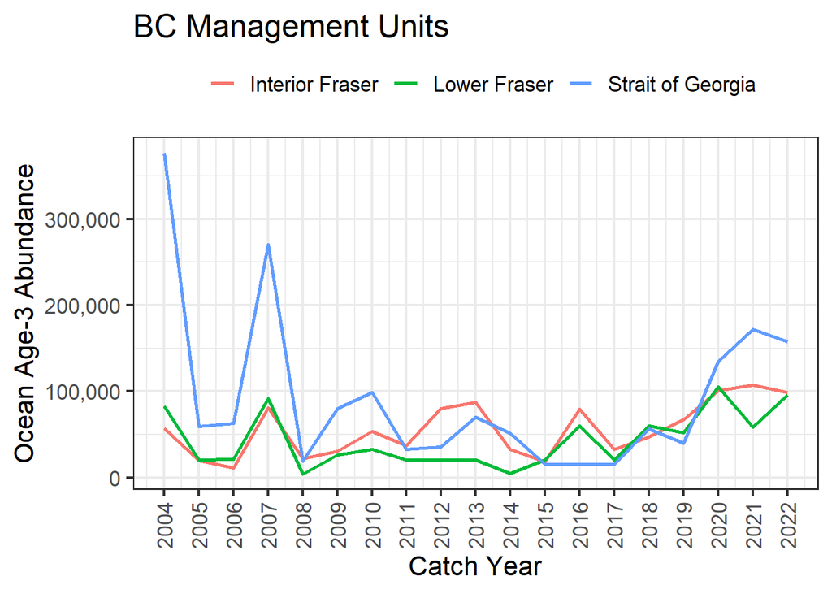

Figure 4.1: Estimated Post-season Ocean Age-3 Abundances of BC Coho Salmon Management Units

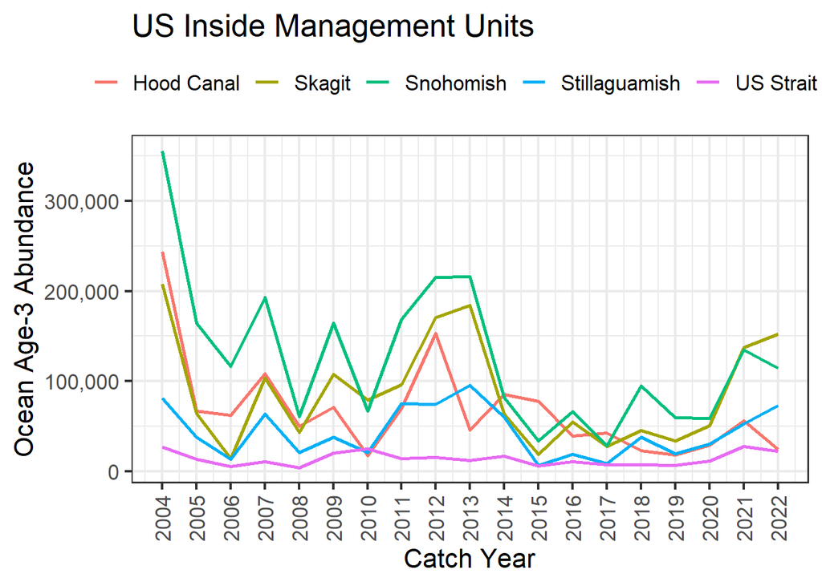

Figure 4.2: Estimated Post-season Ocean Age-3 Abundances of US Inside Coho Salmon Management Units

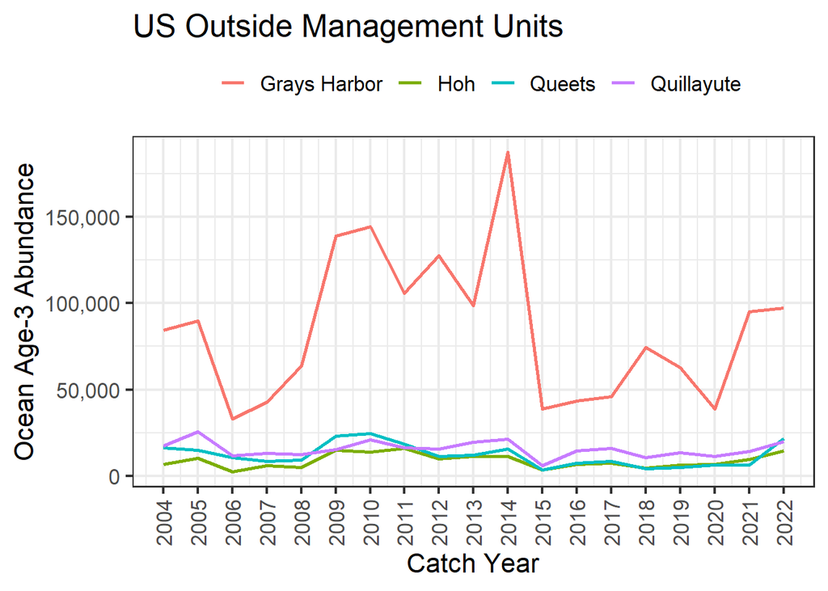

Figure 4.3: Estimated Post-season Ocean Age-3 Abundances of US Outside Coho Salmon Management Units

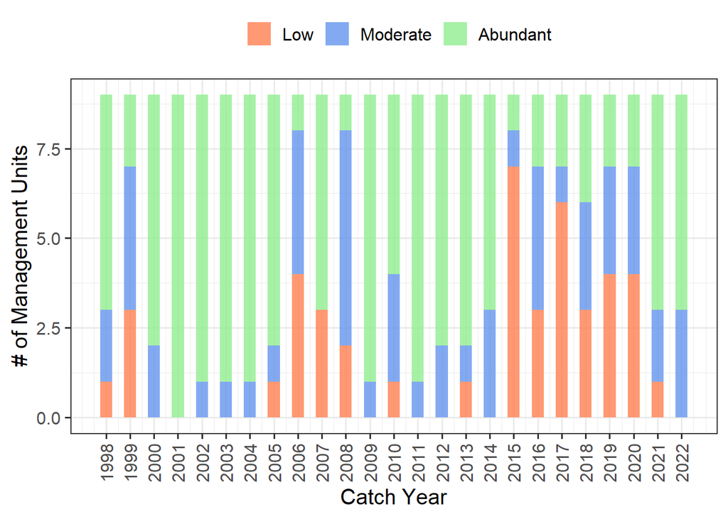

Figure 4.4: Summary of the number of in each abundance category each year, based on post-season assessments of Ocean Age-3 Abundances.

### 4.1.1 Fishery Exploitaion Rate Overview

**Canadian**

Over catch years 2011 through 2021, the Canadian experienced varying from a low of 6.5% by the Strait of Georgia in 2021 to a high of 56.8% by the Lower Fraser in 2014. The averaged 21.5% over all years for the Lower Fraser River , followed by the Interior Fraser at 16.9%, and Strait of Georgia at 16.8%.

**US Inside**

US Inside were the lowest for the US Strait of Juan de Fuca at 3.0% in 2016 and were the highest at 68.3% for the Hood Canal in 2014. The averaged 48.5% over all years for the Hood Canal , followed by the Skagit at 39.6%, Snohomish at 23.8%, Stillaguamish at 21.3%, and US Strait of Juan de Fuca at 10.2%.

**US Outside**

(ToDo - need to move Canadian MUs to top of table and bold the values when the ERs exceeded the caps)

Total exploitation rates by , catch years 2011 through 2021.

| PSC_StockName | 2011 | 2012 | 2013 | 2014 | 2015 | 2016 | 2017 | 2018 | 2019 | 2020 | 2021 | 2022 |
| --- | --- | --- | --- | --- | --- | --- | --- | --- | --- | --- | --- | --- |
| US Inside |  |  |  |  |  |  |  |  |  |  |  |  |
| Skagit | 43.8% | 33.3% | 43.1% | 52.0% | 62.7% | 19.9% | 9.4% | 48.4% | 48.2% | 42.6% | 32.6% | 25.6% |
| Stillaguamish | 18.5% | 25.4% | 22.6% | 27.1% | 46.6% | 16.5% | 11.8% | 22.5% | 20.3% | 12.6% | 10.6% | 9.9% |
| Snohomish | 18.9% | 25.6% | 28.5% | 30.6% | 53.6% | 18.5% | 21.5% | 25.1% | 17.2% | 10.6% | 11.2% | 8.1% |
| Hood Canal | 57.1% | 58.6% | 57.7% | 68.3% | 58.7% | 40.1% | 35.6% | 57.3% | 46.1% | 28.7% | 24.8% | 54.1% |
| US Strait JDF | 8.4% | 12.1% | 13.7% | 16.8% | 18.1% | 3.0% | 5.6% | 7.9% | 12.0% | 7.1% | 7.1% | 7.7% |
| US Outside |  |  |  |  |  |  |  |  |  |  |  |  |
| Quillayute | 39.6% | 54.4% | 55.3% | 57.1% | 47.1% | 18.4% | 42.3% | 29.7% | 37.2% | 17.2% | 3.7% | 18.8% |
| Hoh | 39.2% | 50.8% | 69.0% | 51.8% | 39.2% | 7.9% | 42.9% | 34.4% | 56.6% | 49.2% | 17.9% | 30.4% |
| Queets | 40.1% | 49.8% | 38.2% | 42.2% | 36.3% | 24.9% | 22.9% | 35.9% | 41.3% | 41.8% | 9.7% | 30.1% |
| Grays Harbor | 38.9% | 47.1% | 44.4% | 44.9% | 48.5% | 11.5% | 32.3% | 21.9% | 39.6% | 28.6% | 22.4% | 28.8% |
| Canada |  |  |  |  |  |  |  |  |  |  |  |  |
| Lower Fraser | 23.6% | 17.9% | 27.6% | 56.8% | 42.0% | 12.4% | 12.4% | 12.0% | 14.0% | 9.6% | 7.7% | 10.3% |
| Interior Fraser | 14.3% | 14.5% | 20.6% | 35.3% | 24.0% | 9.2% | 9.7% | 15.3% | 20.0% | 13.4% | 9.5% | 12.4% |
| Strait of Georgia | 16.5% | 15.9% | 25.8% | 32.1% | 30.1% | 9.9% | 9.7% | 14.3% | 16.2% | 7.4% | 6.5% | 8.8% |

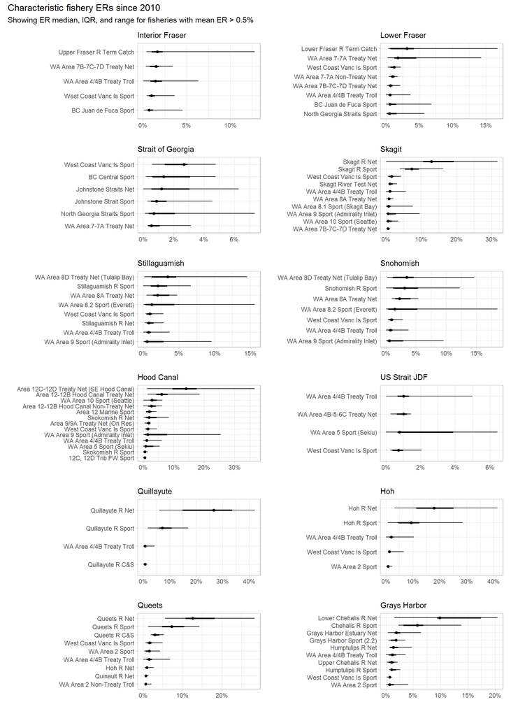

### 4.1.2 Forecast Performance

Forecasts are integral to Coho Salmon management in the Pacific Northwest. These forecasts, as described earlier, are used in pre-season assessments to determine allowable fishing mortality on stocks of concern. In the absence of in-season management controls, forecasts that are too high may yield higher than agreed to exploitation of management units of concern. Forecasts that are too low may yield losses in fishing opportunities.

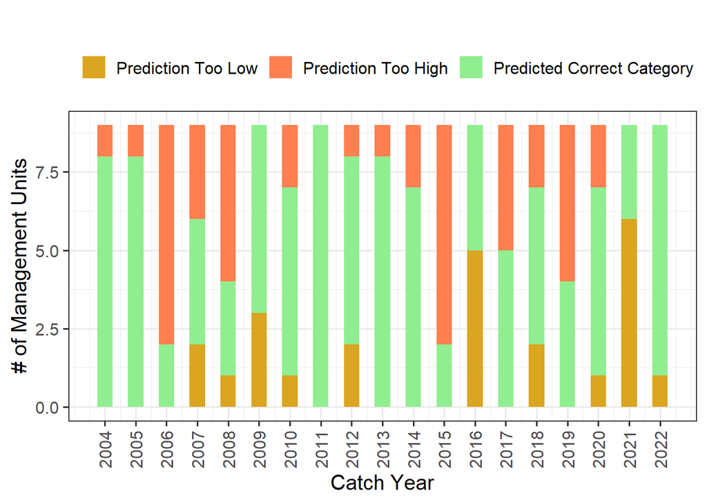

Figure 4.5: Comparison of pre-season abundance to post-season abundance based on whether the abundance category was correctly predicted, for all MUs.

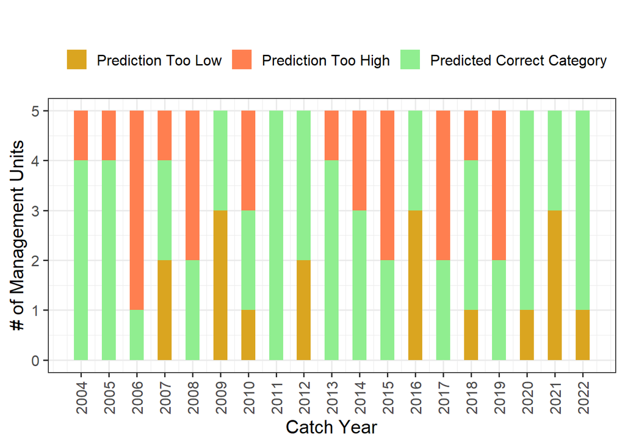

Figure 4.6: Comparison of pre-season abundance to post-season abundance based on whether the abundance category was correctly predicted, for US Inside MUs.

Forecasts for the US Outside performed better, on average, than the US Inside forecasts of abundance categories. Pre-season forecasts for the four US Outside over catch years 2004 through 2021 were within the abundance based categories assigned post-season 64% of the time, too high 25% of the time, and too low 11% of the time. The forecasts for catch years 2005, 2009-2011, and 2014 were very good, resulting in no change in abundance categories from pre- to post-season estimates of abundance. Forecasting performance was poor for catch years 2006, 2015, and 2021. Forecasts were more often correct (72% of the years) for the Hoh and Quillayute , followed by the Queets (61%), and least correct for the Grays Harbor (50% of the years).

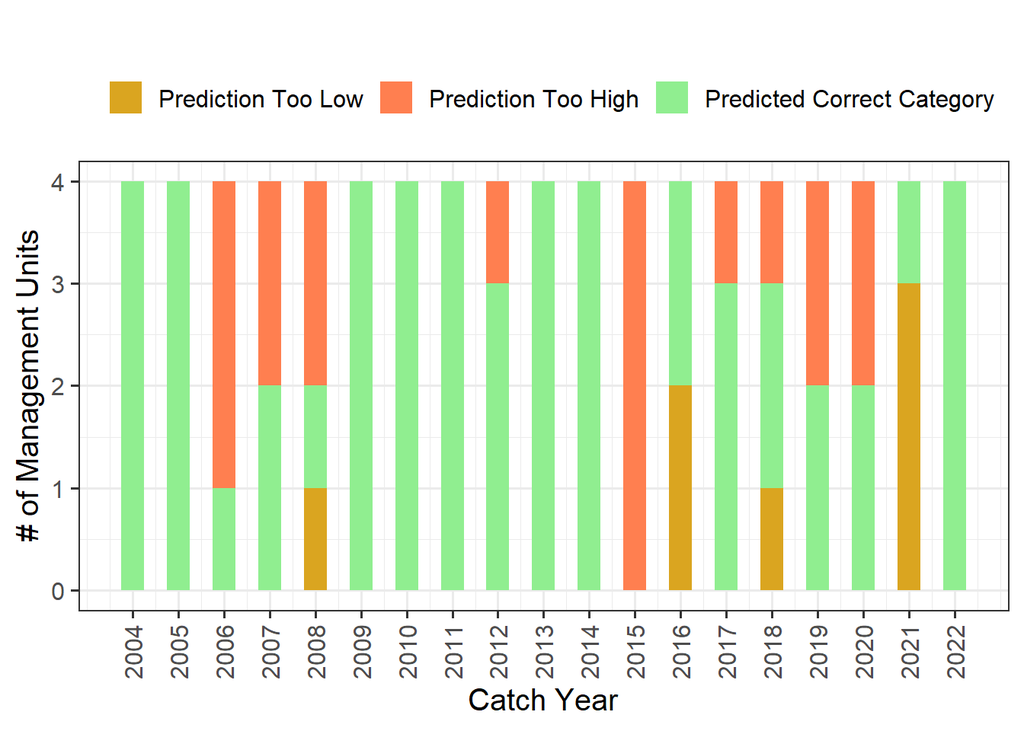

Figure 4.7: Comparison of pre-season abundance to post-season abundance based on whether the abundance category was correctly predicted, for US Outside MUs.

## 4.2 Management Unit Descriptions and Assessment of Performance

### 4.2.1 Skagit

This description was prepared by U.S. members of the Coho Technical Committee.

#### 4.2.1.1 Biological and Geographic Description

The Skagit is one of the US Inside (refer to figure of inside MUs). This is comprised of all wild Coho Salmon that originate from the Skagit Basin. The Skagit River consists of Coho Salmon in the Skagit River Basin and its major tributaries, the Baker, Sauk-Suiattle, and Cascade Rivers (MU Figure - fix Oak Harbar spelling). The Skagit River is located in Northern Puget Sound midway between Seattle, Washington and Vancouver, British Columbia. The Skagit Basin drains the northern Cascade Mountains, flowing westward to Puget Sound and enters Puget Sound southwest of the city of Mt Vernon after splitting into to two similar-sized channels several miles above tidewater (Haymes 2008). The basin area accessible to anadromous salmonids downstream of the Skagit River reservoir system is 1,918 mi2 [4,968 km2] (Volkhardt et al. 2007). It drains Puget Sound’s largest basin, with an area of nearly 4,000 mi2 and an average discharge of over 16,000 cfs (one-third of the freshwater inflow to Puget Sound). It is the second largest river system in the state of Washington in terms of annual discharge, after the Columbia River. The Skagit River contains 162 miles of mainstem river, with its origin in the Coveole Mountains of British Columbia.

The mainstem Skagit and Sauk rivers have two periods of peak flow, first during winter rain and snowmelt events, and the second during peak snow runoff in spring and early summer. The smaller tributaries are largely rain-fed, and have peak flow events during the winter rain season. Average annual rainfall is 35 inches [89 cm] per year at Mt. Vernon in the lower valley, increasing to up to 180 inches [457 cm] per year in the upper basin. Three large reservoirs in the upper Skagit River drainage (the first located at river mile (RM) 96.6 [KM 155.5] from the estuary) and two in the Baker River drainage provide flood control and hydroelectric generation. Upriver fish passage is only provided at the Baker Reservoir system, via a trap and haul system located at a diversion dam 0.3 miles [0.5 km] upstream of the Baker River confluence with the Skagit River at a diversion dam. Puget Sound Energy completed construction of this new, enhanced fish trap below Lower Baker Dam to capture migrating adult salmon for upstream transport around both Baker River dams. Construction on a juvenile salmon downstream fish trap, a floating surface collector, was completed in 2008 behind the upper Baker River Dam. A similar fish trap is under construction on Lake Shannon, below Lower Baker Dam.

In the 3,910 mi2 [10,127 km2] watershed, 19% is owned by private and Washington State entities, 24% is managed by the Mt Baker-Snoqualmie National Forest, 44% by the North Cascade National Park and Recreation Area, and 13% is located within British Columbia (Beechie et al. 1994). The Skagit Bay estuary is partially enclosed by Whidbey Island to the west and Camano Island to the south. Relatively minimal development is located directly adjacent to the estuary in most areas. The WDFW Skagit Wildlife Area fronts the southeastern edge of Skagit Bay at the river mouth, and the northeastern end of the bay is bounded by the Swinomish Indian Reservation.

Recreational, conservation, and commercial forest activities are prevalent in the mid- and upper basin reaches. The lower and mid-basin areas have significant habitat impacts from agricultural and residential/commercial development in the floodplain and surrounding uplands. Extensive flood control structures degrade the salmonid habitat in the floodplain and estuary, with over 60 miles [97 km] of historically available slough and tributary habitat lost from the construction of flood control structures alone. The rapidly growing city of Mount Vernon, located adjacent to the Skagit River at RM 11 [KM 18] from the estuary, is the largest urban center in the . Other moderate-sized communities located in the are Burlington and Sedro Woolley, also located in the Skagit River floodplain a few miles upstream of Mt Vernon. Human population densities decline upstream of Sedro Woolley, though smaller, residentially-oriented communities are scattered along the Skagit mainstem upstream to the town of Newhalem at RM 96 (KM 154]. The Sauk River valley has only one significant population center, Darrington, located at RM 22 [KM 35] from the Sauk/Skagit confluence, though residential development and some agricultural activity is scattered along the valley floor.

In the upper reaches of the Skagit watershed, the land is primarily forested and moderately steep gradient; the main land use in this area is forestry. Below the confluence with the Sauk, the valley broadens and flattens and is used extensively for agriculture.

A major limiting factor on Skagit Coho Salmon production is floodplain diking and hydromodification, which has reduced distributary slough area by about 64%, and off-channel slough area by about 45% (Beechie et al. 1994). This has reduced Coho Salmon smolt production by an estimated 300,000 smolts per year (Puget Sound Salmon Stock Review Group 1992). Improperly placed culverts have also restricted access to a significant amount of tributary spawning and rearing habitat. Poor water quality and abnormally high flows, which are caused by agricultural practices and clear-cutting, have reduced production in much of the lower basin (Beamer et al. (2000)).

There are currently two recognized Coho Salmon populations in the system, Baker and Skagit (WDFW and WWTIT 1994). The Baker run historically entered the system somewhat earlier than the Skagit run, but the two populations are nonetheless managed as a single MU because: 1) there is considerable overlap in run timing, which would make it difficult to manage for separate escapement goals for each run; and 2) hatchery practices have so crossbred Baker and Skagit Coho Salmon that it is questionable whether a genetically separate Baker run population exists anymore (WDFW and WWTIT 1994).

Skagit Coho Salmon belong to the larger Puget Sound/Strait of Georgia Coho Salmon evolutionarily significant unit (ESU) (Weitkamp et al. 1995). This ESU is currently a species of concern under the US Endangered Species Act (Ford 2011).

Numerous salmon hatchery facilities exist within the Skagit Basin, including small and large operations (MU figure). Below is a list of the larger Coho Salmon programs that are operating in the Skagit Basin.

- The WDFW operates the Marblemount Hatchery on the Cascade River at RM 0.5 at the confluence with Clark Creek (MU figure). The Cascade River is a tributary to the Skagit River at RM 78. Marblemount Hatchery was constructed in 1946 and currently rears Skagit spring, summer, and fall Chinook Salmon; Skagit Coho Salmon; Skagit Steelhead; and Ross Lake Rainbow Trout (Washington Department of Fish and Wildlife 2003a). The Coho Salmon program is operated as an isolated harvest program with an annual production goal of 250,000 smolts to be released on station, 45,000 fish to net pen projects (Oak Harbor and Roche Harbor), 100,000 fish to Skagit System Coop (Swinomish Tribe), and 13,000 eggs to educational and volunteer cooperatives. Its current purpose is to provide harvest opportunity for non-tribal sport and commercial fishers and tribal fishers (Washington Department of Fish and Wildlife 2003a). This program collects adult broodstock on-site, and has egg incubation and rearing facilities. Within the Skagit approximately 77% of the total hatchery fish reported to have been released for brood years 1983 through 2020 has been from the Marblemount Hatchery.
- A fish culture facility has also been in operation on the Baker River since the early 1970s, producing Sockeye, Rainbow Trout, and Coho Salmon (**WDFW_and_PSE_2003?**). Puget Sound Energy completed construction in 2010 of a new hatchery on the Baker River near the upper Baker Dam. Coho Salmon fry from this program are transported to net pens on Lake Shannon and they are later released as smolts into the Baker River and both reservoirs. This Coho Salmon program is operated as an integrated harvest and research program with an annual goal of releasing 60,000 smolts. The purpose of this program is to supply experimental and research smolts for gulper efficiency testing, serve as an indicator stock for wild Skagit Coho Salmon, and supplement natural production in the basin.
- Coho Salmon are also reared in net pens within the Oak Harbor Marina (Washington Department of Fish and Wildlife 2003b). This Coho Salmon program is a marine net pen program operated by WDFW and local sport angling groups and usually receives stock from the Marblemount Hatchery and is operated as an isolated program with an annual goal of releasing 30,000 smolts. The purpose of this program is to provide harvest opportunity for sport and commercial fishers.

#### 4.2.1.2 Management Framework

##### Objectives

Under the Comprehensive Coho Management Plan, Skagit River wild Coho Salmon is the primary (or key) and hatchery production are either secondary (Swinomish Channel, Oak Harbor Pens) or auxiliary (Marblemount Hatchery, Baker River Hatchery) (Comprehensive Coho Workgroup 1998). Under this plan, primary are controlling units in the sense that predefined management actions will be undertaken under specified abundance conditions, auxiliary are those managed to meet or exceed a minimum escapement, and secondary units are passively managed in mixed stock fisheries. Therefore, Skagit River Coho Salmon are managed for natural (wild) production. * JJ question - So, hatchery fish spawning in the river count towards the wild escapement goal, or not? This type of specificity should be spelled out for each MU very clearly.* While there is hatchery production within the system, fisheries are constrained to meet the natural escapement objectives. Thus, there are frequently significant surplus returns to the Marblemount Hatchery on the Cascade River. There have been fisheries in the Skagit terminal area targeted at hatchery Coho Salmon, but these have been sporadic, and have been confined to small areas (e.g., the creek immediately downstream of the hatchery, Swinomish Channel from 1986–1991, and Oak Harbor from 1994–1996).

Skagit Coho Salmon are also a primary for Puget Sound under the FMP (Pacific Fishery Management Council 2013). Other primary in this region are Strait of Juan de Fuca, Hood Canal, Snohomish, Stillaguamish, and South Puget Sound (hatchery) Coho Salmon (Pacific Fishery Management Council 2013). The ’s conservation objectives for these are based on the Puget Sound Salmon Management Plan, which includes management objectives and long-term goals for these stocks as developed by representatives from federal, state, and tribal agencies.

In Puget Sound, conservation objectives for specific stocks are based on either maximum sustainable production for stocks managed primarily for natural production or on hatchery escapement needs for stocks managed for artificial production. The original conservation objectives were developed by a State/Tribal Management Plan Development Team following the Boldt Decision (384 F. Supp. 312 [W.D. Wash. 1974]) with the goal for natural spawning stocks defined as “the adult spawning population that will, on the average, maximize biomass of juvenile outmigrants subsequent to incubation and freshwater rearing under average environmental conditions”. The method used to develop the objectives was based on assessment of the quantity and quality of rearing habitat and the number of adult spawners required to fully seed the habitat. Some objectives have subsequently been modified by the US District Court Fisheries Advisory Board and later determinations of the WDFW/Tribal Technical Committee. However, annual natural management objectives may be adopted by the and authorized by NMFS which vary from the fisheries management plan (FMP) conservation objectives if agreed to by WDFW and the treaty Indian tribes under the provisions of US versus Washington (384 F. Supp. 312 [W.D. Wash. 1974]) and subsequent US District Court orders.

In 2009, the adopted annual management objectives for Puget Sound Coho Salmon as recommended by WDFW and tribal co-managers under provisions of US versus Washington. The annual objectives were based on the categorical status and associated maximum limits. The formally adopted management objectives for Puget Sound Coho Salmon in November 2009, which were consistent with objectives, and in 2010 these new objectives replaced the longstanding FMP spawning escapement objectives.

The current / ceilings for the Skagit natural Coho Salmon population are provided in the table below. The current corresponding ocean abundance reference points are 62,500 and 22,857 adult Coho Salmon (Pacific Fishery Management Council 2013). Prior to adoption of -based management for this in domestic and international management processes, natural Skagit River origin Coho Salmon were managed for a fixed escapement goal of 30,000. This goal was derived from a freshwater juvenile carrying capacity model (Zillges 1977).

Table 4.2: Current Skagit ocean abundance reference breakpoints and maximum total by and status categories.

| **Status(PSC/)** | **Ocean Abundance** **Reference Breakpoint** | **Total Exploitation Rate** |
| --- | --- | --- |
| Low/Critical | < 22,858 | Up to 20% |
| Moderate/Low | 22,858 – 62,500 | 21% – 35% |
| Abundant/Normal | > 62,500 | 36% – 60% |

##### Stock Assessment

###### Indicator Stocks

The Skagit MU has both hatchery and wild Coho Salmon indicator stock programs. Wild Yearling Coho Salmon are captured, coded-wire-tagged, and released within the Skagit Basin (Litz 2023). These releases are currently used as a marine survival rate indicator for the wild stock. The Skagit hatchery stock releases from Marblemount Hatchery and the tagged wild stock releases are used as indicator stocks. Coho Salmon released from Marblemount Hatchery have been double index tagged starting with brood year 1994.

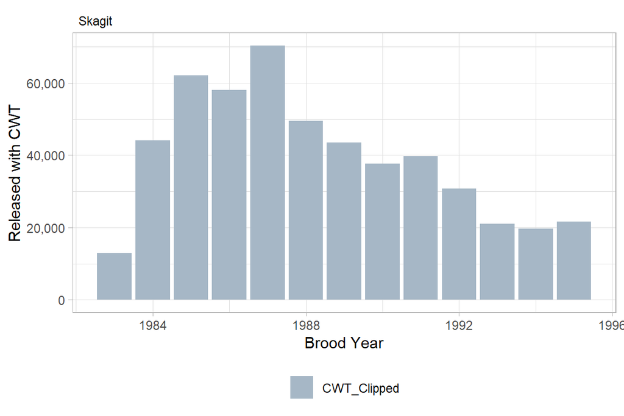

Figure 4.8: Number of wild fish caught, tagged, and released by clip status, within the Skagit MU over brood years 1983 through 2020.

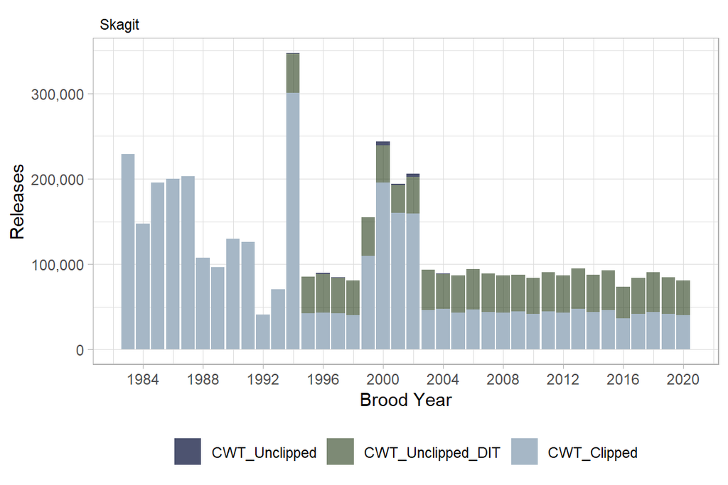

Figure 4.9: Total number of coded-wire-tagged hatchery Coho Salmon released, by clip status, within the Skagit MU for brood years 1983 through 2020.

###### Forecast Methods

Since 1996, WDFW and tribal biologists have developed forecasts of wild Coho Salmon run size for all primary and most secondary in Puget Sound and the Washington coast (Zimmerman 2013). These annual forecasts are described in the ’s Preseason Forecast I document available each February [e.g., Pacific Fishery Management Council (2013); www.pcouncil.org]. These forecasts rely on estimates of wild Coho Salmon production (i.e., smolts) paired with estimates of marine survival. Wild Coho Salmon production estimates for each of the primary and secondary in Puget Sound were derived from results of juvenile trapping studies conducted in the Skagit, Stillaguamish, Snohomish, Green, Nisqually, and Deschutes rivers as well as in tributaries to Lake Washington and Hood Canal. Analyses of these long-term data sets have demonstrated that wild Coho Salmon smolt production is limited by a combination of factors including seeding levels (i.e., escapement), environmental effects (flows, marine derived nutrients), and habitat degradation (Zimmerman 2012).

Estimates of wild Coho Salmon production in the Skagit Basin are based on catch of wild Coho Salmon smolts in a juvenile trapping program on the lower mainstem Skagit River (Litz 2023). WDFW operates a scoop-and-screw trap combination in the lower Skagit River mainstem, located at RM 17 from the river mouth. Trapping began in 1990 and the juvenile trap is calibrated using recaptures of wild yearling Coho marked and released from an upstream tributary (Mannser Creek, RM 35). Coho Salmon abundance is calculated using a Petersen estimator with Chapman modification (Seber 1973; Volkhardt et al. 2007). Estimated smolt production has been quite consistent in the Skagit , averaging 1.1 million smolts annually from 1990 to 2022 (Figure 4.10). Smolt production has varied from a low of 426,963 in 2008 to a high of 1,885,000 in 2002 and has exceeded 1,000,000 smolts in 20 of the last 33 years. Freshwater productivity (smolts/female) during this period was a function of Coho spawner abundance. The smolt-spawner function derived based on Skagit Coho Salmon estimates is comparable to systems with census counts, lending further credibility to the Skagit juvenile and adult estimates.

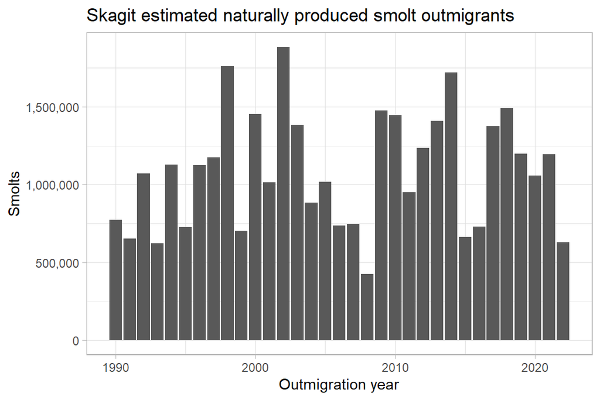

Figure 4.10: Estimated number of Skagit MU wild Coho Salmon smolts outmigrants, years 1990 through 2022

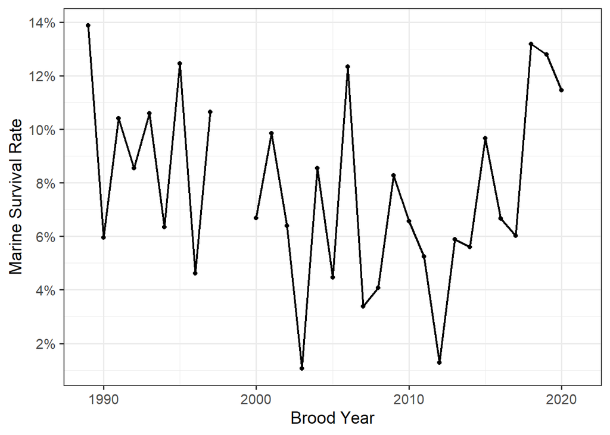

Figure 4.11: Estimated marine survival rates for Baker River Coho Salmon, (data provided by M. Litz, WDFW).

**Most Recent Abundance Forecast and Methods**

This information is available in the ’s 2024 Preseason Report 1 (Pacific Fishery Management Council 2024c) and (Litz 2024).

This forecast was based on a prediction of total (Baker wild + Skagit wild) smolt to ocean age-3 survival. Note that this forecast is not based on the Baker River wild indicator survival. Instead, the total survival was calculated assuming that the ratio of total wild terminal run size to Baker River wild indicator run size is equal to the ratio of total pre-terminal wild catch to Baker River pre-terminal wild catch. Using that ratio, total wild run size was calculated utilizing pieces of the Skagit co-manager run reconstruction, , and . Due to the large uncertainty surrounding how ocean conditions would influence the survival of 2023 outmigrants, ’s alternative Coho Salmon forecast for Baker River wild indicator survival in the report ‘2024 Wild Coho Forecasts for Puget Sound, Washington Coast, and Lower Columbia’ relying on generalized additive model methodology was also incorporated into the final agreed upon forecast (Litz 2024).

###### Escapement Monitoring

Escapements to the Baker system are counted at the Baker River trap. Hatchery fish are distinguished by ad-clips. Wild fish returning to the Baker, including those that carry , are not ad-clipped.

Natural Coho Salmon escapement estimation efforts in the Skagit have a long and problematic history and are a textbook example of the challenges of estimating Coho Salmon escapements to large watersheds (Haymes 2008). An early effort at estimating a basin-total Coho Salmon escapement to this was a 1961 Washington Department of Fisheries (WDF, now Washington Department of Fish and Wildlife, or WDFW) mark-recapture (M/R) escapement study. This study focused on deriving a Pink Salmon escapement estimate for that year, but also tagged returning adult Coho Salmon to develop a Coho Salmon escapement estimate from spawning ground tag recoveries (Stockley 1963). The Coho Salmon escapement estimate derived from this study (116,726) was confounded by low numbers of tagged Coho Salmon adults (289), limited tag recovery effort during the Coho Salmon spawning season, low numbers of tags recovered, and poor distribution of the tag recoveries (68 tags, of which 60 came from the Baker Lake adult trap, a drainage which accounts for a small fraction of the total natural Coho Salmon escapement to this ).

A more serious attempt to directly estimate natural Coho escapements in the northern Puget Sound river basins was made in 1976 and 1977 when two major M/R escapement studies were conducted to estimate the Coho and Chum Salmon escapements to these rivers (Eames et al. 1983). The results of these studies provided the information needed for implementation of a Base-Year Index escapement estimation approach for the rivers in the Puget Sound region. The Base-Year Index escapement estimation approach was selected by the Washington Department of Fisheries (WDF) for annual estimation of Chum, Pink, and Coho Salmon escapements for these river basins because the method utilized visual spawning survey observations in lieu of expensive annual M/R studies.

However, questions soon arose about the accuracy of escapement estimates produced by the index-base year approach. A new M/R escapement study for the Skagit River was attempted by the treaty tribes in 1984 to generate a comparative escapement estimate, but an inadequate number of Coho Salmon were tagged to develop an estimate (Hayman and Beamer 1987). An alternative approach was also examined for the 1984 escapement using the ratio of wild to hatchery-origin Coho Salmon observed in the lower river test fisheries multiplied by the hatchery return to Marblemount Hatchery to estimate the wild escapement (a “reverse form” Petersen M/R-type estimate), which produced an estimate considerably higher than the Base-Year Index approach for that year, 100,000 vs. 35,600 (Hayman and Beamer 1987).

In the 1986 to 1990 time period, M/R-based natural Coho Salmon escapement estimation studies were again conducted in the Skagit Basin by the treaty tribes (Conrad et al. 1997, 1998a, 1998b, 1998c). Returning adult Coho Salmon were captured by beach seine in the lower river, jaw tagged, and the tags subsequently recovered in in-river test fisheries, hatchery, dam or tributary fish traps, or spawning ground surveys. Peterson and Darroch analyses were conducted on the jaw tag recoveries to estimate the escapement in each of these years and compared against Index Spawning Redd-based estimates, estimates based on the proportional contribution of hatchery origin Coho Salmon to the total escapement, and the traditional Base-Year Index method that were conducted in the same years. The M/R-based escapement estimates were up to 575% higher than the Base-Year Index estimates for the same time period. The estimates based on proportional contribution of hatchery Coho Salmon to the Skagit escapement conducted in the same time period were also considerably higher than the Base-Year Index approach. These results were also supported by the observed smolt production estimates in this same time period which indicated the escapement estimates generated by the Base-Year Index approach were too low to produce the observed juvenile production.

In the 1990s another escapement estimation approach was developed for Skagit Coho Salmon that uses the observed marine survival rate of tagged Baker Lake origin wild Coho Salmon for each year multiplied by the parent year Skagit basin smolt out-migration to produce an estimate of total adult recruitment, which is multiplied by (1 - the Baker Wild -recovery fishery ) to generate the escapement estimates (Seiler et al. 1995). These estimates were also typically considerably higher than the Base-Year Index estimates.

There are a number of reasons for the differences observed in the escapement estimates derived by the various methods discussed above. The Base-Year Index escapement formula for the Skagit has an inherent negative bias due to a decision made by WDF management biologists following completion of the 1977 mark-recapture escapement study to select a value approaching the lower bound of the 95% confidence interval from the M/R study results as the “base year” escapement estimate [WDF_1985]. The 29,200 value that was selected by the WDF managers is considerably lower than the M/R study point estimate of 43,000, which has a 95% confidence interval (CI) of 25,211–148,464. This decision was based on concern about the limited number of marks recovered in the M/R study, and the subsequent possibility of positive bias in the M/R-based estimate. Further uncertainty in the 1977 M/R estimate was highlighted by a re-analysis of the 1977 M/R study data by the Northwest Indian Fisheries Commission (NWIFC) that produced a point estimate of 110,758, with a 95% CI of 4,564–216,952 (Conrad n.d.).

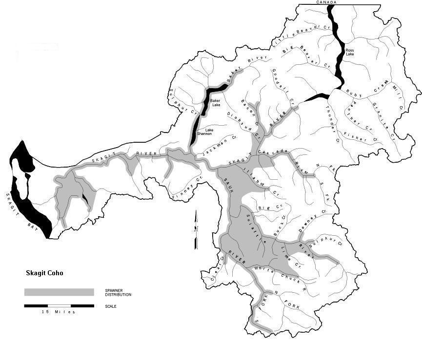

Figure 4.12: Spawner distribution of Coho Salmon in the Skagit River Basin.

###### Fishery Monitoring

A fundamental requirement of abundance-based Coho Salmon management under the is that all fishery impacts on individual be annually monitored with respect to both number of fish caught and CWTs. This requires basic reporting of total impacts by fishery and the capacity to estimate each fishery’s -specific impacts. Total fishing mortalities for each must be estimated to enable managers the ability to evaluate the annual relative to the -prescribed impact limits.

Assessments of total fishing mortalities for each must include both directed and incidentally-landed catch as well as estimates of non-landed mortalities. These estimates may be obtained through monitoring programs or, in some cases, generated through the use of algorithms built into the . Monitoring programs may involve test fisheries or data collected directly from fishers (e.g., through creel survey interviews, and other fisher-reported techniques, such as log books or fish-tickets). Estimation of non-landed fishing mortality requires annual estimates of encounter rates by fishery and gear.

Mark-selective fisheries have been intensively monitored to collect data to estimate key parameters characterizing MSF fisheries and their impacts on unmarked salmon. Sampling activities include dockside creel sampling, on-water observation, and a Voluntary Trip Report (VTR) system. Data collected from this sampling is used to estimate key parameters necessary to manage fisheries and integrate MSFs in the FRAM model. These parameters include: mark rate of the targeted Coho Salmon populations; total number of Coho Salmon harvested or released by mark-status, the coded-wire-tag stock composition of landed Coho Salmon, and total mortality of marked and unmarked Coho.

Management impacts for each are generally evaluated using the coast-wide system. This system manages information on the release and recovery of . The volume of tags recovered for a given will depend on tagging rates, marine survival rates, exploitation and escapement rates, and sampling rates in fisheries and escapements. A recent review of CWT methods (Pacific Salmon Commission Coded Wire Tag Workgroup 2008) recommends target sampling rates of 20% for the landed catch and 20% for escapements, with a minimum of 10 tags collected in each fishery or escapement stratum.

Post-season estimates are also generated using the Post-Season FRAM Model. Post-season estimates of catch and escapement are entered into the updated FRAM model with the same fishery regulation and effort package used for preseason modeling to generate post-season estimates.

##### Enhancement

There are numerous hatchery programs releasing Coho Salmon within the Skagit Basin. Since brood year 1983 to 2020, the largest ones include Marblemount, Baker Lake, Puget Sound Energy, and Swinomish Channel PD Hatchery programs. Over this time period approximately 690,000 Coho Salmon have been released annually on average. Marblemount Hatchery made up the majority (77%) of all releases, followed by Baker Lake Hatchery (9%), Puget Sound Energy (7%; ended with 2009 brood), and Swinomish Channel PD (2%; ended with 1990 brood). Prior to the implmentation of mass marking, total hatchery production within the of brood years 1983–1994 were highly variable, ranging from a high of three million fish released from brood year 1983 to a low of 380,000 fish from brood year 1988 (Figure 4.13) (Pacific States Marine Fisheries Commission 1977). With the advent of technology to automatically remove adipose fins and/or insert using mobile “tagging trailers”, mass marking of hatchery fish was implemented for Coho Salmon in the mid-1990s (Selective Fishery Evaluation Committee 1999). Mass marking allows mark selective fisheries (MSF) for Coho Salmon in which marked hatchery fish can be retained and unmarked wild fish released, resulting in higher harvest rates on hatchery fish than wild fish. Mass marking was fully implemented for Coho Salmon from the Columbia River, Washington coast, and Puget Sound with the 1997 brood, including both mass marking (adipose fin clip) the vast majority of hatchery fish and use of select groups (paired clipped and unclipped fish with ) (Selective Fishery Evaluation Committee 1999). Double index tagging of hatchery fish at Marblemount Hatchery began with the 1994 brood and mass-marked fish were released beginning with brood year 1995. group releases and their associated tag codes are listed in Table 12.1. Hatchery production within the for brood years 1995 to brood year 2020 have averaged 500,000 annually, with a low of 252,000 in 2000 and a high of 795,000 in 2018. Of these, an average of 290,000 hatchery fish have been mass marked and released within the (Figure 4.13) (Pacific States Marine Fisheries Commission 1977).

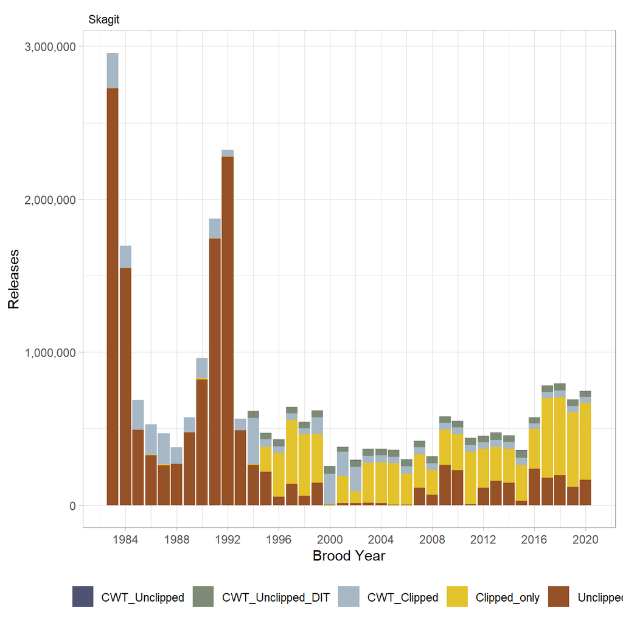

Figure 4.13: Hatchery production of Coho Salmon released within the Skagit , brood years 1983 through 2020.

#### 4.2.1.3 Management Unit Performance

This section of the report includes summaries of forecast performance, abundances and abundance categories, and and associated impacting fisheries for the Skagit . Base period are also provided.

##### Forecast Evaluation

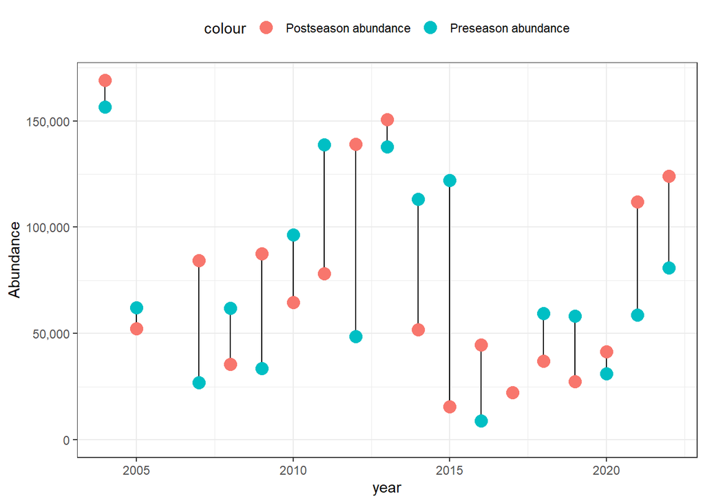

Figure 4.14: Comparison of preseason abundance predictions with the post-season estimates for the Skagit MU.

##### Fishery Mortality and Escapement

*Base Period Exploitation Rates* The base period for the FRAM defines the temporal and spatial distributions of salmon fishing mortalities from each . The current FRAM base period for Coho Salmon includes catch years 1986-1992. During this period, fishing effort, tagging, and fishery sampling of Coho Salmon was high, allowing relatively fine-scale discrimination between salmon distributions. Coded-wire-tag codes used during the base period for the Skagit are provided in the Appendix and average base period by individual fisheries are listed below.

During the base period, Coho Salmon production from the Skagit contributed to US and Canadian marine sport and commercial fisheries in southern British Columbia, the northern Washington coast, Strait of Juan de Fuca, and inner Puget Sound. Terminal tribal and non-tribal set and drift-net Coho Salmon net fisheries occur in commercial fishery management area 8 and the lower Skagit River. Moderate-sized Coho Salmon sport fisheries occured in sport fishery management area 8.1, the mainstem Skagit River, and the Cascade River. The terminal fishery co-managers are WDFW, and the Upper Skagit, Sauk-Suiattle, and Swinomish Tribes.

Table 4.3: Skagit average annual (total) and time period specific used in the current FRAM base period.

| **Fishery** | **Jan-Jun** | **Jul** | **Aug** | **Sept** | **Oct-Dec** | **Total** |
| --- | --- | --- | --- | --- | --- | --- |
| SEAK Southwest Troll | - | 0.00% | - | - | - | 0.00% |
| BC Northern Net | - | 0.02% | - | - | - | 0.02% |
| BC Northern Troll | - | 0.02% | 0.01% | 0.01% | - | 0.04% |
| BC North Central Troll | - | 0.09% | 0.01% | - | - | 0.10% |
| BC Central Net | - | 0.01% | 0.00% | - | - | 0.02% |
| BC South Central Troll | 0.14% | 0.39% | 0.05% | 0.01% | - | 0.59% |
| Johnstone Strait Sport | 0.02% | 0.03% | 0.01% | - | - | 0.06% |
| Johnstone Strait Troll | 0.04% | 0.13% | 0.01% | 0.00% | - | 0.17% |
| Johnstone Straits Net | - | 0.01% | 0.14% | 0.04% | 0.00% | 0.18% |
| Georgia Straits Net | - | - | 0.01% | - | 0.00% | 0.02% |
| Georgia Straits Troll | 0.14% | 0.52% | 0.07% | 0.02% | - | 0.76% |
| North Georgia Straits Sport | 1.41% | 0.82% | 0.41% | 0.08% | 0.00% | 2.73% |
| South Georgia Straits Sport | 0.71% | 0.12% | 0.11% | 0.01% | 0.02% | 0.98% |
| Fraser R Gill Net | - | - | 0.02% | 0.01% | - | 0.03% |
| BC Juan de Fuca Net | 0.02% | 0.28% | 3.75% | 2.08% | - | 6.13% |
| BC Juan de Fuca Sport | 0.63% | 1.02% | 0.35% | 0.49% | 0.10% | 2.59% |
| BC Juan de Fuca Troll | - | 0.00% | 0.00% | 0.00% | - | 0.00% |
| West Coast Vanc Is Sport | 0.02% | 0.19% | 0.07% | 0.00% | - | 0.28% |
| NW Vancouver Island Troll | 0.18% | 3.16% | 1.10% | 0.33% | - | 4.77% |
| SW Vancouver Island Net | 0.01% | 0.00% | - | 0.12% | 0.08% | 0.21% |
| SW Vancouver Island Troll | 0.84% | 12.17% | 6.61% | 1.34% | - | 20.97% |
| WA Area 7 Sport | 0.04% | 0.06% | 0.07% | 0.09% | 0.01% | 0.26% |
| WA Area 7-7A Treaty Net | - | 0.00% | 0.07% | 0.30% | 0.07% | 0.44% |
| WA Area 7-7A Non-Treaty Net | - | 0.00% | 0.07% | 0.18% | 0.03% | 0.28% |
| WA Area 7B-7C-7D Treaty Net | - | - | 0.01% | 0.12% | 0.11% | 0.24% |
| WA Area 7B-7C-7D NT Net | - | - | 0.00% | 0.09% | 0.08% | 0.17% |
| WA Area 6 Sport | 0.06% | 0.30% | 0.23% | 0.49% | 0.20% | 1.28% |
| WA Area 5-6-6C Troll | 0.00% | 0.01% | 0.01% | 0.09% | 0.00% | 0.12% |
| WA Area 5 Sport | 0.27% | 0.97% | 1.38% | 1.18% | 0.08% | 3.88% |
| WA Area 4B-5-6C Treaty Net | - | 0.09% | 0.29% | 0.43% | 0.21% | 1.02% |
| WA Area 4B-5-6C NT Net | - | 0.00% | 0.01% | 0.04% | 0.00% | 0.05% |
| WA Area 8 Non-Treaty Net | - | - | 0.11% | 0.34% | 0.79% | 1.25% |
| WA Area 8 Treaty Net | - | - | 0.08% | 0.99% | 1.56% | 2.64% |
| WA Area 8.1 Sport | - | - | 0.29% | 0.02% | 0.06% | 0.37% |
| WA Area 8.2 Sport | - | - | 0.05% | 0.05% | - | 0.10% |
| Skagit R Net | - | - | - | - | 0.93% | 0.93% |
| Skagit R Sport | - | - | - | - | 0.32% | 0.32% |
| Skagit River Test Net | - | - | - | - | 0.61% | 0.61% |
| WA Area 8A Non-Treaty Net | - | - | - | 0.74% | 0.63% | 1.38% |
| WA Area 8A Treaty Net | - | - | - | 1.17% | 0.94% | 2.11% |
| WA Area 9 Sport | 0.20% | 0.23% | 0.23% | 0.38% | 0.13% | 1.16% |
| Area 9/9A Non-Treaty Net | - | - | - | 0.00% | 0.00% | 0.00% |
| Area 9/9A Treaty Net | - | - | - | 0.00% | 0.01% | 0.01% |
| WA Area 10 Non-Treaty Net | - | - | - | 0.41% | 0.11% | 0.52% |
| WA Area 10 Sport | 0.15% | 0.09% | 0.07% | 0.06% | 0.02% | 0.39% |
| WA Area 10 Treaty Net | - | - | - | 0.24% | 0.06% | 0.30% |
| WA Area 10E Non-Treaty Net | - | - | - | 0.00% | - | 0.00% |
| WA Area 10E Treaty Net | - | - | - | 0.00% | - | 0.00% |
| WA Area 10F-G Treaty Net | - | - | 0.03% | - | - | 0.03% |
| WA Area 11 Non-Treaty Net | - | - | - | 0.10% | 0.02% | 0.12% |
| WA Area 11 Sport | 0.04% | 0.00% | 0.01% | 0.00% | 0.00% | 0.06% |
| WA Area 11 Treaty Net | - | - | - | 0.01% | 0.00% | 0.01% |
| WA Area 13 Marine Sport | 0.01% | - | - | 0.00% | 0.00% | 0.02% |
| Area 12 Marine Sport | - | - | - | - | 0.00% | 0.00% |
| Area 12-12B Hood Canal NT Net | - | - | - | 0.01% | 0.01% | 0.02% |
| Area 12-12B Hood Canal T Net | - | - | - | 0.01% | 0.01% | 0.02% |
| WA Area 4/4B Treaty Troll | 0.20% | 0.62% | 0.60% | 0.21% | 0.02% | 1.66% |
| WA Area 4/4B Non-Treaty Troll | 0.00% | 0.04% | 0.35% | 0.06% | 0.00% | 0.45% |
| WA Area 4 Sport | 0.02% | 0.43% | 0.34% | 0.06% | - | 0.85% |
| WA Area 3 Treaty Troll | 0.06% | 0.13% | 0.14% | 0.05% | - | 0.38% |
| WA Area 3 Sport | 0.00% | 0.04% | 0.01% | - | - | 0.05% |
| WA Area 3 Non-Treaty Troll | 0.05% | 0.01% | 0.04% | 0.03% | - | 0.12% |
| Hoh R Net | - | - | - | - | 0.00% | 0.00% |
| WA Area 2 Treaty Troll | 0.01% | 0.09% | 0.05% | 0.01% | - | 0.16% |
| WA Area 2 Sport | 0.03% | 0.33% | 0.15% | 0.01% | - | 0.52% |
| WA Area 2 Non-Treaty Troll | 0.01% | 0.04% | 0.06% | 0.00% | - | 0.11% |
| Willapa Bay & FW Trib Net | - | - | - | - | 0.00% | 0.00% |
| WA Area 1 & Astoria Troll | 0.01% | 0.09% | 0.05% | 0.04% | 0.01% | 0.20% |
| WA Area 1 & Astoria Sport | 0.00% | 0.06% | 0.05% | - | - | 0.12% |
| Col. River Buoy 10 Sport | - | - | 0.05% | 0.00% | - | 0.06% |
| Tillamook Sport | 0.01% | 0.03% | 0.02% | 0.00% | - | 0.06% |
| Tillamook Troll | 0.01% | 0.17% | 0.04% | 0.00% | - | 0.22% |
| Newport Sport | 0.02% | 0.05% | 0.03% | - | - | 0.10% |
| Newport Troll | 0.05% | 0.12% | 0.03% | 0.00% | - | 0.21% |
| Coos Bay Sport | 0.02% | 0.02% | 0.00% | 0.01% | - | 0.05% |
| Coos Bay Troll | 0.02% | 0.03% | 0.00% | 0.00% | - | 0.06% |
| Brookings Sport | - | 0.00% | - | - | - | 0.00% |
| Brookings Troll | 0.00% | 0.00% | 0.00% | 0.00% | - | 0.01% |
| ** Total ** | 5.40% | 23.10% | 17.80% | 12.60% | 7.30% | 66.10% |

In the most recent years assessed, the Skagit MU has been primarily harvested by Skagit River Net (median = 14% ER) and Skagit River Sport (8% ER) fisheries, both terminal area fisheries, with the remainder of the fisheries impacting this MU at an average of less than 4% per year.

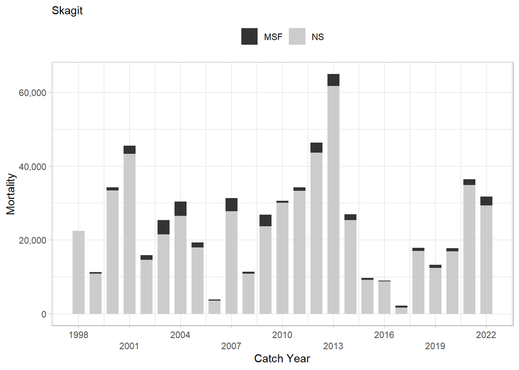

Table 4.4: Historical summary of annual total abundance (January age-3 without natural mortality), adult escapement, marine survival (Baker River Wild), and (ER) of the Skagit Management Unit; since 2004.

| catch_year | abundance | marine_survival | escapement | ER Canada | ER SUS |
| --- | --- | --- | --- | --- | --- |
| 2004 | 169,157 | 9.8% | 138,815 | 0.8% | 17.2% |
| 2005 | 52,362 | 6.4% | 33,058 | 1.6% | 35.3% |
| 2006 | 11,518 | 1.1% | 7,702 | 1.8% | 31.3% |
| 2007 | 84,423 | 8.6% | 53,105 | 2.6% | 34.5% |
| 2008 | 35,458 | 4.5% | 24,095 | 1.2% | 30.9% |
| 2009 | 87,600 | 12.3% | 60,775 | 1.7% | 28.9% |
| 2010 | 64,581 | 3.4% | 34,015 | 0.9% | 46.5% |
| 2011 | 78,116 | 4.1% | 43,918 | 3.1% | 40.6% |
| 2012 | 139,009 | 8.3% | 92,683 | 2.8% | 30.5% |
| 2013 | 150,661 | 6.6% | 85,752 | 4.1% | 39.0% |
| 2014 | 51,696 | 5.2% | 24,816 | 6.0% | 46.0% |
| 2015 | 15,512 | 1.3% | 5,793 | 5.7% | 56.9% |
| 2016 | 44,736 | 5.9% | 35,821 | 1.6% | 18.3% |
| 2017 | 22,278 | 5.6% | 20,182 | 2.2% | 7.2% |
| 2018 | 36,911 | 9.7% | 19,044 | 3.8% | 44.6% |
| 2019 | 27,499 | 6.7% | 14,244 | 5.2% | 43.0% |
| 2020 | 41,468 | 6.0% | 23,806 | 2.4% | 40.2% |
| 2021 | 111,989 | 13.2% | 75,532 | 2.6% | 30.0% |
| 2022 | 124,042 | 12.8% | 92,298 | 3.1% | 22.5% |
| 2023 | NA | 11.5% | NA | NA | NA |
| 2024 | NA | NA | NA | NA | NA |

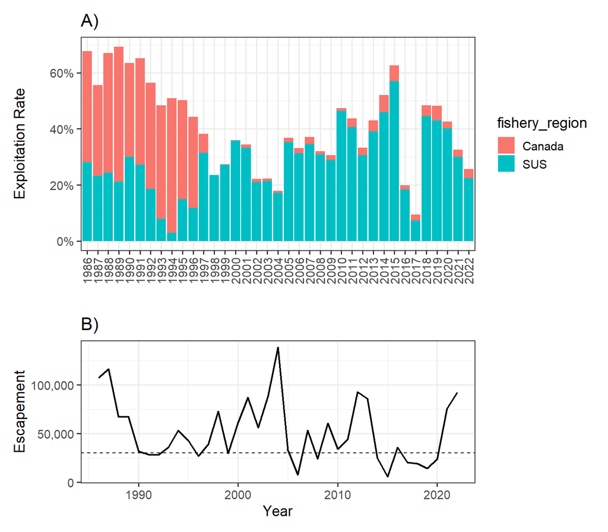

Figure 4.16: Total exploitation rate (A) and escapement (B) of Skagit MU by country, catch years 1986 through 2022. Dashed line indicates escapement goal for the Skagit MU (30,000 individuals).

##### Historical Overview of Status of Management Unit

Harvest of Skagit MU has also varied from year to year, and has declined slightly over this time period. Less than 50,000 fish have been harvested annually in all but one of the years (2013) and most of the harvest has been in non-selective fisheries.

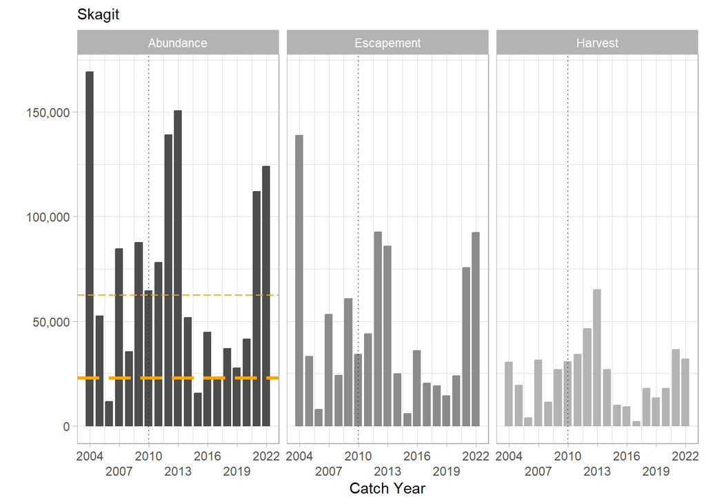

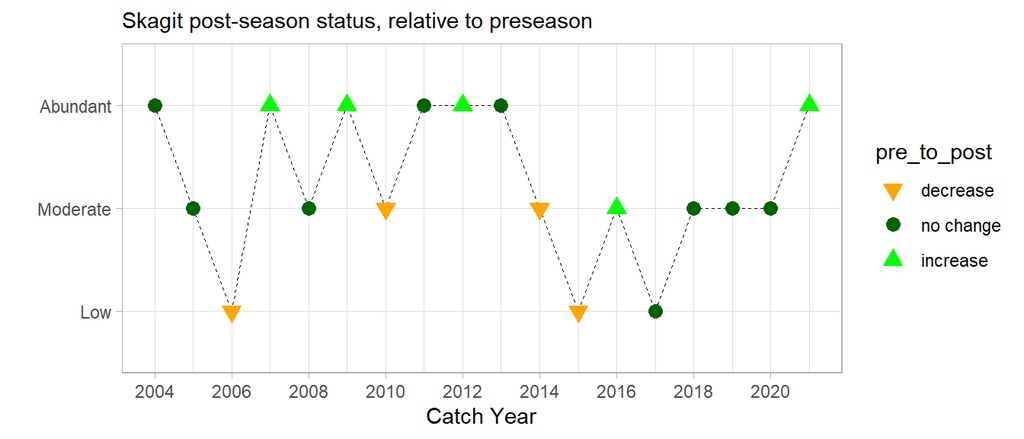

Figure 4.18

Table 4.5: Preseason and post-season abundance estimates for Skagit from 2004 onwards.

| catch_year | abund_preseason | abund_postseason |
| --- | --- | --- |
| 2004 | 156,648.0 | 169,157.3 |
| 2005 | 62,122.2 | 52,362.3 |
| 2006 | 107,112.0 | 11,518.2 |
| 2007 | 26,935.9 | 84,422.8 |
| 2008 | 62,022.3 | 35,457.7 |
| 2009 | 33,559.5 | 87,600.3 |
| 2010 | 96,368.1 | 64,580.7 |
| 2011 | 138,755.9 | 78,115.7 |
| 2012 | 48,528.1 | 139,008.7 |
| 2013 | 137,868.9 | 150,661.2 |
| 2014 | 113,145.6 | 51,696.0 |
| 2015 | 122,122.0 | 15,511.6 |
| 2016 | 8,928.4 | 44,735.8 |
| 2017 | 11,195.4 | 22,278.3 |
| 2018 | 59,449.2 | 36,910.9 |
| 2019 | 58,238.1 | 27,499.0 |
| 2020 | 31,114.7 | 41,468.5 |
| 2021 | 58,820.8 | 111,989.0 |
| 2022 | 80,809.8 | 124,041.9 |
| 2023 | 43,406.6 | NA |
| 2024 | 63,837.1 | NA |

# 5 Members

Membership of the Joint Coho Technical Committee

| Canadian Members | United States Members |
| --- | --- |
| Ms. Dawn Lewis (Co-Chair), CDFO | Dr. Gary S. Morishima (Co-Chair), QIN |
| Mr. Richard Bailey, | Mr. John Brady, NOAA |
| Mr. Roger Dunlop, MMFN | Ms. Carrie Cook-Tabor, USFWS |
| Mr. Kristopher Hein, CDFO | Dr. Collin Edwards, WDFW |
| Ms. Sara Martin, CDFO | Mr. Tyler Garber, WDFW |
| Mr. Michael O’Brien, CDFO | Dr. Diego Holmgren, TUL |
| Mr. Kevin Pellet, CDFO | Ms. Cassandra R. Leeman, ODFW |
| Ms. Ashlee Prevost, | Dr. Marisa Litz, WDFW |
|  | Ms. Stephanie Thurner, NWIFC |
|  | Dr. Laurie Weitkamp, NMFS |

# 6 Acronyms

| Acronym | Definition | URL |
| --- | --- | --- |
| ABM | Abundance-Based Management |  |
| B.C. | British Columbia |  |
| BkFRAM | Backwards FRAM |  |
| BY | Brood Year |  |
| CDFO | Canadian Department of Fisheries and Oceans | https://www.dfo-mpo.gc.ca/index-eng.htm |
| CFNC | Canadian First Nations Caucus |  |
| CoTC | Coho Joint Technical Committee | https://www.psc.org/about-us/structure/committees/technical/coho/ |
| CU | Conservation Unit | https://open.canada.ca/data/en/dataset/1ac00a39-4770-443d-8a6b-9656c06df6a3 |
| CWT | Coded-Wire Tag | https://www.nmt.us/cwt/ |
| DIT | Double-Index Tag |  |
| EDT | Electronic Tag Detection |  |
| ENSO | El Niño-Southern Oscillation | https://www.climate.gov/enso |
| ER | Exploitation Rate |  |
| ESA | U.S. Endangered Species Act | https://www.fws.gov/international/laws-treaties-agreements/us-conservation-laws/endangered-species-act.html |
| ESU | Evolutionarily Significant Unit | https://www.nwfsc.noaa.gov/assets/4/6878_09172014_172219_Waples.1995.pdf |
| FMP | Fisheries Management Plan |  |
| FRAFS | Fraser River Aboriginal Fisheries Secretariat | https://www.frafs.ca/ |
| FRAM | Fishery Regulation and Assessment Model | https://framverse.github.io/fram_doc/ |
| HC | Hood Canal |  |
| IFMP | Integrated Fisheries Management Plan | https://www.pac.dfo-mpo.gc.ca/fm-gp/ifmp-eng.html#Salmon |
| IFR | Interior Fraser River |  |
| iREC | Internet-based Recreational Fishery | https://www.pac.dfo-mpo.gc.ca/fm-gp/rec/irec-info-eng.html |
| JA3 | January Age-3 |  |
| LFFA | Lower Fraser Fishery Alliance | https://www.lffa.ca/ |
| LWFR | Lower Fraser River |  |
| MFMT | Maximum Fishing Mortality Threshold |  |
| MMFN | Mowachaht-Muchalaht First Nation | https://www.yuquot.ca/ |
| MSA | Magnuson-Stevens Fishery Conservation and Management Act | https://www.fisheries.noaa.gov/resource/document/magnuson-stevens-fishery-conservation-and-management-act |
| MSF | Mark-Selective Fishery | https://wdfw.wa.gov/sites/default/files/about/commission/meetings/2018/08/aug0918_fc_selective_fisheries.pdf |
| MSH | Maximum Sustainable Harvest | https://www.pcouncil.org/fact-sheet-annual-catch-limits-and-other-management-thresholds/#:~:text=The%20overfishing%20limit%20(OFL)%20is,the%20FMSY%20harvest%20rate. |
| MSM | Mixed-Stock Model |  |
| MU | Management Unit |  |
| NMFS | National Marine Fisheries Service | https://www.fisheries.noaa.gov/ |
| NOF | North of Falcon | https://wdfw.wa.gov/fishing/management/north-falcon |
| NSF | Non-Selective Fishery |  |
| NTC | Nuu-chah-nulth Tribal Council | https://nuuchahnulth.org/ |
| NWIFC | Northwest Indian Fisheries Commission | https://nwifc.org/ |
| OA3 | Ocean Age-3 |  |
| ODFW | Oregon Department of Fish and Wildlife | https://www.dfw.state.or.us/ |
| OFL | Overfishing Limit | https://www.pcouncil.org/fact-sheet-annual-catch-limits-and-other-management-thresholds/#:~:text=The%20overfishing%20limit%20(OFL)%20is,the%20FMSY%20harvest%20rate. |
| OR | Oregon |  |
| PDO | Pacific Decadal Oscillation | https://www.ncei.noaa.gov/access/monitoring/pdo/ |
| PEF | Production Expansion Factor |  |
| PFMC | Pacific Fisheries Management Council U.S. | https://www.pcouncil.org/ |
| PS | Puget Sound | https://en.wikipedia.org/wiki/Puget_Sound |
| PSC | Pacific Salmon Commission | https://www.psc.org/ |
| PST | Pacific Salmon Treaty | https://www.psc.org/publications/pacific-salmon-treaty/ |
| QIN | Quinault Indian Nation | http://www.quinaultindiannation.com/ |
| RMIS | Regional Mark Information System | https://www.rmpc.org/ |
| RMISD | Regional Mark Information System Database (U.S.) | https://www.rmpc.org/ |
| RMPC | Regional Mark Processing Center | https://www.rmpc.org/ |
| RRTERM | Terminal Area Run Reconstruction Program |  |
| SCMP | Southern Coho Management Plan | https://www.psc.org/publications/pacific-salmon-treaty/ |
| SRSC | Skagit River System Cooperative |  |
| SIT | Single Index Tag |  |
| SJDF | Strait of Juan de Fuca |  |
| SUQ | Suquamish Tribe | https://suquamish.nsn.us/ |
| TT | Tulalip Tribes | https://www.tulaliptribes-nsn.gov/ |
| U.S. | United States |  |
| UFFCA | Upper Fraser Fisheries Conservation Alliance | https://www.upperfraser.ca/ |
| USFWS | U.S. Fish and Wildlife Service | https://www.fws.gov/ |
| WA | Washington |  |
| WCVI | West Coast of Vancouver Island |  |
| WDFW | Washington Department of Fish and Wildlife | https://wdfw.wa.gov/ |
| WSP | Wild Salmon Policy (Canada) |  |
| WRIA | Water Resource Inventory Area (U.S.) |  |

# 7 Glossary

| Term | Definition |
| --- | --- |
| Abundance-Based Management (ABM) | A management framework that constrains exploitation rates, based on a categorical abundance forecast (abundant, moderate, low) for naturally-spawning Coho Management Units. The purpose is to provide m… |
| Base Period (FRAM) | The FRAM base period is a period chosen to represent average temporal and geographic distributions of Coho Salmon coastwide. The base period was developed by summarizing coded-wire-tag information fro… |
| Break point | A Management Unit-specific ocean age-3 abundance level that determines the categorical status of a stock (i.e., abundant, moderate, low). |
| Brood Year (BY) | The year in which the majority of parent fish spawned and deposited fertilized eggs. |
| By-catch | Incidental or unintentional catch of non-target stocks or species. |
| Catch | The number of fish that are retained in a fishery. |
| Coded-Wire Tag (CWT) | A small piece of magnetized stainless-steel wire that is injected into the snout of a juvenile salmon (usually hatchery stock). Each tag is 0.25 mm in diameter and typically 1.1 mm long and is etched … |
| Cohort | A group of fish belonging to the same brood year. |
| Cohort Abundance | For each stock unit, an annual abundance is obtained from a regional expert, typically in the form of an ocean age-3 run size (pre-fishing age-3 abundance in the ocean after natural mortality has been… |
| Cohort Reconstruction or Cohort Analysis | Cohort reconstruction is a method commonly used in salmon stock assessment for estimation of exploitation rates. The basic principle of cohort reconstruction is the sequential estimation of a cohort’s… |
| Co-management | The collaborative process between co-managers–tribal governments and state governments on the West Coast. Using scientific information, the co-managers make decisions about the management of fisheries… |
| Command Files | The files used in the Fisheries Regulation Assessment Model containing all the necessary input parameters to run the model, such as forecasted abundance estimates and fishery regulations. A separate c… |
| Conservation Unit (CU) | Salmon populations that have been identified as distinct units of biodiversity under the Canadian Wild Salmon Policy (see Holtby and Ciruna 2007). A Conservation Unit (CU) is a group of wild Pacific s… |
| Double-Index Tag (DIT) | Paired groups of tagged fish, each tagged with separate CWT tag code, used to determine differential exploitation rates on marked and unmarked fish subjected to mark-selective fisheries. Both groups a… |
| El Niño Index (ONI) | The Oceanic Niño Index (ONI) is an index for tracking the ocean part of ENSO, the El Niño-Southern Oscillation climate pattern. The ONI is a rolling 3-month average temperature anomaly in the surface … |
| Electronic Tag Detection (ETD) | The use of a handheld wand or tunnel type detector that can sense the magnetized coded-wire tag within a fish's snout. |
| Endangered Species Act (U.S.) | The Endangered Species Act (ESA) is the primary law in the United States for protecting critically important species that are at risk of extinction. Under the ESA, the federal government has the respo… |
| Enhancement | Use of hatcheries, spawning channels, lake fertilization or habitat restoration to increase the survival rate or production of salmon at some stage of its life. |
| Escapement (Spawning Escapement) | The number of adult salmon that escape all fisheries and other forms of mortality to return to a hatchery or stream to spawn. |
| Evolutionarily Significant Unit (ESU) | Under the U.S. Endangered Species Act, a group of Pacific salmon populations that represent an important component of the evolutionary legacy of the species and are therefore treated as a single “spec… |
| Exclusive Economic Zone | The Exclusive Economic Zone (EEZ) is an area from 3 to 200 nautical miles offshore of coastal states and is classified as federal waters. In the EEZ, the U.S. has special rights about the exploration … |
| Exploitation Rate (ER) | Expressed as a percentage, the proportion of the total return of adult salmon in a given year that die as a result of fishing activity. Mortalities include landed catch and incidental mortalities. |
| Exploitation Rate Cap | The maximum exploitation rate an MU can be subjected to given its categorical abundance status. Under the ABM, allowable exploitation rate is shared by Canada and the U.S. |
| Fisheries Management | Fisheries management is a process that relies on science, management approaches, enforcement, partnerships, and public participation. Fisheries management uses scientific information (e.g., number of … |
| Fisheries Management Plan (FMP) | The set of fisheries planned to distribute exploitation rates amongst fisheries and time periods each year. These are termed Integrated Fisheries Management Plans in Canada. |
| Fishery | A fishery is an activity leading to the harvesting of fish and can be specified by the species of fish caught, people involved, location, method of fishing, and purpose of the activities. Fish caught … |
| Fishery Regulation Assessment Model (FRAM) | A model used to estimate the MU- and fishery-specific impacts. The Forwards FRAM projects MU-specific mortalities and escapements under proposed fishery regimes given pre-season forecasts. The Backwar… |
| Fry | Salmon that have emerged from gravel, completed yolk absorption, remained in freshwater streams, and are less than a few months old. |
| FSC (Canada) | First Nations' fishery for food, social, and ceremonial use. |
| Harvest | The term harvest refers to the total number of fish caught and kept from an area or fishery during a period of time. |
| Incidental mortality | Mortality incurred during fishing in addition to landed catch. For example, some fish die as a result of being caught and released. |
| Indicator stock | A coded-wire-tagged surrogate stock that is used to make inferences for a particular MU. For example, a CWT release from a hatchery stock may be used to estimate the distribution and magnitude of fish… |
| Integrated Fisheries Management Plan (IFMP) | These Canadian plans identify the main objectives and requirements for Pacific fisheries and outline the management to achieve these objectives. IFMPs provide a common understanding of the basic rules… |
| Interception | Interception occurs when a salmon from one state or country is caught in another state or country's fisheries. As salmon grow and mature in the Pacific Ocean, they travel along the West Coast and acro… |
| January age-3 abundance (JA3) | The estimated abundance of fish of age-3 (adults) in January before any fisheries start. January age-3 abundance is estimated as fishing mortality plus escapement plus natural mortality. |
| La Niña |  |
| Landed catch | Fish that are caught and kept (see Incidental mortality) |
| Magnuson-Stevens Fishery Conservation and Management Act (MSA) | The Magnuson-Stevens Fishery Conservation and Management Act (MSA) is the primary law that governs fisheries management in the federal marine waters (3-200 miles offshore) of the United States. The go… |
| Management Unit (MU) | Under the PST Southern Coho agreement, a geographically-based aggregate of salmon populations, that is managed under a single set of exploitation rate caps. |
| Mark-Selective Fishery (MSF) | A fishery that requires marked fish (i.e., those with adipose fin clips) and unmarked fish (those with intact adipose fins) to be differentially retained (e.g., marked fish kept, unmarked fish release… |
| Maximum Sustainable Harvest (MSH) | An estimate of the largest average annual catch or yield that can be continuously taken over a long period from a stock under prevailing ecological and environmental conditions. |
| Mixed-Stock Model | A model used to estimate the cohort abundances in mixed stock fisheries using coded-wire tags and estimates of catch (see Production Expansion Factors). |
| Naturally Produced | Originated from spawning in the natural environment, as opposed to spawned in a hatchery. Often considered “wild”. |
| Non-retention fisheries | Fisheries in which a particular group of fish are not allowed to be kept (e.g., due to species or external marks) (see Retention Fisheries) |
| Non-selective fisheries (NSF) | Fisheries allowed to retain both marked (adipose fin clipped) and unmarked fish (see Mark-selective fishery). |
| North of Falcon | Each year state, federal, and tribal fishery managers gather to plan the Northwest's recreational and commercial salmon fisheries. This series of meetings – involving representatives from federal, sta… |
| Ocean Age-3 Abundance (OA3) | Total number of fish that are harvested (including incidental mortality) plus those that escape to spawn (also referred to as “cohort abundance” or “ocean recruits”). Natural mortality is not included… |
| Overfishing Limit (OFL) | The overfishing limit (OFL) is the maximum amount of a stock that can be caught in a year without resulting in overfishing. Groundfish OFLs for assessed stocks are typically determined by multiplying … |
| Pacific Decadal Oscillation (PDO) | The PDO describes the pattern of sea surface temperatures around the North Pacific Ocean north of 20°N. During a "warm", or "positive", phase, the west Pacific becomes cooler and part of the eastern o… |
| Pacific Salmon Commission (PSC) | A joint Canada/U.S. commission established under the Pacific Salmon Treaty to oversee the implementation of the Pacific Salmon Treaty. |
| Pacific Salmon Treaty (PST) | A treaty between Canada and the United States concerning the conservation, management, restoration, and enhancement of pacific salmon resources. |
| Pacific States Marine Fisheries Commission (PSMFC) | Pacific States Marine Fisheries Commission (PSMFC) is a non‐regulatory agency that serves Alaska, California, Idaho, Oregon, and Washington. PSMFC (headquartered in Portland) administers salmon disast… |
| Production Expansion Factor (PEF) | A scalar that represents the number of fish in a population from a single CWT recovery. |
| Rebuilding | The process of rebuilding an overfished stock. For salmon, rebuilding usually takes the form of reduced harvest limits. |
| Reference Point | A Management Unit-specific ocean age-3 abundance level that determines the categorical status of a stock (i.e., abundant, moderate, low). |
| Regional Mark Information System (RMIS) | Database containing data on salmonid releases, recoveries in fisheries and escapement, and estimated catch by fishery and time period. |
| Retention fisheries | Fisheries in which fish of a particular group are allowed to be kept (see Non-retention fisheries). |
| Return year | The year in which fish would normally return to spawn as adults. For Southern Coho Salmon that mature as 3 year old adults, return year is Brood Year + 3. |
| RR Term | A program that reconstructs terminal Coho runs using freshwater and terminal area marine fisheries and escapement data for Puget Sound stocks. |
| Run | As salmon migrate back to freshwater as adults, they arrive in groups called runs, which are typically associated with a season (spring, summer, fall, winter). A run of salmon may be composed of salmo… |
| Sibling Forecast | In all species of Pacific salmon but pinks, the individual salmon produced in any one spawning year mature and return to spawn in more than one subsequent year. All of the fish that return from a spaw… |
| Single Index Tag (SIT) | A group of coded-wire-tagged (CWT) fish that are not paired with another release group. They can be marked (clipped) or unmarked (unclipped). |
| Smolt | A smolt is a life cycle phase of a salmon or steelhead when the fish is preparing for the transition from freshwater to saltwater. The process is called smoltification. A smolt becomes physiologically… |
| Smolt Year | The year in which fish would normally enter the ocean as smolts. For Southern Coho Salmon, smolt year is brood year + 2 and return year − 1. Often described as “smolt outmigration year”. |
| Southern Coho Management Plan (SCMP) | An agreement between the U.S. and Canada that specifies how the Parties’ fisheries impact on Coho Salmon that originate in southern British Columbia, Washington and Oregon shall be managed, subject to… |
| Spawning Escapement | The number of adult fish that “escape” fisheries and return to freshwater to spawn. |
| Spawning Grounds/Spawn | Spawning grounds are the freshwater areas where salmon and steelhead spawn. |
| Special management zone (SMZ) | Geographic/temporal areas in B.C. that have special management restrictions. |
| Status | A Management Unit's status (Low, Moderate, and Abundant) is based on its forecasted (pre-season) or estimated (post-season) ocean Age-3 abundance. |
| Stock | A group of interbreeding organisms that is relatively isolated (i.e., demographically uncoupled) from other such groups and is likely adapted to the local habitat. Fish species are made up of an aggre… |
| Stock Assessment | The use of various statistical and mathematical calculations to make quantitative predictions about the reactions of fish populations to alternative management choices. |
| Subsistence Fisheries | In the Pacific Northwest of the U.S., the term "Ceremonial and Subsistence" (C&S) is used to describe non-commercial harvest in Treaty Tribe fisheries for personal, ritual, or community use. In Canada… |
| Treaty/Treaties | A treaty is a formal, legally binding agreement that establishes obligations between and among two or more countries, states, or sovereign nations. Examples of treaties include the Pacific Salmon Trea… |
| Troll Fishery (Trolling) | Fishing with a hook or hooks attached to a line that is towed through the water or from a vessel. Commercial trollers employ hooks and lines that are suspended from large poles extending from the fish… |
| Voluntary Head Recovery Program (VHRP) | A sampling program in B.C. for recreational fisheries that relies upon anglers voluntarily returning heads from marked salmon so CWTs may be recovered. |
| Wild Salmon | Salmon are considered "wild" if they have spent their entire life cycle in the wild and originate from parents that were also produced by natural spawning and continuously lived in the wild. |

# 8 Appendix: Annual CoTC reports of Estimates of Exploitation Rates

[General archive of public CoTC reports](https://www.psc.org/publications/technical-reports/technical-committee-reports/coho/)

# 9 Appendix: realized vs target ERs

| Catch Year | PSC_StockName | Preseason Cap | Preseason Model ER | Preseason Unused | Postseason Cap | Postseason Model ER | Postseason Unused | Postseason Unused Using Preseason Cap |
| --- | --- | --- | --- | --- | --- | --- | --- | --- |
| 2004 | Skagit | 60.0 | 35.8 | 24.2 | 60.0 | 17.9 | 42.1 | 42.1 |
| 2004 | Stillaguamish | 50.0 | 38.8 | 11.2 | 50.0 | 12.0 | 38.0 | 38.0 |
| 2004 | Snohomish | 60.0 | 34.8 | 25.2 | 60.0 | 12.7 | 47.3 | 47.3 |
| 2004 | Hood Canal | 65.0 | 34.6 | 30.4 | 65.0 | 43.7 | 21.3 | 21.3 |
| 2004 | US Strait JDF | 60.0 | 13.0 | 47.0 | 40.0 | 9.4 | 30.6 | 50.6 |
| 2005 | Skagit | 35.0 | 34.2 | 0.8 | 35.0 | 36.9 | −1.9 | −1.9 |
| 2005 | Stillaguamish | 50.0 | 42.8 | 7.2 | 50.0 | 26.4 | 23.6 | 23.6 |
| 2005 | Snohomish | 60.0 | 39.4 | 20.6 | 60.0 | 22.2 | 37.8 | 37.8 |
| 2005 | Hood Canal | 65.0 | 34.6 | 30.4 | 65.0 | 37.7 | 27.3 | 27.3 |
| 2005 | US Strait JDF | 40.0 | 12.2 | 27.8 | 20.0 | 6.8 | 13.2 | 33.2 |
| 2006 | Skagit | 60.0 | 35.4 | 24.6 | 20.0 | 33.1 | −13.1 | 26.9 |
| 2006 | Stillaguamish | 50.0 | 40.2 | 9.8 | 35.0 | 20.9 | 14.1 | 29.1 |
| 2006 | Snohomish | 60.0 | 38.7 | 21.3 | 40.0 | 20.2 | 19.8 | 39.8 |
| 2006 | Hood Canal | 65.0 | 37.1 | 27.9 | 65.0 | 74.1 | −9.1 | −9.1 |
| 2006 | US Strait JDF | 40.0 | 11.7 | 28.3 | 20.0 | 9.1 | 10.9 | 30.9 |
| 2007 | Skagit | 35.0 | 33.2 | 1.8 | 60.0 | 37.1 | 22.9 | −2.1 |
| 2007 | Stillaguamish | 50.0 | 38.5 | 11.5 | 50.0 | 25.1 | 24.9 | 24.9 |
| 2007 | Snohomish | 40.0 | 39.0 | 1.0 | 60.0 | 25.2 | 34.8 | 14.8 |
| 2007 | Hood Canal | 65.0 | 45.6 | 19.4 | 65.0 | 47.8 | 17.2 | 17.2 |
| 2007 | US Strait JDF | 60.0 | 12.3 | 47.7 | 20.0 | 12.6 | 7.4 | 47.4 |
| 2008 | Skagit | 35.0 | 30.1 | 4.9 | 35.0 | 32.0 | 3.0 | 3.0 |
| 2008 | Stillaguamish | 50.0 | 37.8 | 12.2 | 35.0 | 23.3 | 11.7 | 26.7 |
| 2008 | Snohomish | 40.0 | 34.5 | 5.5 | 20.0 | 27.5 | −7.5 | 12.5 |
| 2008 | Hood Canal | 45.0 | 44.9 | 0.1 | 45.0 | 42.5 | 2.5 | 2.5 |
| 2008 | US Strait JDF | 40.0 | 11.0 | 29.0 | 20.0 | 8.8 | 11.2 | 31.2 |
| 2009 | Skagit | 35.0 | 32.7 | 2.3 | 60.0 | 30.6 | 29.4 | 4.4 |
| 2009 | Stillaguamish | 35.0 | 33.4 | 1.6 | 50.0 | 28.2 | 21.8 | 6.8 |
| 2009 | Snohomish | 40.0 | 26.5 | 13.5 | 60.0 | 26.4 | 33.6 | 13.6 |
| 2009 | Hood Canal | 65.0 | 47.3 | 17.7 | 65.0 | 53.7 | 11.3 | 11.3 |
| 2009 | US Strait JDF | 40.0 | 11.9 | 28.1 | 40.0 | 15.2 | 24.8 | 24.8 |

[output cut: 65 more lines]

# 10 Appendix: FRAM Pre and Post-Season Command Files

Table 10.1: Pre- and post-season command files and base period used in FRAM to evaluate over catch years 2004 through 2023. “Post-season Original” command files are those used to generate estimates for the Annual Report provided to the Southern Panel during the Annual Meeting.

| Catch Year | Pre-season U.S. | Pre-season Canada | Post-season Original | Post-season Revised | Base Period Used in Revised BKFRAM Run |
| --- | --- | --- | --- | --- | --- |
| 2004 | 0425.Cmd | 0427.Cmd | 04pa.Cmd | BK04.Cmd | CohoBase |
| 2005 | 0519.Cmd | P5at.Cmd | 05p9bk.Cmd | BK05.Cmd | CohoBase87917 |
| 2006 | 0619.Cmd | 0631.Cmd | 06p4.Cmd | BK06.Cmd | CohoBase-86-92-NoUF86-Jan2008 |
| 2007 | 0714.Cmd | 0714.Cmd | 07JH.Cmd | BK07.Cmd | CohoBase-86-92-NoUF86-Jan2009 |
| 2008 | 0824.Cmd | 0828.Cmd | BK08.Cmd | BK08.Cmd | CohoBase-86-92-NoUF86-Feb2008 |
| 2009 | 0920.Cmd | 0920.Cmd | BK09.Cmd | BK09.Cmd | CohoBase-86-92-NoUF86-Feb2009 |
| 2010 | 1016.Cmd | 1016.Cmd | BK10 PSC Feb14 | TBD | CohoBase-86-92-NoUF86-Feb2009 |
| 2011 | 1116.Cmd | TBD | Coho2011Post_PSC 2013 | TBD | TBD |
| 2012 | 1229.Cmd | TBD | Coho2012Post_PSC SSNPx2 Q 2014 | TBD | TBD |
| 2013 | bc-1323 all FRAM inputs | TBD | bk 2013 Final ver3 Feb 11 2015 | TBD | TBD |
| 2014 | bc-Coho1418 US and BC preseason 2014 | TBD | bc-BK2014 w TAMM inputs final#2 | TBD | TBD |
| 2015 | bc-Coho 1523 Final | TBD | bc-bkCoho2015 Final | TBD | TBD |
| 2016 | bc-Coho1637 rerun by CoTC | TBD | bc-BK2016 BPMar2013 final | TBD | TBD |
| 2017 | bc-Coho1731_Final | TBD | bc-BK Coho 2017 final take2 | TBD | TBD |
| 2018 | bc-Coho1830 | TBD | bc-BKCoho2018_A_2_a | TBD | TBD |
| 2019 | bc‐Coho1925 | TBD | bc‐BKCoho2019_A_2_d | TBD | TBD |
| 2020 | bc‐Coho2032 | TBD | bc‐BKCoho2020_A_2_c | TBD | TBD |
| 2021 | bc‐Coho2140_Final | TBD | bc‐BkCoho2021_A_2 | TBD | TBD |
| 2022 | TBD | TBD | Not yet available | Not yet available | Not yet available |
| 2023 | TBD | TBD | Not yet available | Not yet available | Not yet available |

# 11 Appendix: List of indicator stocks by management units

Table 11.1: Coded-wire-tag indicator stocks and brood years with single index tag (SIT) and groups for each Coho Salmon , beginning with brood year 1983. Indicator stocks are hatchery-produced Coho Salmon unless specified as “Wild” (Release data downloaded from RMIS 1-10-2023). SIT groups may be either marked or unmarked releases of Coho Salmon. groups are marked (adipose-fin clipped) and unmarked pairs of Coho Salmon.

| **Management Unit** | **Indicator Stock** | **Brood Yr SIT** | **Brood Yr** |
| --- | --- | --- | --- |
| **Southern BC MUs** |  |  |  |
| Lower Fraser | Inch Creek Hatchery | 83-95,14-19 | 96-13 |
|  | Salmon River (Wild)[^1] | 84-99,01,03,05-07 | NA |
|  | Chilliwack R. H. (Chilliwack R.) | 83-95 | 96-02 |
|  | Chehalis R. H. (Chehalis R.) | 83-97 | – |
| Interior Fraser | Spius Cr. H. (Coldwater R.)[^2] | 84-94,96-98,03-19 | 99-02 |
|  | Spius Cr. H. (Salmon R./TOMF)[^3] | 95-96,99,01-02,04-05,07,14,17-19 | – |
|  | Spius Cr. H. (Spius Cr.)[^4] | 94-96,99-00 | 97-98 |
|  | Spius Cr. H. (Eagle R.) | 10-13,15-19 | – |
|  | Chilliwack R. H. (Coldwater R.)[^5] | 16-19 | – |
|  | Eagle R. H. (Salmon R.)[^6] | 83-93 | – |
|  | Eagle R. H. (Eagle R.)[^7] | 83-93 | – |
|  | Eagle R. H. (Perry R.)[^8] | 84-86 | – |
|  | Dunn Cr. H. (Dunn Cr.)[^9] | 86-87,89-90,92,95,98-07 | – |
|  | Dunn Cr. H. (Dunn Lake)[^10] | 84-91,94,97 | – |
|  | Dunn Cr. H. (Lemieux Cr.)[^11] | 83-86,88,92-93,97-99,03,06-09 | – |
|  | Dunn Cr. H. (Louis Cr.)[^12] | 88-94,97-07 | – |
|  | Dunn Cr. H. (Ianson Ch.)[^13] | 88-91,94-95,00-02,04-05 | – |
|  | Eagle River (Wild)[^14] | 00-03 | NA |
|  | Lemieux Creek (Wild) | 92-93 | NA |
| Strait of Georgia Mainland | Capilano R. H. | 83-97,00 | – |
|  | Lang Creek H. (Lang Cr.)[^15] | 87-91,95-96,08-09 | – |
| Strait of Georgia Vancouver Island | Quinsam R. H. | 83-85,18-19 | 96-17 |
|  | Big Qualicum R. H. | 83-85,87-95,03-15,17-19 | 96-02 |
|  | Goldstream R. H. | 91-94,03-11 | 96-02 |
|  | Puntledge R. H.[^16] | 83-97,99-02,09-10,19 | – |
|  | Black Creek (Wild)[^17] | 83-17 | NA |
| **US Inside MUs** |  |  |  |
| Skagit | Marblemount H. (Skagit R.) | 83-93 | 94-21 |
|  | Baker River (Wild)[^18] | 83-97,00-22 | NA |
| Stillaguamish[^19] | Wallace R. H. (Skykomish R.) | 83-95 | 96-21 |
|  | Harvey Creek H. | 91,07,14,16-20 | – |
|  | Stillaguamish R. (Wild) | 84-87 | NA |
| Snohomish | Wallace R. H. (Skykomish R.) | 83-95 | 96-21 |
|  | Bernie Gobin H. (Tulalip Cr.)[^20] | 83-21 | – |
| Hood Canal | Quilcene NFH | 87-95 | 96-21 |
|  | Quilcene Bay Sea Pens | 88,90,93,95,02-11,13-14 | 96-01 |
|  | Port Gamble Bay Pens | 83-95,04-21 | 96-03 |
|  | George Adams H. (Skokomish R.) | 83-94,96 | 95,97-21 |
|  | Big Beef Creek (Wild)[^21] | 83-21 | NA |
| Strait of Juan de Fuca | Lower Elwha H.[^22] | 85-94,12,15,18 | 95-11,13-14,16-17,09-20 |
|  | Dungeness H. | 83,86,89,91-94,05-08,18-20 | – |
|  | Hoko Falls H. | 18-20 | – |
|  | Hoko and Salmon Creek (Wild) | 84-87,08 | NA |
| **US Outside MUs** |  |  |  |
| Quillayute | Sol Duc H. | 83-88,90-95 | 96-21 |
|  | Various Tributaries (Wild)[^23] | 83-86,88-92 |  |
| Hoh | Chalaat Creek H. | 84,86-89 | – |
|  | Canyon Springs Pond | 86-87 | – |
|  | Sol Duc H. | 85,87 | – |
|  | Hoh River (Wild)[^24] | 83-87,03,05-12 | NA |
| Queets | Quinault Lake H. | 83-84,90-92 | – |
|  | Salmon R. Fish Culture | 83,85-94 | 95-21 |
|  | Queets/Clearwater wild[^25] | 83-11,13-20 | NA |
| Grays Harbor | Bingham Creek H. | 83-94 | 95-21 |
|  | Aberdeen Net Pens | 88-90,92-94 | – |
|  | Humptulips H. (Stevens Cr.) | 83-94,06,10-12,19-20 | 95-96 |
|  | Bingham Creek (Wild)[^26] | 83-20 | NA |
|  | Stevens & Scatter Creek (Wild) | 83-90,92-93 | NA |
|  | Chehalis Upriver (Wild)[^27] | 83-97,00-20 | NA |
|  | Skookumchuck H. | 83,89,98,06-07,09, 11-12 | 98 |

# 12 Appendix: U.S. DITs

Data provided here was queried from the RMIS release database on 1/27/2025.

## 12.1 Skagit MU

Table 12.1: Double-index tag codes released within the Skagit MU, brood years 1994 through 2022.

| Brood Year | Hatchery | DIT Group ID | Tag Code | Mark | # Released |
| --- | --- | --- | --- | --- | --- |
| 1994 | MARBLEMOUNT HATCHERY | 04199600000211 | 635909 | Clipped | 99623 |
| 1994 | MARBLEMOUNT HATCHERY | 04199600000211 | 635906 | Unclipped | 45865 |
| 1995 | MARBLEMOUNT HATCHERY | 04199700000212 | 636158 | Clipped | 42489 |
| 1995 | MARBLEMOUNT HATCHERY | 04199700000212 | 636201 | Unclipped | 42566 |
| 1996 | MARBLEMOUNT HATCHERY | 04199800000196 | 630545 | Clipped | 43348 |
| 1996 | MARBLEMOUNT HATCHERY | 04199800000196 | 630546 | Unclipped | 45089 |
| 1997 | MARBLEMOUNT HATCHERY | 04199900000195 | 630554 | Clipped | 42299 |
| 1997 | MARBLEMOUNT HATCHERY | 04199900000195 | 636211 | Unclipped | 41906 |
| 1998 | MARBLEMOUNT HATCHERY | 04200000000209 | 631107 | Clipped | 40398 |
| 1998 | MARBLEMOUNT HATCHERY | 04200000000209 | 631108 | Unclipped | 40525 |
| 1999 | MARBLEMOUNT HATCHERY | 04200100000199 | 630299 | Clipped | 45831 |
| 1999 | MARBLEMOUNT HATCHERY | 04200100000199 | 630298 | Unclipped | 45052 |
| 2000 | MARBLEMOUNT HATCHERY | 04200200000200 | 630950 | Clipped | 10582 |
| 2000 | MARBLEMOUNT HATCHERY | 04200200000200 | 630387 | Clipped | 10777 |
| 2000 | MARBLEMOUNT HATCHERY | 04200200000200 | 630946 | Clipped | 10783 |
| 2000 | MARBLEMOUNT HATCHERY | 04200200000200 | 630948 | Clipped | 10861 |
| 2000 | MARBLEMOUNT HATCHERY | 04200200000200 | 630386 | Unclipped | 10988 |
| 2000 | MARBLEMOUNT HATCHERY | 04200200000200 | 630947 | Unclipped | 10969 |
| 2000 | MARBLEMOUNT HATCHERY | 04200200000200 | 630949 | Unclipped | 10935 |
| 2000 | MARBLEMOUNT HATCHERY | 04200200000200 | 630945 | Unclipped | 10988 |
| 2001 | MARBLEMOUNT HATCHERY | 04200300000206 | 631257 | Clipped | 10745 |
| 2001 | MARBLEMOUNT HATCHERY | 04200300000206 | 631259 | Clipped | 11240 |
| 2001 | MARBLEMOUNT HATCHERY | 04200300000206 | 631253 | Clipped | 9013 |
| 2001 | MARBLEMOUNT HATCHERY | 04200300000206 | 631255 | Clipped | 9975 |
| 2001 | MARBLEMOUNT HATCHERY | 04200300000206 | 631254 | Unclipped | 7472 |
| 2001 | MARBLEMOUNT HATCHERY | 04200300000206 | 631069 | Unclipped | 6887 |
| 2001 | MARBLEMOUNT HATCHERY | 04200300000206 | 631256 | Unclipped | 9063 |
| 2001 | MARBLEMOUNT HATCHERY | 04200300000206 | 631258 | Unclipped | 8999 |
| 2002 | MARBLEMOUNT HATCHERY | 04200400000192 | 632090 | Clipped | 11046 |
| 2002 | MARBLEMOUNT HATCHERY | 04200400000192 | 632088 | Clipped | 10781 |
| 2002 | MARBLEMOUNT HATCHERY | 04200400000192 | 632089 | Clipped | 6947 |
| 2002 | MARBLEMOUNT HATCHERY | 04200400000192 | 632091 | Clipped | 10861 |
| 2002 | MARBLEMOUNT HATCHERY | 04200400000192 | 632092 | Unclipped | 10967 |
| 2002 | MARBLEMOUNT HATCHERY | 04200400000192 | 632094 | Unclipped | 10878 |
| 2002 | MARBLEMOUNT HATCHERY | 04200400000192 | 632093 | Unclipped | 9781 |
| 2002 | MARBLEMOUNT HATCHERY | 04200400000192 | 632095 | Unclipped | 11100 |
| 2003 | MARBLEMOUNT HATCHERY | 04200500000191 | 631997 | Clipped | 46348 |
| 2003 | MARBLEMOUNT HATCHERY | 04200500000191 | 632289 | Unclipped | 46823 |
| 2004 | MARBLEMOUNT HATCHERY | 04200600000183 | 633099 | Clipped | 47305 |
| 2004 | MARBLEMOUNT HATCHERY | 04200600000183 | 633197 | Unclipped | 41300 |
| 2005 | MARBLEMOUNT HATCHERY | 04200700000184 | 633571 | Clipped | 43100 |
| 2005 | MARBLEMOUNT HATCHERY | 04200700000184 | 633572 | Unclipped | 43575 |
| 2006 | MARBLEMOUNT HATCHERY | 04200800000187 | 633691 | Clipped | 47072 |
| 2006 | MARBLEMOUNT HATCHERY | 04200800000187 | 633690 | Unclipped | 47206 |
| 2007 | MARBLEMOUNT HATCHERY | 04200900000180 | 634484 | Clipped | 44174 |
| 2007 | MARBLEMOUNT HATCHERY | 04200900000180 | 634485 | Unclipped | 44604 |
| 2008 | MARBLEMOUNT HATCHERY | 04201000000181 | 634495 | Clipped | 43359 |
| 2008 | MARBLEMOUNT HATCHERY | 04201000000181 | 634496 | Unclipped | 43568 |
| 2009 | MARBLEMOUNT HATCHERY | 04201100000213 | 635381 | Clipped | 44465 |
| 2009 | MARBLEMOUNT HATCHERY | 04201100000213 | 635382 | Unclipped | 43354 |
| 2010 | MARBLEMOUNT HATCHERY | 04201200000215 | 635799 | Clipped | 41840 |
| 2010 | MARBLEMOUNT HATCHERY | 04201200000215 | 635798 | Unclipped | 42100 |
| 2011 | MARBLEMOUNT HATCHERY | 04201300000030 | 636377 | Clipped | 45068 |
| 2011 | MARBLEMOUNT HATCHERY | 04201300000030 | 636376 | Unclipped | 45650 |
| 2012 | MARBLEMOUNT HATCHERY | 04201400000080 | 636555 | Clipped | 43388 |
| 2012 | MARBLEMOUNT HATCHERY | 04201400000080 | 636554 | Unclipped | 43163 |
| 2013 | MARBLEMOUNT HATCHERY | 04201500000796 | 636697 | Clipped | 47575 |
| 2013 | MARBLEMOUNT HATCHERY | 04201500000796 | 636696 | Unclipped | 47670 |
| 2014 | MARBLEMOUNT HATCHERY | 04201600000837 | 636839 | Clipped | 43867 |
| 2014 | MARBLEMOUNT HATCHERY | 04201600000837 | 636840 | Unclipped | 43868 |
| 2015 | MARBLEMOUNT HATCHERY | 04201700000878 | 636993 | Clipped | 46326 |
| 2015 | MARBLEMOUNT HATCHERY | 04201700000878 | 636994 | Unclipped | 46309 |
| 2016 | MARBLEMOUNT HATCHERY | 04201800000906 | 637089 | Clipped | 36508 |
| 2016 | MARBLEMOUNT HATCHERY | 04201800000906 | 637088 | Unclipped | 36893 |
| 2017 | MARBLEMOUNT HATCHERY | 04201900000951 | 637272 | Clipped | 41744 |
| 2017 | MARBLEMOUNT HATCHERY | 04201900000951 | 637271 | Unclipped | 41842 |
| 2018 | MARBLEMOUNT HATCHERY | 04202000001028 | 637555 | Clipped | 44326 |
| 2018 | MARBLEMOUNT HATCHERY | 04202000001028 | 637554 | Unclipped | 46243 |
| 2019 | MARBLEMOUNT HATCHERY | 04202100001068 | 637678 | Clipped | 41895 |
| 2019 | MARBLEMOUNT HATCHERY | 04202100001068 | 637677 | Unclipped | 42653 |
| 2020 | MARBLEMOUNT HATCHERY | 04202200001130 | 638003 | Clipped | 40507 |
| 2020 | MARBLEMOUNT HATCHERY | 04202200001130 | 638002 | Unclipped | 40547 |
| 2021 | MARBLEMOUNT HATCHERY | 04202300001147 | 638230 | Clipped | 45944 |
| 2021 | MARBLEMOUNT HATCHERY | 04202300001147 | 638229 | Unclipped | 45747 |
| 2022 | MARBLEMOUNT HATCHERY | 04202400001224 | 638131 | Clipped | 41738 |
| 2022 | MARBLEMOUNT HATCHERY | 04202400001224 | 638130 | Unclipped | 47290 |

## 12.2 Stillaguamish MU

No Double-index-tag groups have been released in the Stillaguamish to date.

## 12.3 Snohomish MU

Table 12.2: Double-index tag codes released within the Snohomish MU, brood years 1996 through 2022.

| Brood Year | Hatchery | DIT Group ID | Tag Code | Mark | # Released |
| --- | --- | --- | --- | --- | --- |
| 1996 | WALLACE R HATCHERY | 04199800000223 | 636209 | Clipped | 46251 |
| 1996 | WALLACE R HATCHERY | 04199800000223 | 636210 | Unclipped | 45718 |
| 1997 | WALLACE R HATCHERY | 04199900000225 | 630810 | Clipped | 45004 |
| 1997 | WALLACE R HATCHERY | 04199900000225 | 630809 | Unclipped | 45091 |
| 1998 | WALLACE R HATCHERY | 04200000000230 | 631237 | Clipped | 22350 |
| 1998 | WALLACE R HATCHERY | 04200000000230 | 631223 | Clipped | 20665 |
| 1998 | WALLACE R HATCHERY | 04200000000230 | 631236 | Unclipped | 22524 |
| 1998 | WALLACE R HATCHERY | 04200000000230 | 631238 | Unclipped | 23049 |
| 1999 | WALLACE R HATCHERY | 04200100000226 | 631160 | Clipped | 24591 |
| 1999 | WALLACE R HATCHERY | 04200100000226 | 630466 | Clipped | 23171 |
| 1999 | WALLACE R HATCHERY | 04200100000227 | 630467 | Unclipped | 21154 |
| 1999 | WALLACE R HATCHERY | 04200100000227 | 631052 | Unclipped | 21698 |
| 2000 | WALLACE R HATCHERY | 04200200000229 | 631286 | Clipped | 20186 |
| 2000 | WALLACE R HATCHERY | 04200200000229 | 631287 | Clipped | 19372 |
| 2000 | WALLACE R HATCHERY | 04200200000229 | 631284 | Unclipped | 19384 |
| 2000 | WALLACE R HATCHERY | 04200200000229 | 631285 | Unclipped | 19960 |
| 2001 | WALLACE R HATCHERY | 04200300000237 | 631576 | Clipped | 20672 |
| 2001 | WALLACE R HATCHERY | 04200300000237 | 631578 | Clipped | 18935 |
| 2001 | WALLACE R HATCHERY | 04200300000237 | 631575 | Unclipped | 22377 |
| 2001 | WALLACE R HATCHERY | 04200300000237 | 631577 | Unclipped | 21263 |
| 2002 | WALLACE R HATCHERY | 04200400000236 | 632199 | Clipped | 23416 |
| 2002 | WALLACE R HATCHERY | 04200400000236 | 632196 | Clipped | 23036 |
| 2002 | WALLACE R HATCHERY | 04200400000236 | 632198 | Unclipped | 23379 |
| 2002 | WALLACE R HATCHERY | 04200400000236 | 632197 | Unclipped | 23280 |
| 2003 | WALLACE R HATCHERY | 04200500000238 | 632679 | Clipped | 43217 |
| 2003 | WALLACE R HATCHERY | 04200500000238 | 632678 | Unclipped | 43575 |
| 2004 | WALLACE R HATCHERY | 04200600000242 | 633266 | Clipped | 30182 |
| 2004 | WALLACE R HATCHERY | 04200600000242 | 633267 | Unclipped | 30300 |
| 2005 | WALLACE R HATCHERY | 04200700000240 | 633680 | Clipped | 46804 |
| 2005 | WALLACE R HATCHERY | 04200700000240 | 633681 | Unclipped | 48378 |
| 2006 | WALLACE R HATCHERY | 04200800000245 | 634176 | Clipped | 44693 |
| 2006 | WALLACE R HATCHERY | 04200800000245 | 634175 | Unclipped | 45883 |
| 2007 | WALLACE R HATCHERY | 04200900000246 | 634493 | Clipped | 45604 |
| 2007 | WALLACE R HATCHERY | 04200900000246 | 634494 | Unclipped | 45310 |
| 2008 | WALLACE R HATCHERY | 04201000000219 | 634892 | Clipped | 42318 |
| 2008 | WALLACE R HATCHERY | 04201000000219 | 634893 | Unclipped | 42077 |
| 2009 | WALLACE R HATCHERY | 04201100000221 | 635895 | Clipped | 42851 |
| 2009 | WALLACE R HATCHERY | 04201100000221 | 635896 | Unclipped | 42508 |
| 2010 | WALLACE R HATCHERY | 04201200000217 | 635988 | Clipped | 44305 |
| 2010 | WALLACE R HATCHERY | 04201200000217 | 635990 | Unclipped | 45293 |
| 2011 | WALLACE R HATCHERY | 04201300000034 | 636383 | Clipped | 44056 |
| 2011 | WALLACE R HATCHERY | 04201300000034 | 636384 | Unclipped | 44425 |
| 2012 | WALLACE R HATCHERY | 04201400000690 | 636593 | Clipped | 44397 |
| 2012 | WALLACE R HATCHERY | 04201400000690 | 636594 | Unclipped | 44658 |
| 2013 | WALLACE R HATCHERY | 04201500000852 | 636881 | Clipped | 44229 |
| 2013 | WALLACE R HATCHERY | 04201500000852 | 636880 | Unclipped | 44451 |
| 2014 | WALLACE R HATCHERY | 04201600000838 | 636843 | Clipped | 44744 |
| 2014 | WALLACE R HATCHERY | 04201600000838 | 636844 | Unclipped | 44802 |
| 2015 | WALLACE R HATCHERY | 04201700000883 | 637012 | Clipped | 47502 |
| 2015 | WALLACE R HATCHERY | 04201700000883 | 637013 | Unclipped | 47989 |
| 2016 | WALLACE R HATCHERY | 04201800000934 | 637264 | Clipped | 46727 |
| 2016 | WALLACE R HATCHERY | 04201800000934 | 637263 | Unclipped | 47068 |
| 2017 | WALLACE R HATCHERY | 04201900000947 | 637274 | Clipped | 44690 |
| 2017 | WALLACE R HATCHERY | 04201900000947 | 637275 | Unclipped | 44914 |
| 2018 | WALLACE R HATCHERY | 04202000001027 | 637557 | Clipped | 45340 |
| 2018 | WALLACE R HATCHERY | 04202000001027 | 637556 | Unclipped | 45693 |
| 2019 | WALLACE R HATCHERY | 04202100001069 | 637680 | Clipped | 46779 |
| 2019 | WALLACE R HATCHERY | 04202100001069 | 637681 | Unclipped | 51741 |
| 2020 | WALLACE R HATCHERY | 04202200001102 | 637914 | Clipped | 41466 |
| 2020 | WALLACE R HATCHERY | 04202200001102 | 637841 | Unclipped | 41726 |
| 2021 | WALLACE R HATCHERY | 04202300001148 | 638233 | Clipped | 40749 |
| 2021 | WALLACE R HATCHERY | 04202300001148 | 638232 | Unclipped | 41033 |
| 2022 | WALLACE R HATCHERY | 04202400001191 | 638331 | Clipped | 38854 |
| 2022 | WALLACE R HATCHERY | 04202400001191 | 638330 | Unclipped | 38858 |

## 12.4 Hood Canal MU

Table 12.3: Double-index tag codes released within the Hood Canal MU, brood years 1995 through 2022.

| Brood Year | Hatchery | DIT Group ID | Tag Code | Mark | # Released |
| --- | --- | --- | --- | --- | --- |
| 1995 | GEORGE ADAMS HATCHERY | 04199700000253 | 636142 | Clipped | 45065 |
| 1995 | GEORGE ADAMS HATCHERY | 04199700000253 | 636143 | Unclipped | 45242 |
| 1997 | GEORGE ADAMS HATCHERY | 04199900000269 | 630526 | Clipped | 20817 |
| 1997 | GEORGE ADAMS HATCHERY | 04199900000269 | 630528 | Clipped | 22279 |
| 1997 | GEORGE ADAMS HATCHERY | 04199900000269 | 630527 | Unclipped | 21728 |
| 1997 | GEORGE ADAMS HATCHERY | 04199900000269 | 630529 | Unclipped | 22312 |
| 1998 | GEORGE ADAMS HATCHERY | 04200000000262 | 630918 | Clipped | 42496 |
| 1998 | GEORGE ADAMS HATCHERY | 04200000000262 | 630917 | Unclipped | 41288 |
| 1999 | GEORGE ADAMS HATCHERY | 04200100000268 | 630372 | Clipped | 24221 |
| 1999 | GEORGE ADAMS HATCHERY | 04200100000268 | 630373 | Clipped | 25178 |
| 1999 | GEORGE ADAMS HATCHERY | 04200100000268 | 630374 | Unclipped | 25207 |
| 1999 | GEORGE ADAMS HATCHERY | 04200100000268 | 630371 | Unclipped | 26198 |
| 2000 | GEORGE ADAMS HATCHERY | 04200200000270 | 630591 | Clipped | 43686 |
| 2000 | GEORGE ADAMS HATCHERY | 04200200000270 | 630592 | Unclipped | 43518 |
| 2001 | GEORGE ADAMS HATCHERY | 04200300000260 | 631518 | Clipped | 21359 |
| 2001 | GEORGE ADAMS HATCHERY | 04200300000260 | 631517 | Clipped | 22260 |
| 2001 | GEORGE ADAMS HATCHERY | 04200300000260 | 631473 | Unclipped | 21763 |
| 2001 | GEORGE ADAMS HATCHERY | 04200300000260 | 631474 | Unclipped | 21881 |
| 2002 | GEORGE ADAMS HATCHERY | 04200400000273 | 632079 | Clipped | 22036 |
| 2002 | GEORGE ADAMS HATCHERY | 04200400000273 | 632078 | Clipped | 21650 |
| 2002 | GEORGE ADAMS HATCHERY | 04200400000273 | 632080 | Unclipped | 21612 |
| 2002 | GEORGE ADAMS HATCHERY | 04200400000273 | 632081 | Unclipped | 22269 |
| 2003 | GEORGE ADAMS HATCHERY | 04200500000272 | 632290 | Clipped | 41584 |
| 2003 | GEORGE ADAMS HATCHERY | 04200500000272 | 632672 | Unclipped | 41626 |
| 2004 | GEORGE ADAMS HATCHERY | 04200600000280 | 633265 | Clipped | 44965 |
| 2004 | GEORGE ADAMS HATCHERY | 04200600000280 | 633264 | Unclipped | 44879 |
| 2005 | GEORGE ADAMS HATCHERY | 04200700000283 | 633679 | Clipped | 43785 |
| 2005 | GEORGE ADAMS HATCHERY | 04200700000283 | 633678 | Unclipped | 43193 |
| 2006 | GEORGE ADAMS HATCHERY | 04200800000277 | 634168 | Clipped | 45482 |
| 2006 | GEORGE ADAMS HATCHERY | 04200800000277 | 634167 | Unclipped | 53098 |

[output cut: 196 more lines]

## 12.5 Strait of Juan de Fuca MU

Table 12.4: Double-index tag codes released within the Strait of Juan de Fuca (SJDF) MU, brood years 1995 through 2022.

| Brood Year | Hatchery | DIT Group ID | Tag Code | Mark | # Released |
| --- | --- | --- | --- | --- | --- |
| 2011 | LOWER ELWHA HATCH - HOUSE | 142012elwha | 211025 | Clipped | 76261 |
| 2011 | LOWER ELWHA HATCH - HOUSE | 142012elwha | 636189 | Unclipped | 66615 |
| 2013 | LOWER ELWHA HATCH - HOUSE | 142013elwha | 211086 | Clipped | 78416 |
| 2013 | LOWER ELWHA HATCH - HOUSE | 142013elwha | 636634 | Unclipped | 75654 |
| 2014 | LOWER ELWHA HATCH - HOUSE | 142014elwha | 211129 | Clipped | 50318 |
| 2014 | LOWER ELWHA HATCH - HOUSE | 142014elwha | 636774 | Unclipped | 76104 |
| 2016 | LOWER ELWHA HATCH - HOUSE | 142016elwa | 211207 | Clipped | 76635 |
| 2016 | LOWER ELWHA HATCH - HOUSE | 142016elwa | 637134 | Unclipped | 77346 |
| 2017 | LOWER ELWHA HATCH - HOUSE | 142019ELWH | 211295 | Clipped | 76577 |
| 2017 | LOWER ELWHA HATCH - HOUSE | 142019ELWH | 637320 | Unclipped | 76791 |
| 2019 | LOWER ELWHA HATCH - HOUSE | 142021ELWHA2 | 211382 | Clipped | 81324 |
| 2019 | LOWER ELWHA HATCH - HOUSE | 142021ELWHA2 | 637705 | Unclipped | 83328 |
| 2020 | LOWER ELWHA HATCH - HOUSE | 142022ELWHA2 | 211499 | Clipped | 77209 |
| 2020 | LOWER ELWHA HATCH - HOUSE | 142022ELWHA2 | 637710 | Unclipped | 77162 |
| 2021 | LOWER ELWHA HATCH - HOUSE | 142023ELWHA2 | 211561 | Clipped | 80177 |
| 2021 | LOWER ELWHA HATCH - HOUSE | 142023ELWHA2 | 638259 | Unclipped | 80277 |
| 2022 | LOWER ELWHA HATCH - HOUSE | 142024ELWHA | 211699 | Clipped | 74137 |
| 2022 | LOWER ELWHA HATCH - HOUSE | 142024ELWHA | 630009 | Unclipped | 81615 |
| 1995 | LOWER ELWHA HATCHERY | 1419979001 | 636221 | Clipped | 48511 |
| 1995 | LOWER ELWHA HATCHERY | 1419979001 | 212923 | Clipped | 29639 |
| 1995 | LOWER ELWHA HATCHERY | 1419979001 | 212615 | Unclipped | 72909 |
| 1996 | LOWER ELWHA HATCHERY | 1419989002 | 213046 | Clipped | 78862 |
| 1996 | LOWER ELWHA HATCHERY | 1419989002 | 213048 | Unclipped | 75203 |
| 1997 | LOWER ELWHA HATCHERY | 141999DI03 | 213047 | Clipped | 74940 |
| 1997 | LOWER ELWHA HATCHERY | 141999DI03 | 630814 | Unclipped | 77378 |
| 1998 | LOWER ELWHA HATCHERY | 142000DI04 | 210220 | Clipped | 79438 |
| 1998 | LOWER ELWHA HATCHERY | 142000DI04 | 631101 | Unclipped | 76733 |
| 1999 | LOWER ELWHA HATCHERY | 142001DI06 | 210171 | Clipped | 62465 |
| 1999 | LOWER ELWHA HATCHERY | 142001DI06 | 631105 | Unclipped | 61865 |
| 2000 | LOWER ELWHA HATCHERY | 142002DI06 | 630965 | Clipped | 70742 |
| 2000 | LOWER ELWHA HATCHERY | 142002DI06 | 210192 | Unclipped | 71362 |
| 2001 | LOWER ELWHA HATCHERY | 142003DI06 | 210222 | Clipped | 72867 |
| 2001 | LOWER ELWHA HATCHERY | 142003DI06 | 210409 | Unclipped | 73722 |
| 2002 | LOWER ELWHA HATCHERY | 142004DI05 | 210426 | Clipped | 74683 |
| 2002 | LOWER ELWHA HATCHERY | 142004DI05 | 210376 | Unclipped | 75185 |
| 2003 | LOWER ELWHA HATCHERY | 142005DI05 | 210549 | Clipped | 63274 |
| 2003 | LOWER ELWHA HATCHERY | 142005DI05 | 632680 | Unclipped | 51084 |
| 2004 | LOWER ELWHA HATCHERY | 142006DI04 | 210587 | Clipped | 77661 |
| 2004 | LOWER ELWHA HATCHERY | 142006DI04 | 632692 | Unclipped | 78779 |
| 2005 | LOWER ELWHA HATCHERY | 142007DI004 | 210676 | Clipped | 76159 |
| 2005 | LOWER ELWHA HATCHERY | 142007DI004 | 633187 | Unclipped | 76246 |
| 2006 | LOWER ELWHA HATCHERY | 142008DI001 | 633980 | Clipped | 78303 |
| 2006 | LOWER ELWHA HATCHERY | 142008DI001 | 210747 | Unclipped | 79887 |
| 2007 | LOWER ELWHA HATCHERY | 142009000005 | 210785 | Clipped | 78972 |
| 2007 | LOWER ELWHA HATCHERY | 142009000005 | 634375 | Unclipped | 79013 |
| 2008 | LOWER ELWHA HATCHERY | 142010elwha0 | 210839 | Clipped | 79575 |
| 2008 | LOWER ELWHA HATCHERY | 142010elwha0 | 635084 | Unclipped | 79897 |
| 2009 | LOWER ELWHA HATCHERY | 142010elwhac | 210904 | Clipped | 80405 |
| 2009 | LOWER ELWHA HATCHERY | 142010elwhac | 635190 | Unclipped | 80086 |
| 2010 | LOWER ELWHA HATCHERY | 142010elwha1 | 210956 | Clipped | 82395 |
| 2010 | LOWER ELWHA HATCHERY | 142010elwha1 | 635585 | Unclipped | 83081 |

## 12.6 Quillayute MU

Table 12.5: Double-index tag codes released within the Quillayute MU, brood years 1996 through 2022.

| Brood Year | Hatchery | DIT Group ID | Tag Code | Mark | # Released |
| --- | --- | --- | --- | --- | --- |
| 1996 | SOLDUC HATCHERY | 04199800000401 | 636305 | Clipped | 11785 |
| 1996 | SOLDUC HATCHERY | 04199800000401 | 636303 | Clipped | 11894 |
| 1996 | SOLDUC HATCHERY | 04199800000401 | 636302 | Clipped | 12086 |
| 1996 | SOLDUC HATCHERY | 04199800000401 | 636301 | Clipped | 12070 |
| 1996 | SOLDUC HATCHERY | 04199800000401 | 636304 | Clipped | 11782 |
| 1996 | SOLDUC HATCHERY | 04199800000401 | 636306 | Clipped | 11716 |
| 1996 | SOLDUC HATCHERY | 04199800000401 | 636260 | Unclipped | 12339 |
| 1996 | SOLDUC HATCHERY | 04199800000401 | 636307 | Unclipped | 12192 |
| 1996 | SOLDUC HATCHERY | 04199800000401 | 636308 | Unclipped | 12294 |
| 1996 | SOLDUC HATCHERY | 04199800000401 | 636309 | Unclipped | 12446 |
| 1996 | SOLDUC HATCHERY | 04199800000401 | 636310 | Unclipped | 12059 |
| 1996 | SOLDUC HATCHERY | 04199800000401 | 636261 | Unclipped | 12368 |
| 1997 | SOLDUC HATCHERY | 04199900000399 | 630927 | Clipped | 12206 |
| 1997 | SOLDUC HATCHERY | 04199900000399 | 630928 | Clipped | 12166 |
| 1997 | SOLDUC HATCHERY | 04199900000399 | 630926 | Clipped | 12133 |
| 1997 | SOLDUC HATCHERY | 04199900000399 | 630924 | Clipped | 12183 |
| 1997 | SOLDUC HATCHERY | 04199900000399 | 630925 | Clipped | 12156 |
| 1997 | SOLDUC HATCHERY | 04199900000399 | 630929 | Clipped | 12290 |
| 1997 | SOLDUC HATCHERY | 04199900000399 | 630933 | Unclipped | 12288 |
| 1997 | SOLDUC HATCHERY | 04199900000399 | 630930 | Unclipped | 12375 |
| 1997 | SOLDUC HATCHERY | 04199900000399 | 630931 | Unclipped | 12223 |
| 1997 | SOLDUC HATCHERY | 04199900000399 | 630935 | Unclipped | 8360 |
| 1997 | SOLDUC HATCHERY | 04199900000399 | 630932 | Unclipped | 12341 |
| 1997 | SOLDUC HATCHERY | 04199900000399 | 630934 | Unclipped | 12398 |
| 1998 | SOLDUC HATCHERY | 04200000000397 | 631231 | Clipped | 36858 |
| 1998 | SOLDUC HATCHERY | 04200000000397 | 631217 | Clipped | 34895 |
| 1998 | SOLDUC HATCHERY | 04200000000397 | 631230 | Unclipped | 36134 |
| 1998 | SOLDUC HATCHERY | 04200000000397 | 631216 | Unclipped | 36032 |
| 1999 | SOLDUC HATCHERY | 04200100000400 | 630291 | Clipped | 71348 |
| 1999 | SOLDUC HATCHERY | 04200100000400 | 630574 | Unclipped | 64087 |

[output cut: 58 more lines]

## 12.7 Hoh MU

No Double-index-tag groups have been released in the Hoh to date.

## 12.8 Queets MU

Table 12.6: Double-index tag codes released within the Queets MU, brood years 1995 through 2022.

| Brood Year | Hatchery | DIT Group ID | Tag Code | Mark | # Released |
| --- | --- | --- | --- | --- | --- |
| 1995 | SALMON R FISH CULTUR | 1419979002 | 215502 | Clipped | 98204 |
| 1995 | SALMON R FISH CULTUR | 1419979002 | 636154 | Unclipped | 71275 |
| 1996 | SALMON R FISH CULTUR | 1419989003 | 630557 | Clipped | 73905 |
| 1996 | SALMON R FISH CULTUR | 1419989003 | 215503 | Unclipped | 98473 |
| 1997 | SALMON R FISH CULTUR | 141999DI04 | 630818 | Clipped | 72236 |
| 1997 | SALMON R FISH CULTUR | 141999DI04 | 210139 | Unclipped | 68208 |
| 1998 | SALMON R FISH CULTUR | 142000DI05 | 210227 | Clipped | 68440 |
| 1998 | SALMON R FISH CULTUR | 142000DI05 | 631103 | Unclipped | 72008 |
| 1999 | SALMON R FISH CULTUR | 142001DI07 | 210198 | Clipped | 69441 |
| 1999 | SALMON R FISH CULTUR | 142001DI07 | 630575 | Unclipped | 72796 |
| 2000 | SALMON R FISH CULTUR | 142002DI07 | 210330 | Clipped | 72257 |
| 2000 | SALMON R FISH CULTUR | 142002DI07 | 631190 | Unclipped | 71602 |
| 2001 | SALMON R FISH CULTUR | 142003DI07 | 631413 | Clipped | 72882 |
| 2001 | SALMON R FISH CULTUR | 142003DI07 | 210395 | Unclipped | 73408 |
| 2002 | SALMON R FISH CULTUR | 142004DI06 | 210518 | Clipped | 74207 |
| 2002 | SALMON R FISH CULTUR | 142004DI06 | 210499 | Unclipped | 40719 |
| 2002 | SALMON R FISH CULTUR | 142004DI06 | 210505 | Unclipped | 33721 |
| 2003 | SALMON R FISH CULTUR | 142005DI06 | 210572 | Clipped | 70869 |
| 2003 | SALMON R FISH CULTUR | 142005DI06 | 632691 | Unclipped | 74130 |
| 2004 | SALMON R FISH CULTUR | 142006DI05 | 210635 | Clipped | 79912 |
| 2004 | SALMON R FISH CULTUR | 142006DI05 | 633191 | Unclipped | 78945 |
| 2005 | SALMON R FISH CULTUR | 142007srcoho | 633175 | Clipped | 73041 |
| 2005 | SALMON R FISH CULTUR | 142007srcoho | 210692 | Unclipped | 81321 |
| 2006 | SALMON R FISH CULTUR | 142008D004 | 633481 | Clipped | 72133 |
| 2006 | SALMON R FISH CULTUR | 142008D004 | 210731 | Unclipped | 81407 |
| 2007 | SALMON R FISH CULTUR | 142009QUINC | 210772 | Clipped | 68967 |
| 2007 | SALMON R FISH CULTUR | 142009QUINC | 634181 | Unclipped | 75056 |
| 2008 | SALMON R FISH CULTUR | 142010quin001 | 210854 | Clipped | 73581 |
| 2008 | SALMON R FISH CULTUR | 142010quin001 | 634768 | Unclipped | 77578 |
| 2009 | SALMON R FISH CULTUR | 172011Q0002 | 210924 | Clipped | 80105 |
| 2009 | SALMON R FISH CULTUR | 172011Q0002 | 635189 | Unclipped | 81078 |
| 2010 | SALMON R FISH CULTUR | 172012Q0002 | 210965 | Clipped | 79280 |
| 2010 | SALMON R FISH CULTUR | 172012Q0002 | 635586 | Unclipped | 80161 |
| 2011 | SALMON R FISH CULTUR | 172013Q0001 | 211003 | Clipped | 75171 |
| 2011 | SALMON R FISH CULTUR | 172013Q0001 | 636188 | Unclipped | 74732 |
| 2012 | SALMON R FISH CULTUR | 172014Q0002 | 211037 | Clipped | 80063 |
| 2012 | SALMON R FISH CULTUR | 172014Q0002 | 636468 | Unclipped | 83283 |
| 2013 | SALMON R FISH CULTUR | 172015Q0003 | 211038 | Clipped | 71623 |
| 2013 | SALMON R FISH CULTUR | 172015Q0003 | 636631 | Unclipped | 72173 |
| 2014 | SALMON R FISH CULTUR | 172016Q0003 | 211119 | Clipped | 79589 |
| 2014 | SALMON R FISH CULTUR | 172016Q0003 | 636775 | Unclipped | 79707 |
| 2015 | SALMON R FISH CULTUR | 172017Q0001 | 211182 | Clipped | 76651 |
| 2015 | SALMON R FISH CULTUR | 172017Q0001 | 636911 | Unclipped | 77470 |
| 2016 | SALMON R FISH CULTUR | 172018Q0001 | 211204 | Clipped | 76791 |
| 2016 | SALMON R FISH CULTUR | 172018Q0001 | 637133 | Unclipped | 76229 |
| 2017 | SALMON R FISH CULTUR | 172019Q0001 | 211252 | Clipped | 78516 |
| 2017 | SALMON R FISH CULTUR | 172019Q0001 | 637322 | Unclipped | 78756 |
| 2018 | SALMON R FISH CULTUR | 172020Q0001 | 211312 | Clipped | 80594 |
| 2018 | SALMON R FISH CULTUR | 172020Q0001 | 637498 | Unclipped | 79234 |
| 2019 | SALMON R FISH CULTUR | 172021Q0001 | 211401 | Clipped | 79998 |
| 2019 | SALMON R FISH CULTUR | 172021Q0001 | 637706 | Unclipped | 79918 |
| 2020 | SALMON R FISH CULTUR | 172022Q0001 | 211512 | Clipped | 78689 |
| 2020 | SALMON R FISH CULTUR | 172022Q0001 | 637938 | Unclipped | 79848 |
| 2021 | SALMON R FISH CULTUR | 172023Q0002 | 211569 | Clipped | 81608 |
| 2021 | SALMON R FISH CULTUR | 172023Q0002 | 638256 | Unclipped | 82272 |
| 2022 | SALMON R FISH CULTUR | 172024Q0001 | 210022 | Clipped | 82507 |
| 2022 | SALMON R FISH CULTUR | 172024Q0001 | 638169 | Unclipped | 82823 |

## 12.9 Grays Harbor MU

Table 12.7: Double-index tag codes released within the Grays Harbor MU, brood years 1995 through 2022.

| Brood Year | Hatchery | DIT Group ID | Tag Code | Mark | # Released |
| --- | --- | --- | --- | --- | --- |
| 1995 | BINGHAM CR HATCHERY | 04199700000440 | 636157 | Clipped | 72015 |
| 1995 | BINGHAM CR HATCHERY | 04199700000440 | 636148 | Unclipped | 74919 |
| 1995 | BINGHAM CR HATCHERY | 04199700000441 | 636149 | Clipped | 71970 |
| 1995 | BINGHAM CR HATCHERY | 04199700000441 | 636150 | Unclipped | 72340 |
| 1996 | BINGHAM CR HATCHERY | 04199800000423 | 630340 | Clipped | 63978 |
| 1996 | BINGHAM CR HATCHERY | 04199800000423 | 630341 | Unclipped | 65229 |
| 1996 | BINGHAM CR HATCHERY | 04199800000439 | 636213 | Clipped | 59911 |
| 1996 | BINGHAM CR HATCHERY | 04199800000439 | 636212 | Unclipped | 61023 |
| 1997 | BINGHAM CR HATCHERY | 04199900000424 | 630562 | Clipped | 75449 |
| 1997 | BINGHAM CR HATCHERY | 04199900000424 | 630563 | Unclipped | 74744 |
| 1998 | BINGHAM CR HATCHERY | 04200000000420 | 630916 | Clipped | 65986 |
| 1998 | BINGHAM CR HATCHERY | 04200000000420 | 630915 | Unclipped | 72076 |
| 1999 | BINGHAM CR HATCHERY | none | 630289 | Clipped | 69347 |
| 1999 | BINGHAM CR HATCHERY | none | 630288 | Unclipped | 67861 |
| 2000 | BINGHAM CR HATCHERY | 04200200000419 | 630899 | Clipped | 71665 |
| 2000 | BINGHAM CR HATCHERY | 04200200000419 | 630964 | Unclipped | 71016 |
| 2001 | BINGHAM CR HATCHERY | 04200300000418 | 631475 | Clipped | 69765 |
| 2001 | BINGHAM CR HATCHERY | 04200300000418 | 631531 | Unclipped | 69866 |
| 2002 | BINGHAM CR HATCHERY | 04200400000426 | 631875 | Clipped | 69462 |
| 2002 | BINGHAM CR HATCHERY | 04200400000426 | 631874 | Unclipped | 71462 |
| 2003 | BINGHAM CR HATCHERY | 04200500000427 | 632480 | Clipped | 72242 |
| 2003 | BINGHAM CR HATCHERY | 04200500000427 | 632481 | Unclipped | 72242 |
| 2004 | BINGHAM CR HATCHERY | 04200600000430 | 632693 | Clipped | 72621 |
| 2004 | BINGHAM CR HATCHERY | 04200600000430 | 633090 | Unclipped | 71973 |
| 2005 | BINGHAM CR HATCHERY | 04200700000432 | 633564 | Clipped | 71290 |
| 2005 | BINGHAM CR HATCHERY | 04200700000432 | 633499 | Unclipped | 71752 |
| 2006 | BINGHAM CR HATCHERY | 04200800000433 | 633675 | Clipped | 73728 |
| 2006 | BINGHAM CR HATCHERY | 04200800000433 | 633674 | Unclipped | 73371 |
| 2007 | BINGHAM CR HATCHERY | 04200900000434 | 634571 | Clipped | 73833 |
| 2007 | BINGHAM CR HATCHERY | 04200900000434 | 634572 | Unclipped | 73326 |
| 2008 | BINGHAM CR HATCHERY | 04201000000436 | 634967 | Clipped | 71762 |
| 2008 | BINGHAM CR HATCHERY | 04201000000436 | 634966 | Unclipped | 72179 |
| 2009 | BINGHAM CR HATCHERY | 04201100000442 | 635467 | Clipped | 67388 |
| 2009 | BINGHAM CR HATCHERY | 04201100000442 | 635468 | Unclipped | 67954 |
| 2010 | BINGHAM CR HATCHERY | 04201200000443 | 635879 | Clipped | 71234 |
| 2010 | BINGHAM CR HATCHERY | 04201200000443 | 635880 | Unclipped | 71753 |
| 2011 | BINGHAM CR HATCHERY | 04201300000036 | 636393 | Clipped | 72929 |
| 2011 | BINGHAM CR HATCHERY | 04201300000036 | 636394 | Unclipped | 73041 |
| 2012 | BINGHAM CR HATCHERY | 04201400000040 | 636402 | Clipped | 72302 |
| 2012 | BINGHAM CR HATCHERY | 04201400000040 | 636401 | Unclipped | 72623 |
| 2013 | BINGHAM CR HATCHERY | 04201500000803 | 636716 | Clipped | 71792 |
| 2013 | BINGHAM CR HATCHERY | 04201500000803 | 636717 | Unclipped | 71108 |
| 2014 | BINGHAM CR HATCHERY | 04201600000840 | 636849 | Clipped | 44961 |
| 2014 | BINGHAM CR HATCHERY | 04201600000840 | 636851 | Clipped | 28418 |
| 2014 | BINGHAM CR HATCHERY | 04201600000840 | 636850 | Unclipped | 44633 |
| 2014 | BINGHAM CR HATCHERY | 04201600000840 | 636852 | Unclipped | 29611 |
| 2015 | BINGHAM CR HATCHERY | 04201700000851 | 636905 | Clipped | 73706 |
| 2015 | BINGHAM CR HATCHERY | 04201700000851 | 636904 | Unclipped | 74263 |
| 2016 | BINGHAM CR HATCHERY | 04201800000913 | 637115 | Clipped | 75483 |
| 2016 | BINGHAM CR HATCHERY | 04201800000913 | 637114 | Unclipped | 75567 |
| 2017 | BINGHAM CR HATCHERY | 04201900000958 | 637324 | Clipped | 74591 |
| 2017 | BINGHAM CR HATCHERY | 04201900000958 | 637325 | Unclipped | 74881 |
| 2018 | BINGHAM CR HATCHERY | 04202000001023 | 637573 | Clipped | 74521 |
| 2018 | BINGHAM CR HATCHERY | 04202000001023 | 637574 | Unclipped | 74820 |
| 2019 | BINGHAM CR HATCHERY | 04202100001010 | 637504 | Clipped | 74991 |
| 2019 | BINGHAM CR HATCHERY | 04202100001010 | 637572 | Unclipped | 75580 |
| 2020 | BINGHAM CR HATCHERY | 04202200001134 | 638017 | Clipped | 67363 |
| 2020 | BINGHAM CR HATCHERY | 04202200001134 | 638016 | Unclipped | 69846 |
| 2021 | BINGHAM CR HATCHERY | 04202300001154 | 638258 | Clipped | 74937 |
| 2021 | BINGHAM CR HATCHERY | 04202300001154 | 638257 | Unclipped | 74578 |
| 2022 | BINGHAM CR HATCHERY | 04202400001227 | 630013 | Clipped | 74392 |
| 2022 | BINGHAM CR HATCHERY | 04202400001227 | 630012 | Unclipped | 67717 |
| 1995 | HUMPTULIPS HATCHERY | 04199700000410 | 636222 | Clipped | 39309 |
| 1995 | HUMPTULIPS HATCHERY | 04199700000410 | 636224 | Clipped | 39763 |
| 1995 | HUMPTULIPS HATCHERY | 04199700000410 | 636225 | Unclipped | 39406 |
| 1995 | HUMPTULIPS HATCHERY | 04199700000410 | 636223 | Unclipped | 39736 |
| 1996 | HUMPTULIPS HATCHERY | 04199800000411 | 636226 | Clipped | 39780 |
| 1996 | HUMPTULIPS HATCHERY | 04199800000411 | 636228 | Clipped | 39541 |
| 1996 | HUMPTULIPS HATCHERY | 04199800000411 | 636227 | Unclipped | 39244 |
| 1996 | HUMPTULIPS HATCHERY | 04199800000411 | 636229 | Unclipped | 35265 |
| 1998 | SKOOKUMCHUCK HATCHERY | 04200000000421 | 631154 | Clipped | 51017 |
| 1998 | SKOOKUMCHUCK HATCHERY | 04200000000421 | 631153 | Unclipped | 51966 |

## References

Bates, S. S., K. A. Hubbard, N. Lundholm, M. Montresor, and C. P. Leaw. 2018. [Pseudo-nitzschia, Nitzschia, and domoic acid: new research since 2011](https://doi.org/10.1016/j.hal.2018.06.001). Harmful Algae 79:3–43.

Beamer, E., T. J. Beechie, B. Perkowski, and J. Klochak. 2000. Application of the Skagit Watershed Council’s Strategy: river basin analysis of the Skagit and Samish Basins: tools for salmon habitat restoration and protection. Habitat Restoration; Protection Committee of the Skagit Watershed Council, Mount Vernon, WA.

Beechie, T., E. Beamer, and L. Wasserman. 1994. Estimating coho salmon rearing habitat and smolt production losses in a large river basin, and implications for habitat restoration. North American Journal of Fisheries Management 14(4):797–811.

Bond, N. A., M. F. Cronin, H. Freeland, and N. Mantua. 2015. Causes and impacts of the 2014 warm anomaly in the NE Pacific. Geophysical Research Letters 42(9):3414–3420.

Comprehensive Coho Workgroup. 1998. [Comprehensive coho management plan, second Interim Report dated May 5, 1998](http://wdfw.wa.gov/publications/00973/wdfw00973.pdf). Puget Sound Treaty Tribes & Washington Department of Fish; Wildlife.

Conrad, B. (n.d.). Re-analysis of 1977 coho tagging data. Northwest Indian Fisheries Commission, Memorandum to B. Hayman and B. McClure, Skagit System Cooperative, dated July 6, 1995, Olympia, Washington.

Conrad, R. H., R. A. Hayman, E. A. Beamer, and P. J. Goddard. 1997. Coho Salmon escapement to the Skagit River estimated using a mark-recapture method: 1986. Northwest Fishery Resource Bulletin (6).

Conrad, R. H., R. A. Hayman, E. A. Beamer, and P. J. Goddard. 1998a. [Coho Salmon escapement to the Skagit River estimated using a mark-recapture method: 1987](https://www.arlis.org/docs/vol1/N/38866526.pdf). Northwest Fishery Resource Bulletin (7).

Conrad, R. H., R. A. Hayman, E. A. Beamer, and P. J. Goddard. 1998b. Coho Salmon escapement to the Skagit River estimated using a mark-recapture method: 1989. Northwest Fishery Resource Bulletin (9).

Conrad, R. H., R. A. Hayman, E. A. Beamer, and P. J. Goddard. 1998c. Coho Salmon escapement to the Skagit River estimated using a mark-recapture method: 1988. Northwest Fishery Resource Bulletin (8).

Cousens, N. B. F., G. A. Thomas, C. G. Swann, and M. C. Healey. 1982. A review of salmon escapement estimation techniques. Department of Fisheries; Oceans, Nanaimo, B.C.

Eames, M. J., T. J. Quinn II, and M. Hino. 1983. 1977 northern Puget Sound adult coho and chum tagging studies. State of Washington, Department of Fisheries, Technical Report 75, Olympia, Washington.

Ford, M. J. (editor). 2011. [Status review update for Pacific salmon and steelhead listed under the Endangered Species Act: Pacific Northwest](https://repository.library.noaa.gov/view/noaa/4018). United States Department of Commerce, National Oceanic; Atmospheric Administration, Northwest Fisheries Science Center, NOAA technical memorandum NMFS-NWFSC-113.

Hayman, R. A., and E. A. Beamer. 1987. 1986 Skagit coho spawning assessment study. Coho study Progress Report No. 4. Skagit System Cooperative, LaConner, WA.

Haymes, J. 2008. Review of natural escapements, exploitation rates, and natural production and exploitation rate monitoring methodologies for Washington Pacific Salmon Treaty coho management units. Washington Department of Fish; Wildlife, Memo to tribal comanagers, dated Dec. 8, 2008, Olympia, Washington.

Holt, C. A., A. Cass, B. Holtby, and B. Riddell. 2009. [Indicators of status and benchmarks for conservation units in Canada’s Wild Salmon Policy](https://www.dfo-mpo.gc.ca/csas-sccs/publications/resdocs-docrech/2009/2009_058-eng.htm). Canadian Science Advisory Secretariat.

Jacox, M. G., M. A. Alexander, N. J. Mantua, J. D. Scott, G. Hervieux, R. S. Webb, and F. E. Werner. 2018. [Forcing of multi-year extreme ocean temperatures that impacted California Current living marine resources in 2016](https://doi.org/10.1175/BAMS-D-17-0119.1). pages s27–s33 *in* N. C. Herring S. C. and P. A. Stott, editors. Explaining extreme events of 2016 from a climate perspective. Bulletin of the American Meteorological Society.

Litz, M. 2023. [2023 wild coho forecasts for Puget Sound, Washington Coast, and lower Columbia](https://wdfw.wa.gov/publications/02406). Washington Department of Fish; Wildlife, Science Division, Fish Program.

Litz, M. 2024. [2024 wild coho forecasts for Puget Sound, Washington Coast, and lower Columbia](https://wdfw.wa.gov/publications/02486). Washington Department of Fish; Wildlife, Science Division, Fish Program.

Mantua, N. J., S. R. Hare, Y. Zhang, J. M. Wallace, and R. C. Francis. 1997. A Pacific interdecadal climate oscillation with impacts on salmon production. Bulletin of the American Meteorological Society 78(6):1069–1080.

Morgan, C. A., B. R. Beckman, L. A. Weitkamp, and K. L. Fresh. 2019. Recent ecosystem disturbance in the Northern California Current. Fisheries 44(10):465–474.

Nandor, G. F., J. R. Longwill, and D. L. Webb. 2010. [Overview of the coded wire tag program in the Greater Pacific Region of North America](https://www.psmfc.org/wp-content/uploads/2012/03/Nandor_et.al_.Chap02.pdf). pages 5–46 *in* K. S. Wolf and J. S. O’Neal, editors. PNAMP Special Publication: tagging, telemetry and marking measures for monitoring fish populations—a compendium of new and recent science for use in informing technique and decision modalities.

Neilson, J., and E. Taylor. 2018. [Steelhead Trout (Oncorhynchus mykiss), Thompson River and Chilcotin River populations in Canada, 2018: COSEWIC. Technical summaries and supporting information for emergency assessments](https://www.canada.ca/en/environment-climate-change/services/species-risk-public-registry/cosewic-assessments-status-reports/steelhead-trout-thompson-river-chilcotin-technical-summaries-2018.html).

Pacific Fishery Management Council. 2013. Preseason report I: stock abundance analysis and environmental assessment part 1 for 2013 ocean salmon fishery regulations. Pacific Fishery Management Council, Portland, Oregon.

Pacific Fishery Management Council. 2023a. Preseason report III: council adopted Management measures and environmental assessment part 3 for 2023 ocean salmon fishery regulations. Pacific Fishery Management Council, Portland, Oregon.

Pacific Fishery Management Council. 2023b. [Preseason report I: stock abundance analysis and environmental assessment - part 1 for 2023 ocean salmon fishery regulations](https://www.pcouncil.org/documents/2023/03/supplemental-preseason-report-i-stock-abundance-analysis-and-environmental-assessment-part-1-for-2023-ocean-salmon-fishery-regulations-electronic-only.pdf/). Pacific Fishery Management Council, Portland, Oregon.

Pacific Fishery Management Council. 2024a. Preseason report III: council adopted Management measures and environmental assessment part 3 for 2024 ocean salmon fishery regulations. Pacific Fishery Management Council, Portland, Oregon.

Pacific Fishery Management Council. 2024b. Amended review of 2023 ocean salmon fisheries. Pacific Fishery Management Council, Portland, Oregon.

Pacific Fishery Management Council. 2024c. [Preseason report I: stock abundance analysis and environmental assessment - part 1 for 2024 ocean salmon fishery regulations. Regulation Identifier Number 0648-BM47](https://www.pcouncil.org/documents/2024/03/2024-preseason-report-i.pdf/). Pacific Fishery Management Council, Portland, Oregon.

Pacific Salmon Commission. 1999. Pacific Salmon Treaty. Pacific Salmon Commission, Vancouver, BC.

Pacific Salmon Commission. 2009. Pacific Salmon Treaty. Pacific Salmon Commission, Vancouver, BC.

Pacific Salmon Commission. 2022. [Pacific Salmon Treaty](https://www.psc.org/publications/pacific-salmon-treaty/). Pacific Salmon Commission, Vancouver, BC.

Pacific Salmon Commission Coded Wire Tag Workgroup. 2008. [An action plan in response to Coded Wire Tag (CWT) Expert Panel recommendations](https://www.psc.org/publications/technical-reports/technical-report-series/). Pacific Salmon Commission, Vancouver, BC.

Pacific States Marine Fisheries Commission. 1977. [Regional Mark Information System Database [online database], continuously since 1977](https://www.rmpc.org). Pacific States Marine Fisheries Commission, Regional Mark Processing Center, Portland, Oregon.

Puget Sound Salmon Stock Review Group. 1992. Assessment of the status of five stocks of Puget Sound chinook and coho as required under the PFMC definition of overfishing; summary report for the Pacific Fisheries Management Council, Unprocessed report. Pacific Fisheries Management Council.

Raymond, W. W., J. S. Barber, M. N. Dethier, H. A. Hayford, C. D. G. Harley, T. L. King, B. Paul, C. A. Speck, E. D. Tobin, A. E. T. Raymond, and P. S. McDonald. 2022. [Assessment of the impacts of an unprecedented heatwave on intertidal shellfish of the Salish Sea](https://doi.org/10.1002/ecy.3798). Ecology 103(10).

Seber, G. A. F. 1973. The estimation of animal abundance. Charles Griffin; Company Limited, London.

Seiler, D., P. Hanratty, S. Neuhauser, P. Topping, M. Ackley, and L. E. Kishimoto. 1995. Wild salmon production and survival evaluation annual performance report: October 1993 - September 1994. Washington Department of Fish; Wildlife, Olympia, WA.

Selective Fishery Evaluation Committee. 1999. [1998 annual report](https://www.psc.org/publications/technical-reports/technical-committee-reports/selective-fishery-evaluation/). Pacific Salmon Commission, Vancouver, BC.

Stockley. 1963. 1961 Skagit River silver salmon run: progress report. Washington State Department of Fisheries, Research Division.

Volkhardt, G., P. Hanratty, D. Rawding, P. Topping, M. Ackley, C. Kinsel, K. Kiyohara, and L. Kishimoto. 2007. 2007 wild coho forecasts for Puget Sound & Washington coastal systems. Washington Department of Fish; Wildlife, Science Division.

Washington Department of Fish and Wildlife. 2003b. Oak Harbor net pen Coho program hatchery and genetic management plan. Plan submitted March 17, 2003 to NOAA Fisheries. Washington Department of Fish; Wildlife, Olympia, WA.

Washington Department of Fish and Wildlife. 2003a. Marblemount coho program hatchery and genetic management plan. Plan submitted March 17, 2003 to NOAA Fisheries. Washington Department of Fish; Wildlife, Olympia, WA.

Washington Department of Fish and Wildlife. 2020. [State listed species, revised February 2020](https://wdfw.wa.gov/sites/default/files/2020-02/statelistedcandidatespecies_02272020.pdf). Washington Department of Fish; Wildlife, Olympia, WA.

WDFW and WWTIT. 1994. 1992 Washington State Salmon and Steelhead Stock Inventory (SASSI). Washington Department of Fish; Wildlife,; Western Washington Treaty Indian Tribes, Olympia, WA.

Weitkamp, L. A., T. C. Wainwright, G. J. Bryant, G. B. Milner, D. J. Teel, R. G. Kope, and R. S. Waples. 1995. Status review of coho salmon from Washington, Oregon, and California. U.S. Department of Commerce, National Marine Fisheries Service, NOAA Technical Memo NMFS NWFFSC 24.

White, R. H., S. Anderson, J. F. Booth, G. Braich, C. Draeger, C. Fei, C. D. G. Harley, S. B. Henderson, M. Jakob, C. Lau, and others. 2023. [The unprecedented Pacific Northwest heatwave of June 2021](https://doi.org/10.1038/s41467-023-36289-3). Nature Communications 14(1):727.

Zillges. 1977. Methodology for determining Puget Sound coho escapement estimates, pre-season run size prediction, and in-season run assessment. State of Washington, Department of Fisheries, Technical Report 28, Olympia, Washington.

Zimmerman, M. 2012. 2012 wild coho forecasts for Puget Sound, Washington Coast, and lower Columbia. Washington Department of Fish; Wildlife, Science Division, Fish Program.

Zimmerman, M. 2013. 2013 wild coho forecasts for Puget Sound, Washington Coast, and lower Columbia. Washington Department of Fish; Wildlife, Science Division, Fish Program.

## Footnotes

[^1]: Beginning BY 1996, all tagged releases were unmarked.
[^2]: BYs 1997 and 1998, all tagged releases were unmarked; fry released BYs 84-90 and 93.
[^3]: BYs 1999, 2001-02, and 2005, all tagged releases were unmarked; fry released BY 1995.
[^4]: BYs 1997 and 1998 were released as fry.
[^5]: When space is limited at Spius Creek Hatchery, additional fish are raised at Chilliwack River Hatchery and released in the Coldwater River.
[^6]: Fry released BYs 1983-1990.
[^7]: All fry releases.
[^8]: All fry releases.
[^9]: Beginning BY 1998, all tagged releases were unmarked; fry released BY 1987, 1989-90.
[^10]: BY 1997 released unmarked; fry released BY 1984-86, 1988.
[^11]: Beginning BY 1997, all tagged releases were unmarked; fry released BY 1983-86, 1988.
[^12]: Beginning BY 1997, all tagged releases were unmarked; fry released BY 1988-89.
[^13]: Begging BY 2000, all tagged releases were unmarked.
[^14]: All tagged releases were unmarked.
[^15]: Fry released BY 1989.
[^16]: Fry released BYs 2009-10.
[^17]: Beginning with BY 1997 (except 2004) tagged releases were unmarked.
[^18]: Beginning BY 1996, all tagged releases were unmarked.
[^19]: Bernie Gobin Hatchery tagging program and the Skykomish tagging program at the Wallace River Hatchery are used to represent production in both the Stillaguamish and Snohomish River Basins.
[^20]: BY 1997-98 were released unmarked; this stock was used to represent Stillaguamish in the FRAM base period.
[^21]: BY 1996 and 1998-2020, all tagged releases were unmarked.
[^22]: Fry released BY 1986.
[^23]: Release groups were very small.
[^24]: In all years, release groups are very small. Beginning BY 2003, all tagged releases were unmarked.
[^25]: Beginning BY 1996, all tagged releases were unmarked.
[^26]: Beginning BY 1995, all tagged releases were unmarked.
[^27]: Beginning BY 1995, all tagged releases were unmarked.